# Master Thesis: A Causal Test of the Law of 1/n and its Mechanisms – Analysis: RDD, Normalized Cutoff

Florian Fox

2022-10-22

# Load data and packages

```r
time <- Sys.time()
library(tidyverse)
library(fixest)
library(rdrobust)
#library(rdmulti)
library(rddensity)
library(rdd) # For the McCrary (2008) test
library(RDHonest)
library(xtable)
library(scales)
library(janitor)
```

```r
library(latex2exp) # For mathematical notation in ggplot
source("functions/functions.R")
```

```r
data <-
  readRDS("data/gemeinderatswahlen_alldata.rds") %>%
  mutate(
    year = as.factor(year),
    ags = as.factor(ags)
  )
```

Generating different data sets:

```r
# d_bivariate <- data %>%
#   select(ln_gross_expenditure_pc, total_seats, ags, year, state) %>% drop_na()
# d_bivariate_iv <- data %>%
#   select(ln_gross_expenditure_pc, total_seats, ags, year, total_seats_24_y_ago) %>% drop_na()
d_rdd_bivariate <- data %>%
  select(ln_gross_expenditure_pc, total_seats, inhabs_rel_to_cutoff, above_cutoff, inhabitants_treshold_factor, inhabitants_treshold, year, ags, election_year, state, closest, clean_disc_acc_Höhmann, clean_disc_acc_to_my_research) %>%
  drop_na(ln_gross_expenditure_pc, total_seats, inhabs_rel_to_cutoff) %>%
  # Repeat (bandwidth) window calculation for data subsets
  mutate(
    closest = base::rank(abs(inhabs_rel_to_cutoff), ties.method = "last"),
    closest = closest/max(closest),
  )

# d_controls <- data %>%
#   select(ln_gross_expenditure_pc, total_seats, ags, year, inh_tot, pop_over65, unempl_rate, total_area_ha,
#     share_working_age, kreisfreie_stadt, stadt, years_since_last_elec, state) %>%
#   drop_na()
# d_controls_iv <- data %>%
#   select(ln_gross_expenditure_pc, total_seats, ags, year, total_seats_24_y_ago, inh_tot, pop_over65,
#          unempl_rate, total_area_ha, share_working_age, kreisfreie_stadt, stadt,
#          years_since_last_elec) %>%
#   drop_na()
d_rdd <- data %>%
  select(ln_gross_expenditure_pc, total_seats, inhabs_rel_to_cutoff, above_cutoff, closest,
         inhabitants_treshold_factor, year, ags, state,
         inh_tot, pop_over65, unempl_rate, total_area_ha,
         share_working_age, kreisfreie_stadt, stadt, years_since_last_elec) %>%
  drop_na() %>%
  # Repeat (bandwidth) window calculation for data subsets
  mutate(
    closest = base::rank(abs(inhabs_rel_to_cutoff), ties.method = "last"),
    closest = closest/max(closest),
  )
d_ttest <- data %>%
  select(ln_gross_expenditure_pc, inhabs_rel_to_cutoff) %>% drop_na()
```

Additional functions:

```r
rdrobust_wrapper <- function(ccluster = NULL, ccovs = NULL) {
  rdrobust::rdrobust(
      y = df$ln_gross_expenditure_pc,
      x = df$inhabs_rel_to_cutoff,
      fuzzy = df$total_seats,
      cluster = ccluster,
      covs = ccovs,
      level = (1-p_value_cutoff)*100
  )
}
```

# Introduction

Sharp RDD mit “intention-to-treat” effect?

Treating all of the cutoffs as one requires a harmonization. This happens according to Egger and Koethenbuerger (2010):

Using the Egger and Koethenbuerger (2010) calculation steps:
$$\tilde{N_i} = ln( N_i/N_d )$$
with $N_i$ as the relevant actual population size and $N_d$ as the respective thresholds.

# t test

The most simple thing to do is a simple t test for differences.

```r
# 0.1 around cutoff
d_ttest2 <- d_ttest %>%
  filter(abs(inhabs_rel_to_cutoff) < 0.1) # Choose bandwidth
nrow(d_ttest2) / nrow(data) # Share of observations close to threshold
```

```
## [1] 0.1323141
```

```r
t.test(log(d_ttest2$ln_gross_expenditure_pc[d_ttest2$inhabs_rel_to_cutoff < 0]),
       log(d_ttest2$ln_gross_expenditure_pc[d_ttest2$inhabs_rel_to_cutoff >= 0]))
```

```
##
##  Welch Two Sample t-test
##
## data:  log(d_ttest2$ln_gross_expenditure_pc[d_ttest2$inhabs_rel_to_cutoff < 0]) and log(d_ttest2$ln_gross_expenditure_pc[d_ttest2$inhabs_rel_to_cutoff >= 0])
## t = -2.473, df = 30496, p-value = 0.0134
## alternative hypothesis: true difference in means is not equal to 0
## 95 percent confidence interval:
##  -0.0027794357 -0.0003216191
## sample estimates:
## mean of x mean of y
##  1.975094  1.976645
```

```r
# 0.05 around cutoff
d_ttest2 <- d_ttest %>%
  filter(abs(inhabs_rel_to_cutoff) < 0.05) # Choose bandwidth
nrow(d_ttest2) / nrow(data) # Share of observations close to threshold
```

```
## [1] 0.06564827
```

```r
t.test(log(d_ttest2$ln_gross_expenditure_pc[d_ttest2$inhabs_rel_to_cutoff < 0]),
       log(d_ttest2$ln_gross_expenditure_pc[d_ttest2$inhabs_rel_to_cutoff >= 0]))
```

```
##
##  Welch Two Sample t-test
##
## data:  log(d_ttest2$ln_gross_expenditure_pc[d_ttest2$inhabs_rel_to_cutoff < 0]) and log(d_ttest2$ln_gross_expenditure_pc[d_ttest2$inhabs_rel_to_cutoff >= 0])
## t = -0.47803, df = 15138, p-value = 0.6326
## alternative hypothesis: true difference in means is not equal to 0
## 95 percent confidence interval:
##  -0.002131273  0.001295553
## sample estimates:
## mean of x mean of y
##  1.974848  1.975266
```

```r
# 0.01 around cutoff
d_ttest2 <- d_ttest %>%
  filter(abs(inhabs_rel_to_cutoff) < 0.025) # Choose bandwidth
nrow(d_ttest2) / nrow(data) # Share of observations close to threshold
```

```
## [1] 0.03260424
```

```r
t.test(log(d_ttest2$ln_gross_expenditure_pc[d_ttest2$inhabs_rel_to_cutoff < 0]),
       log(d_ttest2$ln_gross_expenditure_pc[d_ttest2$inhabs_rel_to_cutoff >= 0]))
```

```
##
##  Welch Two Sample t-test
##
## data:  log(d_ttest2$ln_gross_expenditure_pc[d_ttest2$inhabs_rel_to_cutoff < 0]) and log(d_ttest2$ln_gross_expenditure_pc[d_ttest2$inhabs_rel_to_cutoff >= 0])
## t = 0.63621, df = 7509.2, p-value = 0.5247
## alternative hypothesis: true difference in means is not equal to 0
## 95 percent confidence interval:
##  -0.001631681  0.003199707
## sample estimates:
## mean of x mean of y
##  1.976049  1.975265
```

The results are not really consistent when it comes to statistical significance. The difference between both sides also heavily depends on the bandwidth chosen. Keep in mind, however, that a t test is not exactly appropriate due to the fuzzy nature of the setting: Whether or not municipalities actually take treatment is not accounted for in this approach.

```r
rm(d_ttest2)
```

# Manual IV regression

This is how it is done according to [“The Effect” of Nick Huntington-Klein, chapter 20](https://theeffectbook.net/ch-RegressionDiscontinuity.html):

```r
df <- d_rdd_bivariate %>%
  filter(closest <= 0.1) # Choose bandwidth window -- similar to Höhmann (2017)
rdd_bivariate <- fixest::feols(ln_gross_expenditure_pc ~
                                 1  | # controls
                                 inhabitants_treshold_factor + year + ags | # fixed-effect controls
                                 # First stage regression:
                                 inhabs_rel_to_cutoff*total_seats ~ # Instrument our standard RDD...
                                 inhabs_rel_to_cutoff*above_cutoff, # ... with being above the cutoff
                               data = df)
summary(rdd_bivariate, vcov = "hetero")
```

```
## TSLS estimation, Dep. Var.: ln_gross_expenditure_pc, Endo.: inhabs_rel_to_cutoff, total_seats, inhabs_rel_to_cutoff:total_seats, Instr.: inhabs_rel_to_cutoff, above_cutoff, inhabs_rel_to_cutoff:above_cutoff
## Second stage: Dep. Var.: ln_gross_expenditure_pc
## Observations: 10,361
## Fixed-effects: inhabitants_treshold_factor: 29,  year: 13,  ags: 1,816
## Standard-errors: Heteroskedasticity-robust
##                                       Estimate Std. Error   t value Pr(>|t|)
## fit_inhabs_rel_to_cutoff              4.844674   4.476565  1.082230  0.27918
## fit_total_seats                      -0.017580   0.012094 -1.453693  0.14607
## fit_inhabs_rel_to_cutoff:total_seats -0.207506   0.269329 -0.770455  0.44105
## ---
## Signif. codes:  0 '***' 0.001 '**' 0.01 '*' 0.05 '.' 0.1 ' ' 1
## RMSE: 0.17718     Adj. R2:  0.747016
##                 Within R2: -0.01326
## F-test (1st stage), inhabs_rel_to_cutoff            : stat =      2.597e+33, p < 2.2e-16, on 3 and 8,530 DoF.
## F-test (1st stage), total_seats                     : stat =    892.1      , p < 2.2e-16, on 3 and 8,530 DoF.
## F-test (1st stage), inhabs_rel_to_cutoff:total_seats: stat = 12,784.0      , p < 2.2e-16, on 3 and 8,530 DoF.
##                                           Wu-Hausman: stat =     NA        , p = NA     , on 3 and 8,499 DoF.
```

```r
summary(rdd_bivariate, vcov = "threeway", stage = 1:2)
```

```
## IV: First stage: inhabs_rel_to_cutoff
## TSLS estimation, Dep. Var.: inhabs_rel_to_cutoff, Endo.: inhabs_rel_to_cutoff, total_seats, inhabs_rel_to_cutoff:total_seats, Instr.: inhabs_rel_to_cutoff, above_cutoff, inhabs_rel_to_cutoff:above_cutoff
## First stage: Dep. Var.: inhabs_rel_to_cutoff
## Observations: 10,361
## Fixed-effects: inhabitants_treshold_factor: 29,  year: 13,  ags: 1,816
## Standard-errors: Clustered (inhabitants_treshold_factor & year & ags)
##                                                 Estimate            Std. Error
## inhabs_rel_to_cutoff               1.0000000000000013323 0.0000000000000006029
## above_cutoff                      -0.0000000000000000260 0.0000000000000000119
## inhabs_rel_to_cutoff:above_cutoff -0.0000000000000026645 0.0000000000000011950
##                                                  t value  Pr(>|t|)
## inhabs_rel_to_cutoff              1658683354947119.00000 < 2.2e-16 ***
## above_cutoff                                    -2.17980  0.049912 *
## inhabs_rel_to_cutoff:above_cutoff               -2.22972  0.045634 *
## ---
## Signif. codes:  0 '***' 0.001 '**' 0.01 '*' 0.05 '.' 0.1 ' ' 1
## RMSE: 1.029e-17     Adj. R2: 1
##                   Within R2: 1
## F-test (1st stage): stat = 3.153e+33, p < 2.2e-16, on 3 and 10,357 DoF.
##
## IV: First stage: total_seats
## TSLS estimation, Dep. Var.: total_seats, Endo.: inhabs_rel_to_cutoff, total_seats, inhabs_rel_to_cutoff:total_seats, Instr.: inhabs_rel_to_cutoff, above_cutoff, inhabs_rel_to_cutoff:above_cutoff
## First stage: Dep. Var.: total_seats
## Observations: 10,361
## Fixed-effects: inhabitants_treshold_factor: 29,  year: 13,  ags: 1,816
## Standard-errors: Clustered (inhabitants_treshold_factor & year & ags)
##                                   Estimate Std. Error  t value   Pr(>|t|)
## inhabs_rel_to_cutoff              13.28120   9.413262 1.410903 0.18366879
## above_cutoff                       1.12411   0.245802 4.573230 0.00063989 ***
## inhabs_rel_to_cutoff:above_cutoff  1.97383   8.375661 0.235663 0.81766840
## ---
## Signif. codes:  0 '***' 0.001 '**' 0.01 '*' 0.05 '.' 0.1 ' ' 1
## RMSE: 0.750817     Adj. R2: 0.990581
##                  Within R2: 0.238811
## F-test (1st stage): stat = 1,083.1, p < 2.2e-16, on 3 and 10,357 DoF.
##
## IV: First stage: inhabs_rel_to_cutoff:total_seats
## TSLS estimation, Dep. Var.: inhabs_rel_to_cutoff:total_seats, Endo.: inhabs_rel_to_cutoff, total_seats, inhabs_rel_to_cutoff:total_seats, Instr.: inhabs_rel_to_cutoff, above_cutoff, inhabs_rel_to_cutoff:above_cutoff
## First stage: Dep. Var.: inhabs_rel_to_cutoff:total_seats
## Observations: 10,361
```

[output cut: 19 more lines]

```
## Observations: 10,361
## Fixed-effects: inhabitants_treshold_factor: 29,  year: 13,  ags: 1,816
## Standard-errors: Clustered (inhabitants_treshold_factor & year & ags)
##                                       Estimate Std. Error   t value Pr(>|t|)
## fit_inhabs_rel_to_cutoff              4.844674   7.466621  0.648844  0.52866
## fit_total_seats                      -0.017580   0.015035 -1.169279  0.26499
## fit_inhabs_rel_to_cutoff:total_seats -0.207506   0.458018 -0.453051  0.65859
## ---
## Signif. codes:  0 '***' 0.001 '**' 0.01 '*' 0.05 '.' 0.1 ' ' 1
## RMSE: 0.17718     Adj. R2:  0.747016
##                 Within R2: -0.01326
## F-test (1st stage), inhabs_rel_to_cutoff            : stat =      2.597e+33, p < 2.2e-16, on 3 and 8,530 DoF.
## F-test (1st stage), total_seats                     : stat =    892.1      , p < 2.2e-16, on 3 and 8,530 DoF.
## F-test (1st stage), inhabs_rel_to_cutoff:total_seats: stat = 12,784.0      , p < 2.2e-16, on 3 and 8,530 DoF.
##                                           Wu-Hausman: stat =     NA        , p = NA     , on 3 and 8,499 DoF.
```

```r
# For "publication":
rdd_bivariate <- fixest::feols(ln_gross_expenditure_pc ~
                                 1  | # controls
                                 inhabitants_treshold_factor + year + ags | # fixed-effect controls
                                 # First stage regression:
                                 inhabs_rel_to_cutoff*total_seats ~ # Instrument our standard RDD...
                                 inhabs_rel_to_cutoff*above_cutoff, # ... with being above the cutoff
                               vcov = "threeway",
                               data = df)
# Observations below and above:
rdd_bivariate_obs <- d_rdd_bivariate %>% nrow()
rdd_bivariate_below <- df %>% filter(above_cutoff == 0) %>% nrow()
rdd_bivariate_above <- df %>% filter(above_cutoff == 1) %>% nrow()
# More tests:
#fixest::fitstat(rdd, ~ ivf1 + ivwald1 + ivf2 + ivwald2)
rm(df)
```

More simplistic version:

```r
df <- d_rdd_bivariate %>%
  filter(closest <= 0.1) # Choose bandwidth window -- similar to Höhmann (2017)
rdd <- fixest::feols(ln_gross_expenditure_pc ~
                     1  | # controls
                     inhabitants_treshold_factor + year + ags | # fixed-effect controls
                     # First stage regression:
                     total_seats ~ # Instrument our standard RDD...
                     above_cutoff, # ... with being above the cutoff
                     data = df)
summary(rdd, vcov = "hetero")
```

```
## TSLS estimation, Dep. Var.: ln_gross_expenditure_pc, Endo.: total_seats, Instr.: above_cutoff
## Second stage: Dep. Var.: ln_gross_expenditure_pc
## Observations: 10,361
## Fixed-effects: inhabitants_treshold_factor: 29,  year: 13,  ags: 1,816
## Standard-errors: Heteroskedasticity-robust
##                 Estimate Std. Error t value Pr(>|t|)
## fit_total_seats 0.010193   0.004981 2.04628 0.040759 *
## ---
## Signif. codes:  0 '***' 0.001 '**' 0.01 '*' 0.05 '.' 0.1 ' ' 1
## RMSE: 0.175937     Adj. R2: 0.750611
##                  Within R2: 9.056e-4
## F-test (1st stage), total_seats: stat = 2,553.3     , p < 2.2e-16 , on 1 and 8,532 DoF.
##                      Wu-Hausman: stat =     0.638687, p = 0.424209, on 1 and 8,503 DoF.
```

```r
summary(rdd, vcov = "threeway", stage = 1:2)
```

```
## IV: First stage: total_seats
## TSLS estimation, Dep. Var.: total_seats, Endo.: total_seats, Instr.: above_cutoff
## First stage: Dep. Var.: total_seats
## Observations: 10,361
## Fixed-effects: inhabitants_treshold_factor: 29,  year: 13,  ags: 1,816
## Standard-errors: Clustered (inhabitants_treshold_factor & year & ags)
##              Estimate Std. Error t value      Pr(>|t|)
## above_cutoff  1.56445   0.141801 11.0327 0.00000012263 ***
## ---
## Signif. codes:  0 '***' 0.001 '**' 0.01 '*' 0.05 '.' 0.1 ' ' 1
## RMSE: 0.754987     Adj. R2: 0.990479
##                  Within R2: 0.230331
## F-test (1st stage): stat = 3,100.0, p < 2.2e-16, on 1 and 10,359 DoF.
##
## IV: Second stage
## TSLS estimation, Dep. Var.: ln_gross_expenditure_pc, Endo.: total_seats, Instr.: above_cutoff
## Second stage: Dep. Var.: ln_gross_expenditure_pc
## Observations: 10,361
## Fixed-effects: inhabitants_treshold_factor: 29,  year: 13,  ags: 1,816
## Standard-errors: Clustered (inhabitants_treshold_factor & year & ags)
##                 Estimate Std. Error t value Pr(>|t|)
## fit_total_seats 0.010193   0.003497 2.91497 0.012961 *
## ---
## Signif. codes:  0 '***' 0.001 '**' 0.01 '*' 0.05 '.' 0.1 ' ' 1
## RMSE: 0.175937     Adj. R2: 0.750611
##                  Within R2: 9.056e-4
## F-test (1st stage), total_seats: stat = 2,553.3     , p < 2.2e-16 , on 1 and 8,532 DoF.
##                      Wu-Hausman: stat =     0.638687, p = 0.424209, on 1 and 8,503 DoF.
```

```r
# More tests:
#fixest::fitstat(rdd, ~ ivf1 + ivwald1 + ivf2 + ivwald2)
rm(df, rdd)
```

```r
df <- d_rdd_bivariate %>%
  filter(closest <= 0.1) # Choose bandwidth window -- similar to Höhmann (2017)
rdd <- fixest::feols(ln_gross_expenditure_pc ~
                     inhabs_rel_to_cutoff  | # controls
                     inhabitants_treshold_factor + year + ags | # fixed-effect controls
                     # First stage regression:
                     total_seats ~ # Instrument our standard RDD...
                     above_cutoff, # ... with being above the cutoff
                     data = df)
summary(rdd, vcov = "hetero")
summary(rdd, vcov = "threeway", stage = 1:2)
rm(df, rdd)
```

Models without municipality & year FE:

```r
df <- d_rdd_bivariate %>%
  filter(closest <= 0.1) # Choose bandwidth window -- similar to Höhmann (2017)
rdd_bivariate_wo_fe <- fixest::feols(ln_gross_expenditure_pc ~
                                       1  | # controls
                                       inhabitants_treshold_factor | # fixed-effect controls
                                       # First stage regression:
                                       inhabs_rel_to_cutoff*total_seats ~ # Instrument our standard RDD...
                                       inhabs_rel_to_cutoff*above_cutoff, # ... with being above the cutoff
                                     vcov = "cluster",
                                     data = df)
summary(rdd_bivariate_wo_fe)
```

```
## TSLS estimation, Dep. Var.: ln_gross_expenditure_pc, Endo.: inhabs_rel_to_cutoff, total_seats, inhabs_rel_to_cutoff:total_seats, Instr.: inhabs_rel_to_cutoff, above_cutoff, inhabs_rel_to_cutoff:above_cutoff
## Second stage: Dep. Var.: ln_gross_expenditure_pc
## Observations: 10,361
## Fixed-effects: inhabitants_treshold_factor: 29
## Standard-errors: Clustered (inhabitants_treshold_factor)
##                                       Estimate Std. Error   t value Pr(>|t|)
## fit_inhabs_rel_to_cutoff              7.768776  11.908549  0.652370  0.51948
## fit_total_seats                       0.012480   0.025570  0.488076  0.62930
## fit_inhabs_rel_to_cutoff:total_seats -0.464858   0.723898 -0.642160  0.52599
## ---
## Signif. codes:  0 '***' 0.001 '**' 0.01 '*' 0.05 '.' 0.1 ' ' 1
## RMSE: 0.340424     Adj. R2:  0.231281
##                  Within R2: -0.053288
## F-test (1st stage), inhabs_rel_to_cutoff            : stat =      1.112e+33, p < 2.2e-16, on 3 and 10,357 DoF.
## F-test (1st stage), total_seats                     : stat =    435.9      , p < 2.2e-16, on 3 and 10,357 DoF.
## F-test (1st stage), inhabs_rel_to_cutoff:total_seats: stat = 14,512.1      , p < 2.2e-16, on 3 and 10,357 DoF.
##                                           Wu-Hausman: stat =     NA        , p = NA     , on 3 and 10,326 DoF.
```

```r
# Observations below and above:
rdd_bivariate_wo_fe_obs <- d_rdd_bivariate %>% nrow()
rdd_bivariate_wo_fe_below <- df %>% filter(above_cutoff == 0) %>% nrow()
rdd_bivariate_wo_fe_above <- df %>% filter(above_cutoff == 1) %>% nrow()
rm(df)
```

Include polynomials:

```r
df <- d_rdd_bivariate %>%
  filter(closest <= 0.1) # Choose bandwidth window -- similar to Höhmann (2017)
# Increasing the degree of polynomials
fixest::feols(ln_gross_expenditure_pc ~
                1 | # controls
                inhabitants_treshold_factor + year + ags | # fixed-effect controls
                # First stage regression:
                inhabs_rel_to_cutoff*total_seats ~ # Instrument our standard RDD...
                inhabs_rel_to_cutoff*above_cutoff, # ... with being above the cutoff
              #vcov = "threeway",
              data = df)
```

```
## TSLS estimation, Dep. Var.: ln_gross_expenditure_pc, Endo.: inhabs_rel_to_cutoff, total_seats, inhabs_rel_to_cutoff:total_seats, Instr.: inhabs_rel_to_cutoff, above_cutoff, inhabs_rel_to_cutoff:above_cutoff
## Second stage: Dep. Var.: ln_gross_expenditure_pc
## Observations: 10,361
## Fixed-effects: inhabitants_treshold_factor: 29,  year: 13,  ags: 1,816
## Standard-errors: Clustered (inhabitants_treshold_factor)
##                                       Estimate Std. Error   t value Pr(>|t|)
## fit_inhabs_rel_to_cutoff              4.844674   7.401379  0.654564  0.51809
## fit_total_seats                      -0.017580   0.019808 -0.887532  0.38235
## fit_inhabs_rel_to_cutoff:total_seats -0.207506   0.461474 -0.449658  0.65642
## ---
## Signif. codes:  0 '***' 0.001 '**' 0.01 '*' 0.05 '.' 0.1 ' ' 1
## RMSE: 0.17718     Adj. R2:  0.747016
##                 Within R2: -0.01326
## F-test (1st stage), inhabs_rel_to_cutoff            : stat =      2.597e+33, p < 2.2e-16, on 3 and 8,530 DoF.
## F-test (1st stage), total_seats                     : stat =    892.1      , p < 2.2e-16, on 3 and 8,530 DoF.
## F-test (1st stage), inhabs_rel_to_cutoff:total_seats: stat = 12,784.0      , p < 2.2e-16, on 3 and 8,530 DoF.
##                                           Wu-Hausman: stat =     NA        , p = NA     , on 3 and 8,499 DoF.
```

```r
fixest::feols(ln_gross_expenditure_pc ~
                1  | # controls
                inhabitants_treshold_factor + year + ags | # fixed-effect controls
                # First stage regression:
                poly(inhabs_rel_to_cutoff, 2)*total_seats ~ # Instrument our standard RDD...
                poly(inhabs_rel_to_cutoff, 2)*above_cutoff, # ... with being above the cutoff
              vcov = "threeway",
              data = df)
```

```
## TSLS estimation, Dep. Var.: ln_gross_expenditure_pc, Endo.: poly(inhabs_rel_to_cutoff, 2), total_seats, poly(inhabs_rel_to_cutoff, 2):total_seats, Instr.: poly(inhabs_rel_to_cutoff, 2), above_cutoff, poly(inhabs_rel_to_cutoff, 2):above_cutoff
## Second stage: Dep. Var.: ln_gross_expenditure_pc
## Observations: 10,361
## Fixed-effects: inhabitants_treshold_factor: 29,  year: 13,  ags: 1,816
## Standard-errors: Clustered (inhabitants_treshold_factor & year & ags)
##                                                  Estimate Std. Error   t value
## fit_poly(inhabs_rel_to_cutoff, 2)1             -44.871050  51.916182 -0.864298
## fit_poly(inhabs_rel_to_cutoff, 2)2             -12.954375  21.699018 -0.597003
## fit_total_seats                                 -0.006070   0.034474 -0.176077
## fit_poly(inhabs_rel_to_cutoff, 2):total_seats1   2.818028   3.135422  0.898772
## fit_poly(inhabs_rel_to_cutoff, 2):total_seats2   0.604059   1.132620  0.533329
##                                                Pr(>|t|)
## fit_poly(inhabs_rel_to_cutoff, 2)1              0.40437
## fit_poly(inhabs_rel_to_cutoff, 2)2              0.56160
## fit_total_seats                                 0.86317
## fit_poly(inhabs_rel_to_cutoff, 2):total_seats1  0.38645
## fit_poly(inhabs_rel_to_cutoff, 2):total_seats2  0.60354
## ---
## Signif. codes:  0 '***' 0.001 '**' 0.01 '*' 0.05 '.' 0.1 ' ' 1
## RMSE: 0.210514     Adj. R2:  0.642786
##                  Within R2: -0.43039
## F-test (1st stage), poly(inhabs_rel_to_cutoff, 2)1            : stat =     4.383e+30, p < 2.2e-16, on 5 and 10,355 DoF.
## F-test (1st stage), poly(inhabs_rel_to_cutoff, 2)2            : stat =     4.922e+31, p < 2.2e-16, on 5 and 10,355 DoF.
## F-test (1st stage), total_seats                               : stat =   670.6      , p < 2.2e-16, on 5 and 10,355 DoF.
## F-test (1st stage), poly(inhabs_rel_to_cutoff, 2):total_seats1: stat = 9,297.5      , p < 2.2e-16, on 5 and 10,355 DoF.
## F-test (1st stage), poly(inhabs_rel_to_cutoff, 2):total_seats2: stat = 8,861.3      , p < 2.2e-16, on 5 and 10,355 DoF.
##                                                     Wu-Hausman: stat =    NA        , p = NA     , on 5 and 8,495 DoF.
```

```r
fixest::feols(ln_gross_expenditure_pc ~
                1  | # controls
                inhabitants_treshold_factor + year + ags | # fixed-effect controls
                # First stage regression:
                poly(inhabs_rel_to_cutoff, 3)*total_seats ~ # Instrument our standard RDD...
                poly(inhabs_rel_to_cutoff, 3)*above_cutoff, # ... with being above the cutoff
              vcov = "threeway",
              data = df)
```

```
## TSLS estimation, Dep. Var.: ln_gross_expenditure_pc, Endo.: poly(inhabs_rel_to_cutoff, 3), total_seats, poly(inhabs_rel_to_cutoff, 3):total_seats, Instr.: poly(inhabs_rel_to_cutoff, 3), above_cutoff, poly(inhabs_rel_to_cutoff, 3):above_cutoff
## Second stage: Dep. Var.: ln_gross_expenditure_pc
## Observations: 10,361
## Fixed-effects: inhabitants_treshold_factor: 29,  year: 13,  ags: 1,816
## Standard-errors: Clustered (inhabitants_treshold_factor & year & ags)
##                                                  Estimate Std. Error   t value
## fit_poly(inhabs_rel_to_cutoff, 3)1             -11.191155  21.803075 -0.513283
## fit_poly(inhabs_rel_to_cutoff, 3)2              20.004201  21.307300  0.938843
## fit_poly(inhabs_rel_to_cutoff, 3)3              -7.267487  24.975804 -0.290981
## fit_total_seats                                 -0.021807   0.024491 -0.890413
## fit_poly(inhabs_rel_to_cutoff, 3):total_seats1   0.911219   1.365910  0.667115
## fit_poly(inhabs_rel_to_cutoff, 3):total_seats2  -1.214103   1.243638 -0.976251
## fit_poly(inhabs_rel_to_cutoff, 3):total_seats3   0.477534   1.387315  0.344215
##                                                Pr(>|t|)
## fit_poly(inhabs_rel_to_cutoff, 3)1              0.61707
## fit_poly(inhabs_rel_to_cutoff, 3)2              0.36633
## fit_poly(inhabs_rel_to_cutoff, 3)3              0.77603
## fit_total_seats                                 0.39075
## fit_poly(inhabs_rel_to_cutoff, 3):total_seats1  0.51732
## fit_poly(inhabs_rel_to_cutoff, 3):total_seats2  0.34821
## fit_poly(inhabs_rel_to_cutoff, 3):total_seats3  0.73664
## ---
## Signif. codes:  0 '***' 0.001 '**' 0.01 '*' 0.05 '.' 0.1 ' ' 1
## RMSE: 0.189835     Adj. R2:  0.709451
##                  Within R2: -0.163168
## F-test (1st stage), poly(inhabs_rel_to_cutoff, 3)1            : stat =     2.599e+28, p < 2.2e-16, on 7 and 10,353 DoF.
## F-test (1st stage), poly(inhabs_rel_to_cutoff, 3)2            : stat =     2.24e+28 , p < 2.2e-16, on 7 and 10,353 DoF.
## F-test (1st stage), poly(inhabs_rel_to_cutoff, 3)3            : stat =     2.67e+29 , p < 2.2e-16, on 7 and 10,353 DoF.
## F-test (1st stage), total_seats                               : stat =   482.3      , p < 2.2e-16, on 7 and 10,353 DoF.
## F-test (1st stage), poly(inhabs_rel_to_cutoff, 3):total_seats1: stat = 6,714.0      , p < 2.2e-16, on 7 and 10,353 DoF.
## F-test (1st stage), poly(inhabs_rel_to_cutoff, 3):total_seats2: stat = 6,341.4      , p < 2.2e-16, on 7 and 10,353 DoF.
## F-test (1st stage), poly(inhabs_rel_to_cutoff, 3):total_seats3: stat = 6,633.1      , p < 2.2e-16, on 7 and 10,353 DoF.
##                                                     Wu-Hausman: stat =    NA        , p = NA     , on 7 and 8,491 DoF.
```

```r
fixest::feols(ln_gross_expenditure_pc ~
                1  | # controls
                inhabitants_treshold_factor + year + ags | # fixed-effect controls
                # First stage regression:
                poly(inhabs_rel_to_cutoff, 4)*total_seats ~ # Instrument our standard RDD...
                poly(inhabs_rel_to_cutoff, 4)*above_cutoff, # ... with being above the cutoff
              vcov = "threeway",
              data = df)
```

```
## TSLS estimation, Dep. Var.: ln_gross_expenditure_pc, Endo.: poly(inhabs_rel_to_cutoff, 4), total_seats, poly(inhabs_rel_to_cutoff, 4):total_seats, Instr.: poly(inhabs_rel_to_cutoff, 4), above_cutoff, poly(inhabs_rel_to_cutoff, 4):above_cutoff
## Second stage: Dep. Var.: ln_gross_expenditure_pc
## Observations: 10,361
## Fixed-effects: inhabitants_treshold_factor: 29,  year: 13,  ags: 1,816
## Standard-errors: Clustered (inhabitants_treshold_factor & year & ags)
##                                                  Estimate Std. Error   t value
## fit_poly(inhabs_rel_to_cutoff, 4)1               9.650966  64.434656  0.149779
## fit_poly(inhabs_rel_to_cutoff, 4)2              -1.417774  32.405196 -0.043751
## fit_poly(inhabs_rel_to_cutoff, 4)3              12.705658  57.387741  0.221400
## fit_poly(inhabs_rel_to_cutoff, 4)4             -19.826611  43.890222 -0.451732
## fit_total_seats                                 -0.040602   0.075624 -0.536886
## fit_poly(inhabs_rel_to_cutoff, 4):total_seats1  -0.309592   3.649481 -0.084832
## fit_poly(inhabs_rel_to_cutoff, 4):total_seats2   0.088801   2.069402  0.042911
## fit_poly(inhabs_rel_to_cutoff, 4):total_seats3  -0.747249   3.426808 -0.218060
## fit_poly(inhabs_rel_to_cutoff, 4):total_seats4   1.199307   2.713778  0.441932
##                                                Pr(>|t|)
## fit_poly(inhabs_rel_to_cutoff, 4)1              0.88343
## fit_poly(inhabs_rel_to_cutoff, 4)2              0.96582
## fit_poly(inhabs_rel_to_cutoff, 4)3              0.82850
## fit_poly(inhabs_rel_to_cutoff, 4)4              0.65952
## fit_total_seats                                 0.60116
## fit_poly(inhabs_rel_to_cutoff, 4):total_seats1  0.93379
## fit_poly(inhabs_rel_to_cutoff, 4):total_seats2  0.96648
## fit_poly(inhabs_rel_to_cutoff, 4):total_seats3  0.83105
## fit_poly(inhabs_rel_to_cutoff, 4):total_seats4  0.66640
## ---
## Signif. codes:  0 '***' 0.001 '**' 0.01 '*' 0.05 '.' 0.1 ' ' 1
## RMSE: 0.188753     Adj. R2:  0.712684
##                  Within R2: -0.149953
## F-test (1st stage), poly(inhabs_rel_to_cutoff, 4)1            : stat =     2.775e+25, p < 2.2e-16, on 9 and 10,351 DoF.
## F-test (1st stage), poly(inhabs_rel_to_cutoff, 4)2            : stat =     1.974e+25, p < 2.2e-16, on 9 and 10,351 DoF.
## F-test (1st stage), poly(inhabs_rel_to_cutoff, 4)3            : stat =     1.941e+25, p < 2.2e-16, on 9 and 10,351 DoF.
## F-test (1st stage), poly(inhabs_rel_to_cutoff, 4)4            : stat =     1.853e+26, p < 2.2e-16, on 9 and 10,351 DoF.
## F-test (1st stage), total_seats                               : stat =   377.8      , p < 2.2e-16, on 9 and 10,351 DoF.
## F-test (1st stage), poly(inhabs_rel_to_cutoff, 4):total_seats1: stat = 5,225.7      , p < 2.2e-16, on 9 and 10,351 DoF.
## F-test (1st stage), poly(inhabs_rel_to_cutoff, 4):total_seats2: stat = 4,946.8      , p < 2.2e-16, on 9 and 10,351 DoF.
## F-test (1st stage), poly(inhabs_rel_to_cutoff, 4):total_seats3: stat = 5,212.0      , p < 2.2e-16, on 9 and 10,351 DoF.
## F-test (1st stage), poly(inhabs_rel_to_cutoff, 4):total_seats4: stat = 5,319.2      , p < 2.2e-16, on 9 and 10,351 DoF.
##                                                     Wu-Hausman: stat =    NA        , p = NA     , on 9 and 8,487 DoF.
```

```r
fixest::feols(ln_gross_expenditure_pc ~
                1  | # controls
                inhabitants_treshold_factor + year + ags | # fixed-effect controls
                # First stage regression:
                poly(inhabs_rel_to_cutoff, 5)*total_seats ~ # Instrument our standard RDD...
                poly(inhabs_rel_to_cutoff, 5)*above_cutoff, # ... with being above the cutoff
              vcov = "threeway",
              data = df)
```

```
## TSLS estimation, Dep. Var.: ln_gross_expenditure_pc, Endo.: poly(inhabs_rel_to_cutoff, 5), total_seats, poly(inhabs_rel_to_cutoff, 5):total_seats, Instr.: poly(inhabs_rel_to_cutoff, 5), above_cutoff, poly(inhabs_rel_to_cutoff, 5):above_cutoff
## Second stage: Dep. Var.: ln_gross_expenditure_pc
## Observations: 10,361
## Fixed-effects: inhabitants_treshold_factor: 29,  year: 13,  ags: 1,816
## Standard-errors: Clustered (inhabitants_treshold_factor & year & ags)
##                                                  Estimate Std. Error   t value
## fit_poly(inhabs_rel_to_cutoff, 5)1              14.847926  65.290663  0.227413
## fit_poly(inhabs_rel_to_cutoff, 5)2              -2.090249  23.919314 -0.087387
## fit_poly(inhabs_rel_to_cutoff, 5)3              16.815330  45.401183  0.370372
## fit_poly(inhabs_rel_to_cutoff, 5)4             -22.934564  38.045183 -0.602824
## fit_poly(inhabs_rel_to_cutoff, 5)5              -0.234882  31.907579 -0.007361
## fit_total_seats                                 -0.047984   0.095212 -0.503972
## fit_poly(inhabs_rel_to_cutoff, 5):total_seats1  -0.591164   3.826534 -0.154491
## fit_poly(inhabs_rel_to_cutoff, 5):total_seats2   0.146793   1.574361  0.093240
## fit_poly(inhabs_rel_to_cutoff, 5):total_seats3  -0.991941   2.728513 -0.363546
## fit_poly(inhabs_rel_to_cutoff, 5):total_seats4   1.394002   2.362738  0.589995
## fit_poly(inhabs_rel_to_cutoff, 5):total_seats5   0.016894   1.695844  0.009962
##                                                Pr(>|t|)
## fit_poly(inhabs_rel_to_cutoff, 5)1              0.82393
## fit_poly(inhabs_rel_to_cutoff, 5)2              0.93180
## fit_poly(inhabs_rel_to_cutoff, 5)3              0.71756
## fit_poly(inhabs_rel_to_cutoff, 5)4              0.55785
## fit_poly(inhabs_rel_to_cutoff, 5)5              0.99425
## fit_total_seats                                 0.62341
## fit_poly(inhabs_rel_to_cutoff, 5):total_seats1  0.87979
## fit_poly(inhabs_rel_to_cutoff, 5):total_seats2  0.92725
## fit_poly(inhabs_rel_to_cutoff, 5):total_seats3  0.72252
## fit_poly(inhabs_rel_to_cutoff, 5):total_seats4  0.56614
## fit_poly(inhabs_rel_to_cutoff, 5):total_seats5  0.99222
## ---
## Signif. codes:  0 '***' 0.001 '**' 0.01 '*' 0.05 '.' 0.1 ' ' 1
## RMSE: 0.195342     Adj. R2:  0.692203
##                  Within R2: -0.23164
## F-test (1st stage), poly(inhabs_rel_to_cutoff, 5)1            : stat =     3.927e+21, p < 2.2e-16, on 11 and 10,349 DoF.
## F-test (1st stage), poly(inhabs_rel_to_cutoff, 5)2            : stat =     6.353e+21, p < 2.2e-16, on 11 and 10,349 DoF.
## F-test (1st stage), poly(inhabs_rel_to_cutoff, 5)3            : stat =     1.124e+22, p < 2.2e-16, on 11 and 10,349 DoF.
## F-test (1st stage), poly(inhabs_rel_to_cutoff, 5)4            : stat =     4.121e+23, p < 2.2e-16, on 11 and 10,349 DoF.
## F-test (1st stage), poly(inhabs_rel_to_cutoff, 5)5            : stat =     1.575e+23, p < 2.2e-16, on 11 and 10,349 DoF.
## F-test (1st stage), total_seats                               : stat =   309.5      , p < 2.2e-16, on 11 and 10,349 DoF.
## F-test (1st stage), poly(inhabs_rel_to_cutoff, 5):total_seats1: stat = 4,276.7      , p < 2.2e-16, on 11 and 10,349 DoF.
## F-test (1st stage), poly(inhabs_rel_to_cutoff, 5):total_seats2: stat = 4,128.4      , p < 2.2e-16, on 11 and 10,349 DoF.
## F-test (1st stage), poly(inhabs_rel_to_cutoff, 5):total_seats3: stat = 4,288.9      , p < 2.2e-16, on 11 and 10,349 DoF.
## F-test (1st stage), poly(inhabs_rel_to_cutoff, 5):total_seats4: stat = 4,352.1      , p < 2.2e-16, on 11 and 10,349 DoF.
## F-test (1st stage), poly(inhabs_rel_to_cutoff, 5):total_seats5: stat = 3,861.9      , p < 2.2e-16, on 11 and 10,349 DoF.
##                                                     Wu-Hausman: stat =    NA        , p = NA     , on 11 and 8,483 DoF.
```

```r
fixest::feols(ln_gross_expenditure_pc ~
                1  | # controls
                inhabitants_treshold_factor + year + ags | # fixed-effect controls
                # First stage regression:
                poly(inhabs_rel_to_cutoff, 6)*total_seats ~ # Instrument our standard RDD...
                poly(inhabs_rel_to_cutoff, 6)*above_cutoff, # ... with being above the cutoff
              vcov = "threeway",
              data = df)
```

```
## TSLS estimation, Dep. Var.: ln_gross_expenditure_pc, Endo.: poly(inhabs_rel_to_cutoff, 6), total_seats, poly(inhabs_rel_to_cutoff, 6):total_seats, Instr.: poly(inhabs_rel_to_cutoff, 6), above_cutoff, poly(inhabs_rel_to_cutoff, 6):above_cutoff
## Second stage: Dep. Var.: ln_gross_expenditure_pc
## Observations: 10,361
## Fixed-effects: inhabitants_treshold_factor: 29,  year: 13,  ags: 1,816
## Standard-errors: Clustered (inhabitants_treshold_factor & year & ags)
##                                                  Estimate Std. Error   t value
## fit_poly(inhabs_rel_to_cutoff, 6)1              13.652226 137.180560  0.099520
## fit_poly(inhabs_rel_to_cutoff, 6)2              -7.404596  62.274822 -0.118902
## fit_poly(inhabs_rel_to_cutoff, 6)3              -9.117295  90.012149 -0.101290
## fit_poly(inhabs_rel_to_cutoff, 6)4              11.539442  71.137461  0.162213
## fit_poly(inhabs_rel_to_cutoff, 6)5             -81.100229 160.575039 -0.505061
## fit_poly(inhabs_rel_to_cutoff, 6)6               1.462069  57.131025  0.025591
## fit_total_seats                                  0.093795   0.174297  0.538133
## fit_poly(inhabs_rel_to_cutoff, 6):total_seats1  -1.208054   8.370624 -0.144321
## fit_poly(inhabs_rel_to_cutoff, 6):total_seats2   0.387109   3.833526  0.100980
## fit_poly(inhabs_rel_to_cutoff, 6):total_seats3   0.712193   5.174164  0.137644
## fit_poly(inhabs_rel_to_cutoff, 6):total_seats4  -0.810955   4.204295 -0.192887
## fit_poly(inhabs_rel_to_cutoff, 6):total_seats5   4.363361   8.862423  0.492344
## fit_poly(inhabs_rel_to_cutoff, 6):total_seats6  -0.215060   3.204451 -0.067113
##                                                Pr(>|t|)
## fit_poly(inhabs_rel_to_cutoff, 6)1              0.92237
## fit_poly(inhabs_rel_to_cutoff, 6)2              0.90732
## fit_poly(inhabs_rel_to_cutoff, 6)3              0.92099
## fit_poly(inhabs_rel_to_cutoff, 6)4              0.87384
## fit_poly(inhabs_rel_to_cutoff, 6)5              0.62266
## fit_poly(inhabs_rel_to_cutoff, 6)6              0.98000
## fit_total_seats                                 0.60032
## fit_poly(inhabs_rel_to_cutoff, 6):total_seats1  0.88764
## fit_poly(inhabs_rel_to_cutoff, 6):total_seats2  0.92123
## fit_poly(inhabs_rel_to_cutoff, 6):total_seats3  0.89280
## fit_poly(inhabs_rel_to_cutoff, 6):total_seats4  0.85027
## fit_poly(inhabs_rel_to_cutoff, 6):total_seats5  0.63136
## fit_poly(inhabs_rel_to_cutoff, 6):total_seats6  0.94760
## ---
## Signif. codes:  0 '***' 0.001 '**' 0.01 '*' 0.05 '.' 0.1 ' ' 1
## RMSE: 0.305927     Adj. R2: 0.244888
##                  Within R2: -2.02084
## F-test (1st stage), poly(inhabs_rel_to_cutoff, 6)1            : stat =     1.949e+19, p < 2.2e-16, on 13 and 10,347 DoF.
## F-test (1st stage), poly(inhabs_rel_to_cutoff, 6)2            : stat =     4.294e+18, p < 2.2e-16, on 13 and 10,347 DoF.
## F-test (1st stage), poly(inhabs_rel_to_cutoff, 6)3            : stat =     5.282e+19, p < 2.2e-16, on 13 and 10,347 DoF.
## F-test (1st stage), poly(inhabs_rel_to_cutoff, 6)4            : stat =     1.397e+20, p < 2.2e-16, on 13 and 10,347 DoF.
## F-test (1st stage), poly(inhabs_rel_to_cutoff, 6)5            : stat =     1.271e+21, p < 2.2e-16, on 13 and 10,347 DoF.
## F-test (1st stage), poly(inhabs_rel_to_cutoff, 6)6            : stat =     1.91e+21 , p < 2.2e-16, on 13 and 10,347 DoF.
## F-test (1st stage), total_seats                               : stat =   262.7      , p < 2.2e-16, on 13 and 10,347 DoF.
## F-test (1st stage), poly(inhabs_rel_to_cutoff, 6):total_seats1: stat = 3,627.9      , p < 2.2e-16, on 13 and 10,347 DoF.
## F-test (1st stage), poly(inhabs_rel_to_cutoff, 6):total_seats2: stat = 3,499.1      , p < 2.2e-16, on 13 and 10,347 DoF.
## F-test (1st stage), poly(inhabs_rel_to_cutoff, 6):total_seats3: stat = 3,637.7      , p < 2.2e-16, on 13 and 10,347 DoF.
## F-test (1st stage), poly(inhabs_rel_to_cutoff, 6):total_seats4: stat = 3,727.5      , p < 2.2e-16, on 13 and 10,347 DoF.
## F-test (1st stage), poly(inhabs_rel_to_cutoff, 6):total_seats5: stat = 3,268.9      , p < 2.2e-16, on 13 and 10,347 DoF.
## F-test (1st stage), poly(inhabs_rel_to_cutoff, 6):total_seats6: stat = 3,139.6      , p < 2.2e-16, on 13 and 10,347 DoF.
##                                                     Wu-Hausman: stat =    NA        , p = NA     , on 13 and 8,479 DoF.
```

```r
rm(df)
```

Dropping polynomials but adding controls:

```r
df <- d_rdd %>%
  filter(closest <= 0.1) # Choose bandwidth window -- similar to Höhmann (2017)
# Continuously adding covariates
fixest::feols(ln_gross_expenditure_pc ~
                csw0(inh_tot, pop_over65, unempl_rate, total_area_ha,
                     share_working_age, kreisfreie_stadt, stadt, years_since_last_elec) | # controls
                inhabitants_treshold_factor + year + ags | # fixed-effect controls
                # First stage regression:
                inhabs_rel_to_cutoff*total_seats ~ # Instrument our standard RDD...
                inhabs_rel_to_cutoff*above_cutoff, # ... with being above the cutoff
              vcov = "threeway",
              data = df)
```

```
## The exogenous variable 'stadt1' have been removed because of collinearity (see $collin.var).
```

```
## The exogenous variables 'stadt1', 'years_since_last_elec6' and 7 others have been removed because of collinearity (see $collin.var).
```

```
## Standard-errors: Clustered (inhabitants_treshold_factor & year & ags)
## Expl. vars.: 1
##                                       Estimate Std. Error   t value Pr(>|t|)
## fit_inhabs_rel_to_cutoff              7.283600   7.875405  0.924854  0.37327
## fit_total_seats                      -0.013142   0.012049 -1.090700  0.29682
## fit_inhabs_rel_to_cutoff:total_seats -0.372758   0.473324 -0.787532  0.44625
## ---
## Expl. vars.: inh_tot
##                                         Estimate Std. Error   t value Pr(>|t|)
## fit_inhabs_rel_to_cutoff              7.27090883   7.834269  0.928090  0.37165
## fit_total_seats                      -0.01306507   0.012113 -1.078628  0.30196
## fit_inhabs_rel_to_cutoff:total_seats -0.37388548   0.478067 -0.782078  0.44933
## inh_tot                               0.00000921   0.000036  0.257655  0.80104
## ---
## Expl. vars.: inh_tot + pop_over65
##                                       Estimate Std. Error   t value Pr(>|t|)
## fit_inhabs_rel_to_cutoff              7.065947   7.727526  0.914387 0.378521
## fit_total_seats                      -0.012455   0.011977 -1.039915 0.318879
## fit_inhabs_rel_to_cutoff:total_seats -0.363186   0.472449 -0.768730 0.456917
## inh_tot                               0.000010   0.000035  0.291144 0.775912
## pop_over65                            0.854200   0.210510  4.057769 0.001588
##
## fit_inhabs_rel_to_cutoff
## fit_total_seats
## fit_inhabs_rel_to_cutoff:total_seats
## inh_tot
## pop_over65                           **
## ---
## Expl. vars.: inh_tot + pop_over65 + unempl_rate
##                                       Estimate Std. Error   t value  Pr(>|t|)
## fit_inhabs_rel_to_cutoff              7.067347   7.727355  0.914588 0.3784190
## fit_total_seats                      -0.012419   0.011994 -1.035378 0.3209076
## fit_inhabs_rel_to_cutoff:total_seats -0.363494   0.472578 -0.769173 0.4566638
## inh_tot                               0.000010   0.000035  0.294107 0.7737017
## pop_over65                            0.852520   0.218806  3.896234 0.0021245
## unempl_rate                           0.035187   0.385587  0.091257 0.9287942
##
## fit_inhabs_rel_to_cutoff
## fit_total_seats
## fit_inhabs_rel_to_cutoff:total_seats
```

[output cut: 102 more lines]

```
##                                      Pr(>|t|)
## fit_inhabs_rel_to_cutoff             0.378368
## fit_total_seats                      0.296381
## fit_inhabs_rel_to_cutoff:total_seats 0.460143
## inh_tot                              0.819056
## pop_over65                           0.012606 *
## unempl_rate                          0.777272
## total_area_ha                        0.335323
## share_working_age                    0.400521
## kreisfreie_stadt1                    0.999904
## years_since_last_elec1               0.657143
## years_since_last_elec2               0.468813
## years_since_last_elec3               0.981070
## years_since_last_elec4               0.854913
## years_since_last_elec5               0.684286
```

```r
# Model with covariates
rdd_w_covs <- fixest::feols(ln_gross_expenditure_pc ~
                              inh_tot + pop_over65 + unempl_rate + total_area_ha + share_working_age +
                              kreisfreie_stadt + stadt + years_since_last_elec | # controls
                              inhabitants_treshold_factor + year + ags | # fixed-effect controls
                              # First stage regression:
                              inhabs_rel_to_cutoff*total_seats ~ # Instrument our standard RDD...
                              inhabs_rel_to_cutoff*above_cutoff, # ... with being above the cutoff
                            vcov = "threeway",
                            data = df)
```

```
## The exogenous variables 'stadt1', 'years_since_last_elec6' and 7 others have been removed because of collinearity (see $collin.var).
```

```r
summary(rdd_w_covs)
```

```
## TSLS estimation, Dep. Var.: ln_gross_expenditure_pc, Endo.: inhabs_rel_to_cutoff, total_seats, inhabs_rel_to_cutoff:total_seats, Instr.: inhabs_rel_to_cutoff, above_cutoff, inhabs_rel_to_cutoff:above_cutoff
## Second stage: Dep. Var.: ln_gross_expenditure_pc
## Observations: 10,140
## Fixed-effects: inhabitants_treshold_factor: 29,  year: 13,  ags: 1,799
## Standard-errors: Clustered (inhabitants_treshold_factor & year & ags)
##                                         Estimate   Std. Error   t value
## fit_inhabs_rel_to_cutoff              6.80838440     7.443386  0.914689
## fit_total_seats                      -0.01285391     0.011774 -1.091742
## fit_inhabs_rel_to_cutoff:total_seats -0.34575565     0.453094 -0.763099
## inh_tot                               0.00000830     0.000035  0.233833
## pop_over65                            1.18886352     0.405769  2.929904
## unempl_rate                           0.10689171     0.369454  0.289323
## total_area_ha                         0.00001575     0.000016  1.003724
## share_working_age                     0.36345549     0.416991  0.871615
## kreisfreie_stadt1                     3.35671524 27216.830734  0.000123
## years_since_last_elec1                0.00363367     0.007984  0.455127
## years_since_last_elec2                0.00920621     0.012306  0.748092
## years_since_last_elec3                0.00025525     0.010536  0.024226
## years_since_last_elec4               -0.00178036     0.009529 -0.186833
## years_since_last_elec5               -0.01135768     0.027259 -0.416656
##                                      Pr(>|t|)
## fit_inhabs_rel_to_cutoff             0.378368
## fit_total_seats                      0.296381
## fit_inhabs_rel_to_cutoff:total_seats 0.460143
## inh_tot                              0.819056
## pop_over65                           0.012606 *
## unempl_rate                          0.777272
## total_area_ha                        0.335323
## share_working_age                    0.400521
## kreisfreie_stadt1                    0.999904
## years_since_last_elec1               0.657143
## years_since_last_elec2               0.468813
## years_since_last_elec3               0.981070
## years_since_last_elec4               0.854913
## years_since_last_elec5               0.684286
## ... 9 variables were removed because of collinearity (stadt1, years_since_last_elec6 and 7 others [full set in $collin.var])
## ---
## Signif. codes:  0 '***' 0.001 '**' 0.01 '*' 0.05 '.' 0.1 ' ' 1
## RMSE: 0.172711     Adj. R2:  0.754034
##                  Within R2: -0.024608
## F-test (1st stage), inhabs_rel_to_cutoff            : stat =      1.493e+33, p < 2.2e-16, on 3 and 10,125 DoF.
## F-test (1st stage), total_seats                     : stat =  1,012.1      , p < 2.2e-16, on 3 and 10,125 DoF.
## F-test (1st stage), inhabs_rel_to_cutoff:total_seats: stat = 15,237.9      , p < 2.2e-16, on 3 and 10,125 DoF.
##                                           Wu-Hausman: stat =     NA        , p = NA     , on 3 and 8,284 DoF.
```

```r
# Observations below and above:
rdd_w_covs_obs <- d_rdd %>% nrow()
rdd_w_covs_below <- df %>% filter(above_cutoff == 0) %>% nrow()
rdd_w_covs_above <- df %>% filter(above_cutoff == 1) %>% nrow()

rdd_w_covs_wo_fe <- fixest::feols(ln_gross_expenditure_pc ~
                              inh_tot + pop_over65 + unempl_rate + total_area_ha + share_working_age +
                              kreisfreie_stadt + stadt + years_since_last_elec | # controls
                              inhabitants_treshold_factor | # fixed-effect controls
                              # First stage regression:
                              inhabs_rel_to_cutoff*total_seats ~ # Instrument our standard RDD...
                              inhabs_rel_to_cutoff*above_cutoff, # ... with being above the cutoff
                            vcov = "threeway",
                            data = df)
```

```
## The exogenous variables 'years_since_last_elec6', 'years_since_last_elec7' and 6 others have been removed because of collinearity (see $collin.var).
```

```r
summary(rdd_w_covs_wo_fe)
```

```
## TSLS estimation, Dep. Var.: ln_gross_expenditure_pc, Endo.: inhabs_rel_to_cutoff, total_seats, inhabs_rel_to_cutoff:total_seats, Instr.: inhabs_rel_to_cutoff, above_cutoff, inhabs_rel_to_cutoff:above_cutoff
## Second stage: Dep. Var.: ln_gross_expenditure_pc
## Observations: 10,140
## Fixed-effects: inhabitants_treshold_factor: 29
## Standard-errors: Clustered (inhabitants_treshold_factor)
##                                         Estimate Std. Error   t value
## fit_inhabs_rel_to_cutoff              8.57565823 9.54040683  0.898878
## fit_total_seats                       0.00923672 0.02433139  0.379622
## fit_inhabs_rel_to_cutoff:total_seats -0.50995565 0.59077567 -0.863197
## inh_tot                               0.00000508 0.00004625  0.109839
## pop_over65                            0.21416040 0.32138397  0.666369
## unempl_rate                          -2.89045252 0.71250977 -4.056720
## total_area_ha                         0.00000604 0.00000600  1.005944
## share_working_age                    -0.50638229 0.57275815 -0.884112
## kreisfreie_stadt1                     0.61813837 0.20799531  2.971886
## stadt1                                0.07421174 0.03822956  1.941214
## years_since_last_elec1               -0.03539371 0.00974198 -3.633112
## years_since_last_elec2               -0.01418467 0.00778574 -1.821878
## years_since_last_elec3               -0.03020251 0.00976932 -3.091568
## years_since_last_elec4               -0.01414264 0.01106306 -1.278366
## years_since_last_elec5                0.07056967 0.03573998  1.974530
##                                        Pr(>|t|)
## fit_inhabs_rel_to_cutoff             0.37638322
## fit_total_seats                      0.70709034
## fit_inhabs_rel_to_cutoff:total_seats 0.39536319
## inh_tot                              0.91332047
## pop_over65                           0.51062881
## unempl_rate                          0.00036086 ***
## total_area_ha                        0.32305704
## share_working_age                    0.38416472
## kreisfreie_stadt1                    0.00602129 **
## stadt1                               0.06235857 .
## years_since_last_elec1               0.00111325 **
## years_since_last_elec2               0.07917264 .
## years_since_last_elec3               0.00447312 **
## years_since_last_elec4               0.21161607
## years_since_last_elec5               0.05825849 .
## ... 8 variables were removed because of collinearity (years_since_last_elec6, years_since_last_elec7 and 6 others [full set in $collin.var])
## ---
## Signif. codes:  0 '***' 0.001 '**' 0.01 '*' 0.05 '.' 0.1 ' ' 1
## RMSE: 0.320098     Adj. R2: 0.306496
##                  Within R2: 0.044497
## F-test (1st stage), inhabs_rel_to_cutoff            : stat =      3.799e+32, p < 2.2e-16, on 3 and 10,124 DoF.
## F-test (1st stage), total_seats                     : stat =    388.2      , p < 2.2e-16, on 3 and 10,124 DoF.
## F-test (1st stage), inhabs_rel_to_cutoff:total_seats: stat = 14,594.6      , p < 2.2e-16, on 3 and 10,124 DoF.
##                                           Wu-Hausman: stat =     NA        , p = NA     , on 3 and 10,093 DoF.
```

```r
# Observations below and above:
rdd_w_covs_wo_fe_obs <- d_rdd %>% nrow()
rdd_w_covs_wo_fe_below <- df %>% filter(above_cutoff == 0) %>% nrow()
rdd_w_covs_wo_fe_above <- df %>% filter(above_cutoff == 1) %>% nrow()
rm(df)
```

Interpretation similar to the polynomial case: decrease in the single digits but not significant.

Varying bandwidth:

```r
# Baseline
d_rdd_bivariate %>%
  filter(closest <= 0.1) %>% # Choose bandwidth window -- similar to Höhmann (2017)
  fixest::feols(ln_gross_expenditure_pc ~
                  1  | # controls
                  inhabitants_treshold_factor + year + ags | # fixed-effect controls
                  # First stage regression:
                  inhabs_rel_to_cutoff*total_seats ~ # Instrument our standard RDD...
                  inhabs_rel_to_cutoff*above_cutoff, # ... with being above the cutoff
                vcov = "threeway")
```

```
## TSLS estimation, Dep. Var.: ln_gross_expenditure_pc, Endo.: inhabs_rel_to_cutoff, total_seats, inhabs_rel_to_cutoff:total_seats, Instr.: inhabs_rel_to_cutoff, above_cutoff, inhabs_rel_to_cutoff:above_cutoff
## Second stage: Dep. Var.: ln_gross_expenditure_pc
## Observations: 10,361
## Fixed-effects: inhabitants_treshold_factor: 29,  year: 13,  ags: 1,816
## Standard-errors: Clustered (inhabitants_treshold_factor & year & ags)
##                                       Estimate Std. Error   t value Pr(>|t|)
## fit_inhabs_rel_to_cutoff              4.844674   7.466621  0.648844  0.52866
## fit_total_seats                      -0.017580   0.015035 -1.169279  0.26499
## fit_inhabs_rel_to_cutoff:total_seats -0.207506   0.458018 -0.453051  0.65859
## ---
## Signif. codes:  0 '***' 0.001 '**' 0.01 '*' 0.05 '.' 0.1 ' ' 1
## RMSE: 0.17718     Adj. R2:  0.747016
##                 Within R2: -0.01326
## F-test (1st stage), inhabs_rel_to_cutoff            : stat =      3.153e+33, p < 2.2e-16, on 3 and 10,357 DoF.
## F-test (1st stage), total_seats                     : stat =  1,083.1      , p < 2.2e-16, on 3 and 10,357 DoF.
## F-test (1st stage), inhabs_rel_to_cutoff:total_seats: stat = 15,522.1      , p < 2.2e-16, on 3 and 10,357 DoF.
##                                           Wu-Hausman: stat =     NA        , p = NA     , on 3 and 8,499 DoF.
```

```r
# Half the window
d_rdd_bivariate %>%
  filter(closest <= 0.05) %>% # Choose bandwidth window
  fixest::feols(ln_gross_expenditure_pc ~
                  1  | # controls
                  inhabitants_treshold_factor + year + ags | # fixed-effect controls
                  # First stage regression:
                  inhabs_rel_to_cutoff*total_seats ~ # Instrument our standard RDD...
                  inhabs_rel_to_cutoff*above_cutoff, # ... with being above the cutoff
                vcov = "threeway")
```

```
## TSLS estimation, Dep. Var.: ln_gross_expenditure_pc, Endo.: inhabs_rel_to_cutoff, total_seats, inhabs_rel_to_cutoff:total_seats, Instr.: inhabs_rel_to_cutoff, above_cutoff, inhabs_rel_to_cutoff:above_cutoff
## Second stage: Dep. Var.: ln_gross_expenditure_pc
## Observations: 5,180
## Fixed-effects: inhabitants_treshold_factor: 27,  year: 13,  ags: 1,093
## Standard-errors: Clustered (inhabitants_treshold_factor & year & ags)
##                                       Estimate Std. Error  t value Pr(>|t|)
## fit_inhabs_rel_to_cutoff             -8.675253   4.716280 -1.83943 0.090711 .
## fit_total_seats                      -0.035003   0.034920 -1.00237 0.335949
## fit_inhabs_rel_to_cutoff:total_seats  0.607471   0.324301  1.87317 0.085600 .
## ---
## Signif. codes:  0 '***' 0.001 '**' 0.01 '*' 0.05 '.' 0.1 ' ' 1
## RMSE: 0.174883     Adj. R2:  0.75305
##                  Within R2: -0.035378
## F-test (1st stage), inhabs_rel_to_cutoff            : stat =     2.114e+33, p < 2.2e-16, on 3 and 5,176 DoF.
## F-test (1st stage), total_seats                     : stat =   526.8      , p < 2.2e-16, on 3 and 5,176 DoF.
## F-test (1st stage), inhabs_rel_to_cutoff:total_seats: stat = 8,771.4      , p < 2.2e-16, on 3 and 5,176 DoF.
##                                           Wu-Hausman: stat =    NA        , p = NA     , on 3 and 4,043 DoF.
```

```r
# Double the window size
d_rdd_bivariate %>%
  filter(closest <= 0.2) %>% # Choose bandwidth window
  fixest::feols(ln_gross_expenditure_pc ~
                  1  | # controls
                  inhabitants_treshold_factor + year + ags | # fixed-effect controls
                  # First stage regression:
                  inhabs_rel_to_cutoff*total_seats ~ # Instrument our standard RDD...
                  inhabs_rel_to_cutoff*above_cutoff, # ... with being above the cutoff
                vcov = "threeway")
```

```
## TSLS estimation, Dep. Var.: ln_gross_expenditure_pc, Endo.: inhabs_rel_to_cutoff, total_seats, inhabs_rel_to_cutoff:total_seats, Instr.: inhabs_rel_to_cutoff, above_cutoff, inhabs_rel_to_cutoff:above_cutoff
## Second stage: Dep. Var.: ln_gross_expenditure_pc
## Observations: 20,723
## Fixed-effects: inhabitants_treshold_factor: 31,  year: 13,  ags: 2,824
## Standard-errors: Clustered (inhabitants_treshold_factor & year & ags)
##                                       Estimate Std. Error   t value Pr(>|t|)
## fit_inhabs_rel_to_cutoff             -0.725713   1.620782 -0.447755  0.66231
## fit_total_seats                       0.001561   0.006775  0.230413  0.82165
## fit_inhabs_rel_to_cutoff:total_seats  0.058704   0.113943  0.515205  0.61577
## ---
## Signif. codes:  0 '***' 0.001 '**' 0.01 '*' 0.05 '.' 0.1 ' ' 1
## RMSE: 0.185917     Adj. R2:  0.737995
##                  Within R2: -0.001843
## F-test (1st stage), inhabs_rel_to_cutoff            : stat =      3.155e+33, p < 2.2e-16, on 3 and 20,719 DoF.
## F-test (1st stage), total_seats                     : stat =  2,487.4      , p < 2.2e-16, on 3 and 20,719 DoF.
## F-test (1st stage), inhabs_rel_to_cutoff:total_seats: stat = 28,894.7      , p < 2.2e-16, on 3 and 20,719 DoF.
##                                           Wu-Hausman: stat =     NA        , p = NA     , on 3 and 17,851 DoF.
```

```r
# More tests:
#fixest::fitstat(rdd, ~ ivf1 + ivwald1 + ivf2 + ivwald2)
#rm(df, rdd)
```

Interpretation as before: Non-significant decrease in the single digits.

## Summary

Comparing the two main models:

```r
etable(rdd_bivariate_wo_fe, rdd_bivariate, rdd_w_covs_wo_fe, rdd_w_covs)
```

|  | rdd_bivariate_wo_fe | rdd_bivariate | rdd_w_covs_wo_fe | rdd_w_covs |
| --- | --- | --- | --- | --- |
| Dependent Var.: | ln_gross_expenditure_pc | ln_gross_expenditure_pc | ln_gross_expenditure_pc | ln_gross_expenditure_pc |
| inhabs_rel_to_cutoff | 7.769 (11.91) | 4.845 (7.467) | 8.576 (9.540) | 6.808 (7.443) |
| total_seats | 0.0125 (0.0256) | -0.0176 (0.0150) | 0.0092 (0.0243) | -0.0128 (0.0118) |
| inhabs_rel_to_cutoff:total_seats | -0.4649 (0.7239) | -0.2075 (0.4580) | -0.5100 (0.5908) | -0.3458 (0.4531) |
| inh_tot |  |  | 5.08e-6 (4.62e-5) | 8.3e-6 (3.55e-5) |
| pop_over65 |  |  | 0.2142 (0.3214) | 1.189* (0.4058) |
| unempl_rate |  |  | -2.890*** (0.7125) | 0.1069 (0.3695) |
| total_area_ha |  |  | 6.04e-6 (6e-6) | 1.57e-5 (1.57e-5) |
| share_working_age |  |  | -0.5064 (0.5728) | 0.3635 (0.4170) |

[output cut: 16 more lines]

```r
etable(#rdd_bivariate, rdd_w_covs,
       rdd_bivariate_wo_fe, rdd_bivariate, rdd_w_covs_wo_fe, rdd_w_covs,
       file = "tables/rdd_iv.tex",
       replace = TRUE,
       # Table settings
       drop = "!Council size",
       dict = c(total_seats = "Council size",
                ln_gross_expenditure_pc = "Ln of gross expenditure p. c."),
       signif.code = c("***"=0.001, "**"=0.01, "*"=0.05, "'"=0.10),
       headers = c("\\acs{wo} covariates \\& \\acs{wo} \\ac{FE}",
                   "\\acs{wo} covariates \\& \\acs{w} \\ac{FE}",
                   "\\acs{w} covariates \\& \\acs{wo} \\ac{FE}",
                   "\\acs{w} covariates \\& \\acs{w} \\ac{FE}"),
       extralines = list(
         "-^Controls" = c("No", "No", "Yes", "Yes"),
         "-_\\acs{SE}" = rep(c("by \\acs{thr}", "by \\acs{mcp}, \\acs{yr} & \\acs{thr}"), 2),
         #"_^Data sample" = c(rep("All data", 3), "\\acs{BY} only")
         "_^Observations above" = c(rdd_bivariate_wo_fe_above, rdd_bivariate_above,
                                    rdd_w_covs_wo_fe_above, rdd_w_covs_above),
         "_^Observations below" = c(rdd_bivariate_wo_fe_below, rdd_bivariate_below,
                                    rdd_w_covs_wo_fe_below, rdd_w_covs_below),
         "_^Observations" = c(rdd_bivariate_wo_fe_obs, rdd_bivariate_obs,
                              rdd_w_covs_wo_fe_obs, rdd_w_covs_obs),
         "_^Window around the threshold" = rep("10%", 4)
         ),
       # LaTeX settings
       title = "Results of the \\acs{IV} \\acs{RDD}",
       label = "tab:rdd_iv",
       notes = paste("\\footnotesize{*Notes:* Results of the \\ac{IV} \\ac{RDD}, in a ten-percent window around the cutoffs.",
                     tex_control_text,
                     "Standard errors clustered at the threshold, year and municipality level in parentheses.",
                     tex_signif_text),
       style.tex = style.tex(
         fixef.suffix = " \\ac{FE}"
       )
       )
```

```r
rm(rdd_bivariate, rdd_w_covs)
```

# `rdrobust` package

## Bivariate RDD

Understanding the `rdrobust::rdrobust()` command:

```r
rdd <-
  rdrobust::rdrobust(
    y = d_rdd_bivariate$ln_gross_expenditure_pc,
    x = d_rdd_bivariate$inhabs_rel_to_cutoff,
    fuzzy = d_rdd_bivariate$total_seats
  )
```

```
## [1] "Mass points detected in the running variable."
```

```r
summary(rdd)
```

```
## Fuzzy RD estimates using local polynomial regression.
##
## Number of Obs.               103618
## BW type                       mserd
## Kernel                   Triangular
## VCE method                       NN
##
## Number of Obs.                48578        55040
## Eff. Number of Obs.            8506         9178
## Order est. (p)                    1            1
## Order bias  (q)                   2            2
## BW est. (h)                   0.058        0.058
## BW bias (b)                   0.204        0.204
## rho (h/b)                     0.285        0.285
## Unique Obs.                    3715         4582
##
## First-stage estimates.
##
## =============================================================================
##         Method     Coef. Std. Err.         z     P>|z|      [ 95% C.I. ]
## =============================================================================
##   Conventional     0.317     0.153     2.068     0.039     [0.017 , 0.616]
##         Robust         -         -     1.525     0.127    [-0.068 , 0.547]
## =============================================================================
##
## Treatment effect estimates.
##
## =============================================================================
##         Method     Coef. Std. Err.         z     P>|z|      [ 95% C.I. ]
## =============================================================================
##   Conventional    -0.099     0.063    -1.571     0.116    [-0.223 , 0.025]
##         Robust         -         -    -1.930     0.054    [-0.252 , 0.002]
## =============================================================================
```

```r
rdd <-
  rdrobust::rdrobust(
    y = d_rdd_bivariate$ln_gross_expenditure_pc,
    x = d_rdd_bivariate$inhabs_rel_to_cutoff,
    fuzzy = d_rdd_bivariate$total_seats,
    covs = model.matrix( ~  d_rdd_bivariate$inhabitants_treshold_factor)
  )
```

```
## [1] "Mass points detected in the running variable."
```

```r
summary(rdd)
```

```
## Covariate-adjusted Fuzzy RD estimates using local polynomial regression.
##
## Number of Obs.               103618
## BW type                       mserd
## Kernel                   Triangular
## VCE method                       NN
##
## Number of Obs.                48578        55040
## Eff. Number of Obs.            5913         6424
## Order est. (p)                    1            1
## Order bias  (q)                   2            2
## BW est. (h)                   0.040        0.040
## BW bias (b)                   0.126        0.126
## rho (h/b)                     0.319        0.319
## Unique Obs.                    3715         4582
##
## First-stage estimates.
##
## =============================================================================
##         Method     Coef. Std. Err.         z     P>|z|      [ 95% C.I. ]
## =============================================================================
##   Conventional     1.138     0.093    12.292     0.000     [0.957 , 1.320]
##         Robust         -         -    11.327     0.000     [0.897 , 1.273]
## =============================================================================
##
## Treatment effect estimates.
##
## =============================================================================
##         Method     Coef. Std. Err.         z     P>|z|      [ 95% C.I. ]
## =============================================================================
##   Conventional    -0.003     0.011    -0.255     0.799    [-0.023 , 0.018]
##         Robust         -         -    -0.304     0.761    [-0.025 , 0.018]
## =============================================================================
```

Bivariate RDD without FE:

```r
rdd_bi <-
  rdrobust::rdrobust(
    y = d_rdd_bivariate$ln_gross_expenditure_pc,
    x = d_rdd_bivariate$inhabs_rel_to_cutoff,
    fuzzy = d_rdd_bivariate$total_seats,
    cluster = d_rdd_bivariate$inhabitants_treshold_factor
  )
```

```
## [1] "Mass points detected in the running variable."
```

```r
summary(rdd_bi)
```

```
## Fuzzy RD estimates using local polynomial regression.
##
## Number of Obs.               103618
## BW type                       mserd
## Kernel                   Triangular
## VCE method                       NN
##
## Number of Obs.                48578        55040
## Eff. Number of Obs.           20465        20947
## Order est. (p)                    1            1
## Order bias  (q)                   2            2
## BW est. (h)                   0.135        0.135
## BW bias (b)                   0.230        0.230
## rho (h/b)                     0.588        0.588
## Unique Obs.                    3715         4582
##
## First-stage estimates.
##
## =============================================================================
##         Method     Coef. Std. Err.         z     P>|z|      [ 95% C.I. ]
## =============================================================================
##   Conventional     1.411     0.616     2.289     0.022     [0.203 , 2.619]
##         Robust         -         -     1.825     0.068    [-0.085 , 2.377]
## =============================================================================
##
## Treatment effect estimates.
##
## =============================================================================
##         Method     Coef. Std. Err.         z     P>|z|      [ 95% C.I. ]
## =============================================================================
##   Conventional    -0.000     0.024    -0.004     0.997    [-0.046 , 0.046]
##         Robust         -         -    -0.011     0.991    [-0.045 , 0.044]
## =============================================================================
```

Bivariate RDD with one-way FE:

```r
rdd <-
  rdrobust::rdrobust(
    y = d_rdd_bivariate$ln_gross_expenditure_pc,
    x = d_rdd_bivariate$inhabs_rel_to_cutoff,
    fuzzy = d_rdd_bivariate$total_seats,
    cluster = d_rdd_bivariate$inhabitants_treshold_factor,
    covs = model.matrix( ~ d_rdd_bivariate$inhabitants_treshold_factor)
  )
```

```
## [1] "Mass points detected in the running variable."
```

```r
summary(rdd)
```

```
## Covariate-adjusted Fuzzy RD estimates using local polynomial regression.
##
## Number of Obs.               103618
## BW type                       mserd
## Kernel                   Triangular
## VCE method                       NN
##
## Number of Obs.                48578        55040
## Eff. Number of Obs.            8108         8709
## Order est. (p)                    1            1
## Order bias  (q)                   2            2
## BW est. (h)                   0.055        0.055
## BW bias (b)                   0.142        0.142
## rho (h/b)                     0.387        0.387
## Unique Obs.                    3715         4582
##
## First-stage estimates.
##
## =============================================================================
##         Method     Coef. Std. Err.         z     P>|z|      [ 95% C.I. ]
## =============================================================================
##   Conventional     1.242     0.130     9.542     0.000     [0.987 , 1.498]
##         Robust         -         -     8.620     0.000     [0.906 , 1.439]
## =============================================================================
##
## Treatment effect estimates.
##
## =============================================================================
##         Method     Coef. Std. Err.         z     P>|z|      [ 95% C.I. ]
## =============================================================================
##   Conventional     0.006     0.011     0.545     0.586    [-0.016 , 0.028]
##         Robust         -         -     0.523     0.601    [-0.017 , 0.030]
## =============================================================================
```

```r
rdd <-
  rdrobust::rdrobust(
    y = d_rdd_bivariate$ln_gross_expenditure_pc,
    x = d_rdd_bivariate$inhabs_rel_to_cutoff,
    fuzzy = d_rdd_bivariate$total_seats,
    cluster = d_rdd_bivariate$inhabitants_treshold_factor,
    covs = model.matrix( ~ d_rdd_bivariate$year)
  )
```

```
## [1] "Mass points detected in the running variable."
```

```r
summary(rdd)
```

```
## Covariate-adjusted Fuzzy RD estimates using local polynomial regression.
##
## Number of Obs.               103618
## BW type                       mserd
## Kernel                   Triangular
## VCE method                       NN
##
## Number of Obs.                48578        55040
## Eff. Number of Obs.           21049        21547
## Order est. (p)                    1            1
## Order bias  (q)                   2            2
## BW est. (h)                   0.139        0.139
## BW bias (b)                   0.236        0.236
## rho (h/b)                     0.590        0.590
## Unique Obs.                    3715         4582
##
## First-stage estimates.
##
## =============================================================================
##         Method     Coef. Std. Err.         z     P>|z|      [ 95% C.I. ]
## =============================================================================
##   Conventional     1.449     0.617     2.348     0.019     [0.240 , 2.658]
##         Robust         -         -     1.896     0.058    [-0.040 , 2.422]
## =============================================================================
##
## Treatment effect estimates.
##
## =============================================================================
##         Method     Coef. Std. Err.         z     P>|z|      [ 95% C.I. ]
## =============================================================================
##   Conventional     0.005     0.021     0.257     0.797    [-0.035 , 0.046]
##         Robust         -         -     0.359     0.720    [-0.032 , 0.046]
## =============================================================================
```

```r
rdd <-
  rdrobust::rdrobust(
    y = d_rdd_bivariate$ln_gross_expenditure_pc,
    x = d_rdd_bivariate$inhabs_rel_to_cutoff,
    fuzzy = d_rdd_bivariate$total_seats,
    cluster = d_rdd_bivariate$inhabitants_treshold_factor,
    covs = model.matrix( ~ d_rdd_bivariate$state)
  )
```

```
## [1] "Mass points detected in the running variable."
```

```r
summary(rdd)
```

```
## Covariate-adjusted Fuzzy RD estimates using local polynomial regression.
##
## Number of Obs.               103618
## BW type                       mserd
## Kernel                   Triangular
## VCE method                       NN
##
## Number of Obs.                48578        55040
## Eff. Number of Obs.           16269        16823
## Order est. (p)                    1            1
## Order bias  (q)                   2            2
## BW est. (h)                   0.108        0.108
## BW bias (b)                   0.197        0.197
## rho (h/b)                     0.550        0.550
## Unique Obs.                    3715         4582
##
## First-stage estimates.
##
## =============================================================================
##         Method     Coef. Std. Err.         z     P>|z|      [ 95% C.I. ]
## =============================================================================
##   Conventional     1.043     0.654     1.594     0.111    [-0.239 , 2.325]
##         Robust         -         -     1.096     0.273    [-0.579 , 2.049]
## =============================================================================
##
## Treatment effect estimates.
##
## =============================================================================
##         Method     Coef. Std. Err.         z     P>|z|      [ 95% C.I. ]
## =============================================================================
##   Conventional    -0.006     0.032    -0.196     0.845    [-0.070 , 0.057]
##         Robust         -         -    -0.329     0.742    [-0.072 , 0.052]
## =============================================================================
```

Bivariate RDD with threeway FE:

```r
rdd <-
  rdrobust::rdrobust(
    y = d_rdd_bivariate$ln_gross_expenditure_pc,
    x = d_rdd_bivariate$inhabs_rel_to_cutoff,
    fuzzy = d_rdd_bivariate$total_seats,
    covs = model.matrix( ~ d_rdd_bivariate$inhabitants_treshold_factor + d_rdd_bivariate$year + d_rdd_bivariate$state)
  )
```

```
## [1] "Mass points detected in the running variable."
```

```r
summary(rdd)
```

```
## Covariate-adjusted Fuzzy RD estimates using local polynomial regression.
##
## Number of Obs.               103618
## BW type                       mserd
## Kernel                   Triangular
## VCE method                       NN
##
## Number of Obs.                48578        55040
## Eff. Number of Obs.            5888         6419
## Order est. (p)                    1            1
## Order bias  (q)                   2            2
## BW est. (h)                   0.040        0.040
## BW bias (b)                   0.134        0.134
## rho (h/b)                     0.300        0.300
## Unique Obs.                    3715         4582
##
## First-stage estimates.
##
## =============================================================================
##         Method     Coef. Std. Err.         z     P>|z|      [ 95% C.I. ]
## =============================================================================
##   Conventional     1.206     0.089    13.591     0.000     [1.032 , 1.380]
##         Robust         -         -    12.684     0.000     [0.979 , 1.337]
## =============================================================================
##
## Treatment effect estimates.
##
## =============================================================================
##         Method     Coef. Std. Err.         z     P>|z|      [ 95% C.I. ]
## =============================================================================
##   Conventional     0.009     0.009     0.960     0.337    [-0.009 , 0.028]
##         Robust         -         -     0.983     0.326    [-0.009 , 0.029]
## =============================================================================
```

```r
rdd_bi_fe <-
  rdrobust::rdrobust(
    y = d_rdd_bivariate$ln_gross_expenditure_pc,
    x = d_rdd_bivariate$inhabs_rel_to_cutoff,
    fuzzy = d_rdd_bivariate$total_seats,
    cluster = d_rdd_bivariate$inhabitants_treshold_factor,
    covs = model.matrix( ~ d_rdd_bivariate$inhabitants_treshold_factor + d_rdd_bivariate$year + d_rdd_bivariate$state)
  )
```

```
## [1] "Mass points detected in the running variable."
```

```r
summary(rdd_bi_fe)
```

```
## Covariate-adjusted Fuzzy RD estimates using local polynomial regression.
##
## Number of Obs.               103618
## BW type                       mserd
## Kernel                   Triangular
## VCE method                       NN
##
## Number of Obs.                48578        55040
## Eff. Number of Obs.            7238         7893
## Order est. (p)                    1            1
## Order bias  (q)                   2            2
## BW est. (h)                   0.050        0.050
## BW bias (b)                   0.157        0.157
## rho (h/b)                     0.317        0.317
## Unique Obs.                    3715         4582
##
## First-stage estimates.
##
## =============================================================================
##         Method     Coef. Std. Err.         z     P>|z|      [ 95% C.I. ]
## =============================================================================
##   Conventional     1.242     0.120    10.351     0.000     [1.007 , 1.477]
##         Robust         -         -     9.706     0.000     [0.952 , 1.434]
## =============================================================================
##
## Treatment effect estimates.
##
## =============================================================================
##         Method     Coef. Std. Err.         z     P>|z|      [ 95% C.I. ]
## =============================================================================
##   Conventional     0.014     0.012     1.173     0.241    [-0.010 , 0.038]
##         Robust         -         -     1.222     0.222    [-0.009 , 0.040]
## =============================================================================
```

Using the `rdrobust` package, some things seem either computionally infeasible or impossible by design. Municipality FE take forever to run and are henceforth not considered (but state FE instead).

```r
# Takes forever to run
rdd_fe_ags <-
  rdrobust::rdrobust(
    y = d_rdd_bivariate$ln_gross_expenditure_pc,
    x = d_rdd_bivariate$inhabs_rel_to_cutoff,
    fuzzy = d_rdd_bivariate$total_seats,
    cluster = d_rdd_bivariate$inhabitants_treshold_factor,
    covs = model.matrix( ~ d_rdd_bivariate$ags)
  )
summary(rdd_fe_ags)
```

Choosing multiple cluster variables appears not possible and that is likely by design as the documentation states: “`cluster` indicates the cluster ID variable” in a singular form:

```r
rdd_fe <-
  rdrobust::rdrobust(
    y = d_rdd_bivariate$ln_gross_expenditure_pc,
    x = d_rdd_bivariate$inhabs_rel_to_cutoff,
    fuzzy = d_rdd_bivariate$total_seats,
    cluster = model.matrix( ~ d_rdd_bivariate$inhabitants_treshold_factor + d_rdd_bivariate$year)
  )
# or:
rdd_fe <-
  rdrobust::rdrobust(
    y = d_rdd_bivariate$ln_gross_expenditure_pc,
    x = d_rdd_bivariate$inhabs_rel_to_cutoff,
    fuzzy = d_rdd_bivariate$total_seats,
    cluster = d_rdd_bivariate$inhabitants_treshold_factor + d_rdd_bivariate$year
  )
```

## Multivariate RDD

Multivariate RDD without FE:

```r
rdd <-
  rdrobust::rdrobust(
    y = d_rdd$ln_gross_expenditure_pc,
    x = d_rdd$inhabs_rel_to_cutoff,
    fuzzy = d_rdd$total_seats,
    covs = d_rdd$inh_tot + d_rdd$pop_over65 + d_rdd$unempl_rate + # controls
      d_rdd$total_area_ha + d_rdd$share_working_age + # controls (cont.)
      model.matrix( ~ d_rdd$kreisfreie_stadt + d_rdd$stadt + d_rdd$years_since_last_elec) # dummy controls
  )
```

```
## [1] "Mass points detected in the running variable."
```

```r
summary(rdd)
```

```
## Covariate-adjusted Fuzzy RD estimates using local polynomial regression.
##
## Number of Obs.               101409
## BW type                       mserd
## Kernel                   Triangular
## VCE method                       NN
##
## Number of Obs.                46711        54698
## Eff. Number of Obs.            6381         7028
## Order est. (p)                    1            1
## Order bias  (q)                   2            2
## BW est. (h)                   0.044        0.044
## BW bias (b)                   0.148        0.148
## rho (h/b)                     0.299        0.299
## Unique Obs.                    3687         4571
##
## First-stage estimates.
##
## =============================================================================
##         Method     Coef. Std. Err.         z     P>|z|      [ 95% C.I. ]
## =============================================================================
##   Conventional     0.587     0.131     4.469     0.000     [0.330 , 0.845]
##         Robust         -         -     3.826     0.000     [0.252 , 0.782]
## =============================================================================
##
## Treatment effect estimates.
##
## =============================================================================
##         Method     Coef. Std. Err.         z     P>|z|      [ 95% C.I. ]
## =============================================================================
##   Conventional    -0.054     0.024    -2.222     0.026    [-0.101 , -0.006]
##         Robust         -         -    -2.517     0.012    [-0.111 , -0.014]
## =============================================================================
```

```r
rdd_multi <-
  rdrobust::rdrobust(
    y = d_rdd$ln_gross_expenditure_pc,
    x = d_rdd$inhabs_rel_to_cutoff,
    fuzzy = d_rdd$total_seats,
    cluster = d_rdd$inhabitants_treshold_factor,
    covs = d_rdd$inh_tot + d_rdd$pop_over65 + d_rdd$unempl_rate + # controls
      d_rdd$total_area_ha + d_rdd$share_working_age + # controls (cont.)
      model.matrix( ~ d_rdd$kreisfreie_stadt + d_rdd$stadt + d_rdd$years_since_last_elec) # dummy controls
  )
```

```
## [1] "Mass points detected in the running variable."
```

```r
summary(rdd_multi)
```

```
## Covariate-adjusted Fuzzy RD estimates using local polynomial regression.
##
## Number of Obs.               101409
## BW type                       mserd
## Kernel                   Triangular
## VCE method                       NN
##
## Number of Obs.                46711        54698
## Eff. Number of Obs.           11809        12431
## Order est. (p)                    1            1
## Order bias  (q)                   2            2
## BW est. (h)                   0.080        0.080
## BW bias (b)                   0.164        0.164
## rho (h/b)                     0.486        0.486
## Unique Obs.                    3687         4571
##
## First-stage estimates.
##
## =============================================================================
##         Method     Coef. Std. Err.         z     P>|z|      [ 95% C.I. ]
## =============================================================================
##   Conventional     0.999     0.384     2.603     0.009     [0.247 , 1.752]
##         Robust         -         -     2.061     0.039     [0.040 , 1.580]
## =============================================================================
##
## Treatment effect estimates.
##
## =============================================================================
##         Method     Coef. Std. Err.         z     P>|z|      [ 95% C.I. ]
## =============================================================================
##   Conventional    -0.011     0.031    -0.367     0.714    [-0.072 , 0.050]
##         Robust         -         -    -0.544     0.586    [-0.077 , 0.043]
## =============================================================================
```

Multivariate threeway RDD:

```r
rdd <-
  rdrobust::rdrobust(
    y = d_rdd$ln_gross_expenditure_pc,
    x = d_rdd$inhabs_rel_to_cutoff,
    fuzzy = d_rdd$total_seats,
    covs = model.matrix( ~ d_rdd$inhabitants_treshold_factor + d_rdd$year + d_rdd$state + # FE
                           d_rdd$kreisfreie_stadt + d_rdd$stadt + d_rdd$years_since_last_elec) + # dummy controls
      d_rdd$inh_tot + d_rdd$pop_over65 + d_rdd$unempl_rate + # controls
      d_rdd$total_area_ha + d_rdd$share_working_age # controls (cont.)
  )
```

```
## [1] "Mass points detected in the running variable."
```

```r
summary(rdd)
```

```
## Covariate-adjusted Fuzzy RD estimates using local polynomial regression.
##
## Number of Obs.               101409
## BW type                       mserd
## Kernel                   Triangular
## VCE method                       NN
##
## Number of Obs.                46711        54698
## Eff. Number of Obs.            7156         7792
## Order est. (p)                    1            1
## Order bias  (q)                   2            2
## BW est. (h)                   0.049        0.049
## BW bias (b)                   0.129        0.129
## rho (h/b)                     0.382        0.382
## Unique Obs.                    3687         4571
##
## First-stage estimates.
##
## =============================================================================
##         Method     Coef. Std. Err.         z     P>|z|      [ 95% C.I. ]
## =============================================================================
##   Conventional     1.226     0.080    15.244     0.000     [1.069 , 1.384]
##         Robust         -         -    13.482     0.000     [0.982 , 1.316]
## =============================================================================
##
## Treatment effect estimates.
##
## =============================================================================
##         Method     Coef. Std. Err.         z     P>|z|      [ 95% C.I. ]
## =============================================================================
##   Conventional     0.012     0.008     1.453     0.146    [-0.004 , 0.029]
##         Robust         -         -     1.519     0.129    [-0.004 , 0.031]
## =============================================================================
```

```r
rdd_multi_fe <-
  rdrobust::rdrobust(
    y = d_rdd$ln_gross_expenditure_pc,
    x = d_rdd$inhabs_rel_to_cutoff,
    fuzzy = d_rdd$total_seats,
    cluster = d_rdd$inhabitants_treshold_factor,
    covs = model.matrix( ~ d_rdd$inhabitants_treshold_factor + d_rdd$year + d_rdd$state + # FE
                           d_rdd$kreisfreie_stadt + d_rdd$stadt + d_rdd$years_since_last_elec) + # dummy controls
      d_rdd$inh_tot + d_rdd$pop_over65 + d_rdd$unempl_rate + # controls
      d_rdd$total_area_ha + d_rdd$share_working_age # controls (cont.)
  )
```

```
## [1] "Mass points detected in the running variable."
```

```r
summary(rdd_multi_fe)
```

```
## Covariate-adjusted Fuzzy RD estimates using local polynomial regression.
##
## Number of Obs.               101409
## BW type                       mserd
## Kernel                   Triangular
## VCE method                       NN
##
## Number of Obs.                46711        54698
## Eff. Number of Obs.            9680        10371
## Order est. (p)                    1            1
## Order bias  (q)                   2            2
## BW est. (h)                   0.066        0.066
## BW bias (b)                   0.161        0.161
## rho (h/b)                     0.409        0.409
## Unique Obs.                    3687         4571
##
## First-stage estimates.
##
## =============================================================================
##         Method     Coef. Std. Err.         z     P>|z|      [ 95% C.I. ]
## =============================================================================
##   Conventional     1.392     0.117    11.944     0.000     [1.164 , 1.621]
##         Robust         -         -    10.812     0.000     [1.083 , 1.563]
## =============================================================================
##
## Treatment effect estimates.
##
## =============================================================================
##         Method     Coef. Std. Err.         z     P>|z|      [ 95% C.I. ]
## =============================================================================
##   Conventional     0.012     0.010     1.211     0.226    [-0.007 , 0.031]
##         Robust         -         -     1.291     0.197    [-0.007 , 0.035]
## =============================================================================
```

Comparison of the four main models:

```r
summary(rdd_bi)
```

```
## Fuzzy RD estimates using local polynomial regression.
##
## Number of Obs.               103618
## BW type                       mserd
## Kernel                   Triangular
## VCE method                       NN
##
## Number of Obs.                48578        55040
## Eff. Number of Obs.           20465        20947
## Order est. (p)                    1            1
## Order bias  (q)                   2            2
## BW est. (h)                   0.135        0.135
## BW bias (b)                   0.230        0.230
## rho (h/b)                     0.588        0.588
## Unique Obs.                    3715         4582
##
## First-stage estimates.
##
## =============================================================================
##         Method     Coef. Std. Err.         z     P>|z|      [ 95% C.I. ]
## =============================================================================
##   Conventional     1.411     0.616     2.289     0.022     [0.203 , 2.619]
##         Robust         -         -     1.825     0.068    [-0.085 , 2.377]
## =============================================================================
##
## Treatment effect estimates.
##
## =============================================================================
##         Method     Coef. Std. Err.         z     P>|z|      [ 95% C.I. ]
## =============================================================================
##   Conventional    -0.000     0.024    -0.004     0.997    [-0.046 , 0.046]
##         Robust         -         -    -0.011     0.991    [-0.045 , 0.044]
## =============================================================================
```

```r
summary(rdd_bi_fe)
```

```
## Covariate-adjusted Fuzzy RD estimates using local polynomial regression.
##
## Number of Obs.               103618
## BW type                       mserd
## Kernel                   Triangular
## VCE method                       NN
##
## Number of Obs.                48578        55040
## Eff. Number of Obs.            7238         7893
## Order est. (p)                    1            1
## Order bias  (q)                   2            2
## BW est. (h)                   0.050        0.050
## BW bias (b)                   0.157        0.157
## rho (h/b)                     0.317        0.317
## Unique Obs.                    3715         4582
##
## First-stage estimates.
##
## =============================================================================
##         Method     Coef. Std. Err.         z     P>|z|      [ 95% C.I. ]
## =============================================================================
##   Conventional     1.242     0.120    10.351     0.000     [1.007 , 1.477]
##         Robust         -         -     9.706     0.000     [0.952 , 1.434]
## =============================================================================
##
## Treatment effect estimates.
##
## =============================================================================
##         Method     Coef. Std. Err.         z     P>|z|      [ 95% C.I. ]
## =============================================================================
##   Conventional     0.014     0.012     1.173     0.241    [-0.010 , 0.038]
##         Robust         -         -     1.222     0.222    [-0.009 , 0.040]
## =============================================================================
```

```r
summary(rdd_multi)
```

```
## Covariate-adjusted Fuzzy RD estimates using local polynomial regression.
##
## Number of Obs.               101409
## BW type                       mserd
## Kernel                   Triangular
## VCE method                       NN
##
## Number of Obs.                46711        54698
## Eff. Number of Obs.           11809        12431
## Order est. (p)                    1            1
## Order bias  (q)                   2            2
## BW est. (h)                   0.080        0.080
## BW bias (b)                   0.164        0.164
## rho (h/b)                     0.486        0.486
## Unique Obs.                    3687         4571
##
## First-stage estimates.
##
## =============================================================================
##         Method     Coef. Std. Err.         z     P>|z|      [ 95% C.I. ]
## =============================================================================
##   Conventional     0.999     0.384     2.603     0.009     [0.247 , 1.752]
##         Robust         -         -     2.061     0.039     [0.040 , 1.580]
## =============================================================================
##
## Treatment effect estimates.
##
## =============================================================================
##         Method     Coef. Std. Err.         z     P>|z|      [ 95% C.I. ]
## =============================================================================
##   Conventional    -0.011     0.031    -0.367     0.714    [-0.072 , 0.050]
##         Robust         -         -    -0.544     0.586    [-0.077 , 0.043]
## =============================================================================
```

```r
summary(rdd_multi_fe)
```

```
## Covariate-adjusted Fuzzy RD estimates using local polynomial regression.
##
## Number of Obs.               101409
## BW type                       mserd
## Kernel                   Triangular
## VCE method                       NN
##
## Number of Obs.                46711        54698
## Eff. Number of Obs.            9680        10371
## Order est. (p)                    1            1
## Order bias  (q)                   2            2
## BW est. (h)                   0.066        0.066
## BW bias (b)                   0.161        0.161
## rho (h/b)                     0.409        0.409
## Unique Obs.                    3687         4571
##
## First-stage estimates.
##
## =============================================================================
##         Method     Coef. Std. Err.         z     P>|z|      [ 95% C.I. ]
## =============================================================================
##   Conventional     1.392     0.117    11.944     0.000     [1.164 , 1.621]
##         Robust         -         -    10.812     0.000     [1.083 , 1.563]
## =============================================================================
##
## Treatment effect estimates.
##
## =============================================================================
##         Method     Coef. Std. Err.         z     P>|z|      [ 95% C.I. ]
## =============================================================================
##   Conventional     0.012     0.010     1.211     0.226    [-0.007 , 0.031]
##         Robust         -         -     1.291     0.197    [-0.007 , 0.035]
## =============================================================================
```

## Manual export to LaTeX

First stage:

```r
rdd_tex_export_stage1 <- tibble(
  `Dependent variable:` = c("Model", "", "Running variable", "", "", "", "Controls", "Threshold FE", "Year FE", "State FE"),
  `Council size` = c("RDD w/o covariates", "(1)", round(rdd_bi$tau_T[1], round_decimals), paste0("(", round(rdd_bi$se_T[1], round_decimals), ")"), paste0("[", round(rdd_bi$ci_T[3,1], 3), ", ", round(rdd_bi$ci_T[3,2], 3), "]"), paste0(p_value(rdd_bi$pv_T[3]), assign_stars(rdd_bi$pv_T[3])), rep("No", 4)),
  `2` = c("FE RDD w/o covariates", "(2)", round(rdd_bi_fe$tau_T[1], round_decimals), paste0("(", round(rdd_bi_fe$se_T[1], round_decimals), ")"), paste0("[", round(rdd_bi_fe$ci_T[3,1], 3), ", ", round(rdd_bi_fe$ci_T[3,2], 3), "]"), paste0(p_value(rdd_bi_fe$pv_T[3]), assign_stars(rdd_bi_fe$pv_T[3])), "No", rep("Yes", 3)),
  `3` = c("RDD w/ covariates", "(3)", round(rdd_multi$tau_T[1], round_decimals), paste0("(", round(rdd_multi$se_T[1], round_decimals), ")"), paste0("[", round(rdd_multi$ci_T[3,1], 3), ", ", round(rdd_multi$ci_T[3,2], 3), "]"), paste0(p_value(rdd_multi$pv_T[3]), assign_stars(rdd_multi$pv_T[3])), "Yes", rep("No", 3)),
  `4` = c("FE RDD w/ covariates", "(4)", round(rdd_multi_fe$tau_T[1], round_decimals), paste0("(", round(rdd_multi_fe$se_T[1], round_decimals), ")"), paste0("[", round(rdd_multi_fe$ci_T[3,1], 3), ", ", round(rdd_multi_fe$ci_T[3,2], 3), "]"), paste0(p_value(rdd_multi_fe$pv_T[3]), assign_stars(rdd_multi_fe$pv_T[3])), rep("Yes", 4))
  )
```

Second stage:

```r
rdd_tex_export <- tibble(
  `Dependent variable:` = c("Model", "", "Council size", "", "", "", "Controls", "Threshold FE", "Year FE", "State FE", "Observations", "Bandwidth", "Observations below", "Observations above"),
  `Ln of gross expenditure p. c.` = c("RDD w/o covariates", "(1)", round(rdd_bi$Estimate[1], round_decimals), paste0("(", round(rdd_bi$se[1], round_decimals), ")"), paste0("[", round(rdd_bi$ci[3,1], 3), ", ", round(rdd_bi$ci[3,2], 3), "]"), paste0(p_value(rdd_bi$pv[3]), assign_stars(rdd_bi$pv[3])), rep("No", 4), sum(rdd_bi$N), round(rdd_bi$bws[1,1], round_decimals), rdd_bi$N_h[1], rdd_bi$N_h[2]),
  `2` = c("FE RDD w/o covariates", "(2)", round(rdd_bi_fe$Estimate[1], round_decimals), paste0("(", round(rdd_bi_fe$se[1], round_decimals), ")"), paste0("[", round(rdd_bi_fe$ci[3,1], 3), ", ", round(rdd_bi_fe$ci[3,2], 3), "]"), paste0(p_value(rdd_bi_fe$pv[3]), assign_stars(rdd_bi_fe$pv[3])), "No", rep("Yes", 3), sum(rdd_bi_fe$N), round(rdd_bi_fe$bws[1,1], round_decimals), rdd_bi_fe$N_h[1], rdd_bi_fe$N_h[2]),
  `3` = c("RDD w/ covariates", "(3)", round(rdd_multi$Estimate[1], round_decimals), paste0("(", round(rdd_multi$se[1], round_decimals), ")"), paste0("[", round(rdd_multi$ci[3,1], 3), ", ", round(rdd_multi$ci[3,2], 3), "]"), paste0(p_value(rdd_multi$pv[3]), assign_stars(rdd_multi$pv[3])), "Yes", rep("No", 3), sum(rdd_multi$N), round(rdd_multi$bws[1,1], round_decimals), rdd_multi$N_h[1], rdd_multi$N_h[2]),
  `4` = c("FE RDD w/ covariates", "(4)", round(rdd_multi_fe$Estimate[1], round_decimals), paste0("(", round(rdd_multi_fe$se[1], round_decimals), ")"), paste0("[", round(rdd_multi_fe$ci[3,1], 3), ", ", round(rdd_multi_fe$ci[3,2], 3), "]"), paste0(p_value(rdd_multi_fe$pv[3]), assign_stars(rdd_multi_fe$pv[3])), rep("Yes", 4), sum(rdd_multi_fe$N), round(rdd_multi_fe$bws[1,1], round_decimals), rdd_multi_fe$N_h[1], rdd_multi_fe$N_h[2])
  )
```

```r
# First-stage export
print(
  xtable::xtable(
    rdd_tex_export_stage1,
    align = "llcccc"
    ),
  file = "tables/rdd_rdrobust_stage1.tex",
  booktabs = TRUE,
  floating = FALSE,
  hline.after = c(-1, -1, 2, 6, nrow(rdd_tex_export_stage1), nrow(rdd_tex_export_stage1)),
  include.rownames = FALSE
)
# Second-stage export
print(
  xtable::xtable(
    rdd_tex_export,
    align = "llcccc"
    ),
  file = "tables/rdd_rdrobust.tex",
  booktabs = TRUE,
  floating = FALSE,
  hline.after = c(-1, -1, 2, 6, 10, nrow(rdd_tex_export), nrow(rdd_tex_export)),
  include.rownames = FALSE
)
```

## Plots

Default plots look strange for some reason:

```
## [1] "Mass points detected in the running variable."
```

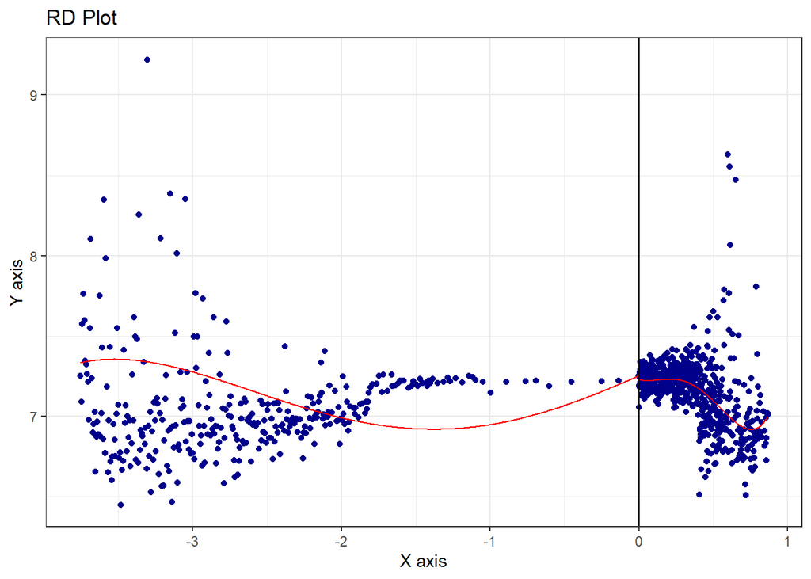

```r
rdrobust::rdplot(y = d_rdd_bivariate$ln_gross_expenditure_pc, x = d_rdd_bivariate$inhabs_rel_to_cutoff)
```

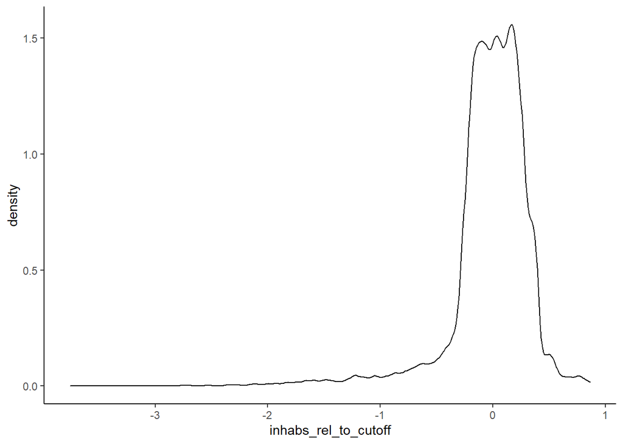

```r
ggplot(data = d_rdd_bivariate) +
  geom_density(aes(inhabs_rel_to_cutoff))
```

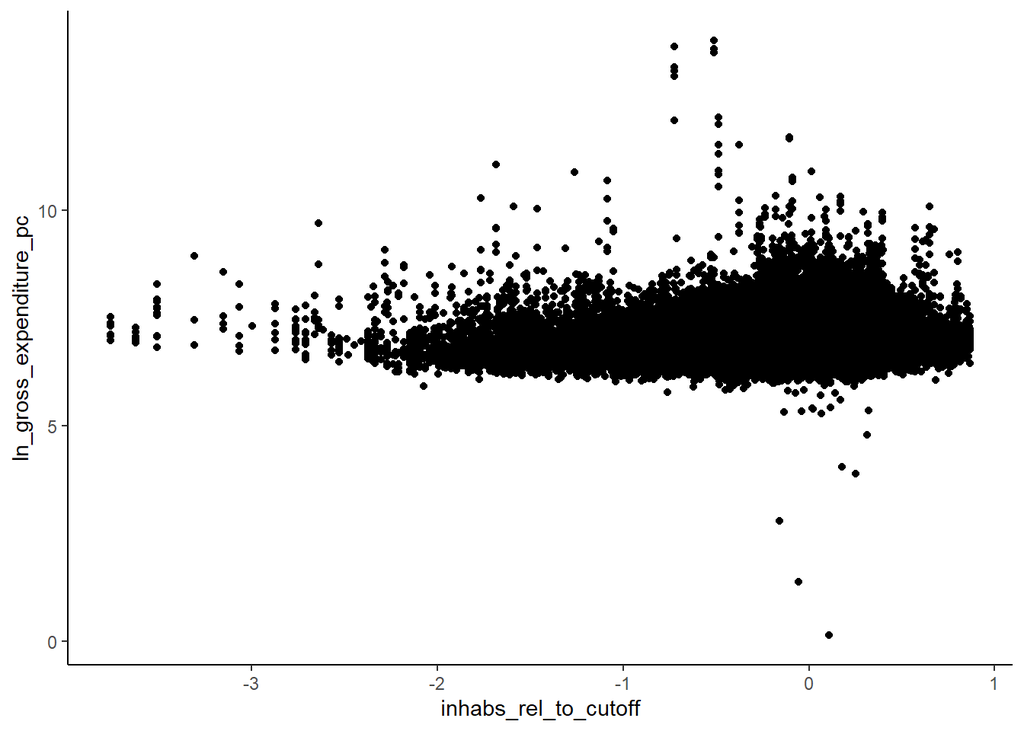

```r
ggplot(data = d_rdd_bivariate) +
  geom_point(aes(x = inhabs_rel_to_cutoff, y = ln_gross_expenditure_pc))
```

Plotting the estimated model from the previous section:

```
## [1] "Mass points detected in the running variable."
```

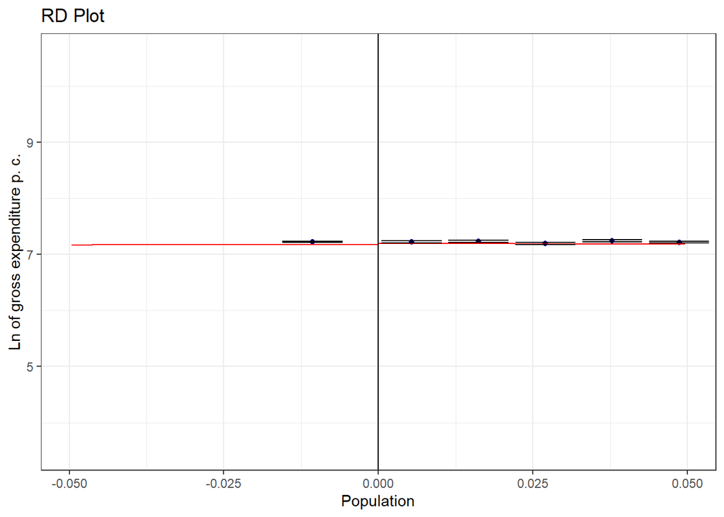

```r
#https://stackoverflow.com/questions/56884210/rdrobust-plotting-graphs-for-local-polynomial-estimation/57614447
rdplot <- rdrobust::rdplot(
  y = d_rdd$ln_gross_expenditure_pc,
  x = d_rdd$inhabs_rel_to_cutoff,
  binselect = "es",
  scale = 5,
  kernel = tolower(rdd_bi_fe$kernel),
  p = rdd_bi_fe$p,
  h = rdd_bi_fe$bws[1],
  covs = model.matrix( ~ d_rdd$inhabitants_treshold_factor + d_rdd$year + d_rdd$state + # FE
                         d_rdd$kreisfreie_stadt + d_rdd$stadt + d_rdd$years_since_last_elec) + # dummy controls
    d_rdd$inh_tot + d_rdd$pop_over65 + d_rdd$unempl_rate + # controls
    d_rdd$total_area_ha + d_rdd$share_working_age, # controls (cont.)
  x.lim = c(-rdd_bi_fe$bws[1], rdd_bi_fe$bws[1]),
  #title = "RD Plot - Senate Elections Data",
  x.label = "Population",
  y.label = "Ln of gross expenditure p. c.",
  ci = 95)
```

```r
rdplot
```

```
## Call: rdplot
##
## Number of Obs.               101409
## Kernel                   Triangular
##
## Number of Obs.                46711           54698
## Eff. Number of Obs.            7194            7825
## Order poly. fit (p)               1               1
## BW poly. fit (h)              0.050           0.050
## Number of bins scale          5.000           5.000
```

Manual plots:

`rdd_bi_fe` model: Jump at the cutoff (-0.0356103) somehow not equivalent to jump displayed in the output (e. g. in `summary()`: 0.0141869), especially given that the latter is *positive*…

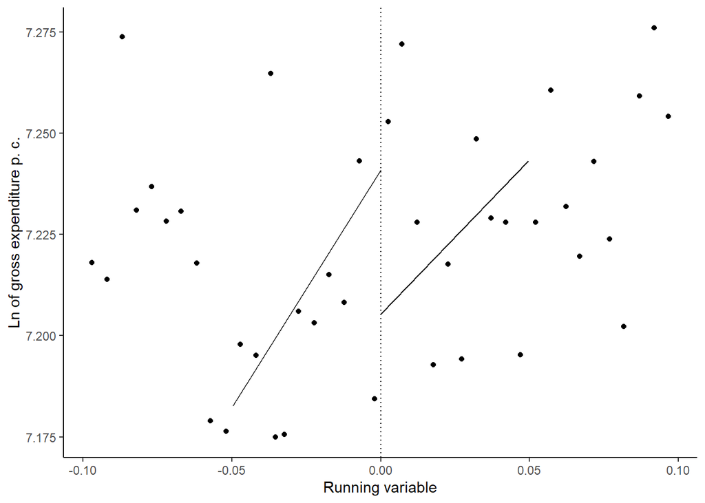

```r
# Following Huntington-Klein, https://theeffectbook.net/ch-RegressionDiscontinuity.html
d_rdd_bivariate %>%
  mutate(inhabs_bins = cut(
    inhabs_rel_to_cutoff,
    breaks = seq(
      -rdd_bi_fe$bws[1, 1]*2,
      rdd_bi_fe$bws[1, 2]*2,
      (rdd_bi_fe$bws[1, 1] + rdd_bi_fe$bws[1, 2]) / 20 # Must break at 0
    )
  )) %>%
    group_by(inhabs_bins) %>%
    summarize(ln_gross_expenditure_pc = mean(ln_gross_expenditure_pc),
              inhabs_mean = mean(inhabs_rel_to_cutoff)) %>%
  # "Taking the mean of running variable lets us plot data roughly at the bin midpoints"
  ggplot() +
  geom_point(aes(x = inhabs_mean, y = ln_gross_expenditure_pc)) +
  geom_vline(aes(xintercept = 0), linetype = "dotted") +
  geom_segment(aes(x = -rdd_bi_fe$bws[1, 1],
                   y = rdd_bi_fe$beta_p_l[1]+rdd_bi_fe$beta_p_l[2]*(-rdd_bi_fe$bws[1, 1]),
                   xend = 0, yend = rdd_bi_fe$beta_p_l[1])) +
  geom_segment(aes(x = 0,
                   yend = rdd_bi_fe$beta_p_r[1]+rdd_bi_fe$beta_p_r[2]*(rdd_bi_fe$bws[1, 1]),
                   xend = rdd_bi_fe$bws[1, 1],
                   y = rdd_bi_fe$beta_p_r[1])) +
  labs(x = "Running variable", y = "Ln of gross expenditure p. c.")
```

Hence, use `rdd_bi` model:

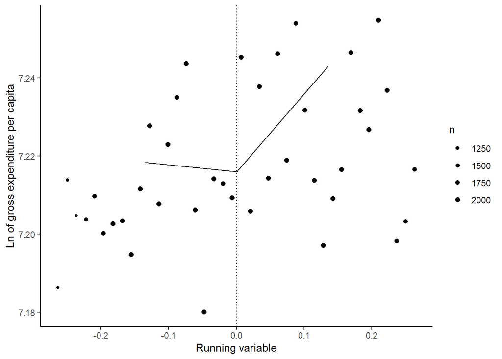

```r
binned <- d_rdd_bivariate %>%
  mutate(inhabs_bins = cut(
    inhabs_rel_to_cutoff,
    breaks = seq(
      -rdd_bi$bws[1, 1]*2,
      rdd_bi$bws[1, 2]*2,
      (rdd_bi$bws[1, 1] + rdd_bi$bws[1, 2]) / 20 # Must break at 0
    )
  )) %>%
    group_by(inhabs_bins) %>%
    summarize(ln_gross_expenditure_pc = mean(ln_gross_expenditure_pc),
              inhabs_mean = mean(inhabs_rel_to_cutoff),
              n = n()) %>%
  drop_na(inhabs_bins)
ggplot(data = binned) +
  geom_point(aes(x = inhabs_mean, y = ln_gross_expenditure_pc, size = n)) +
  scale_size_continuous(range = c(1, 2)) + # Reduced overall point size
  geom_vline(aes(xintercept = 0), linetype = "dotted") +
  geom_segment(aes(x = -rdd_bi$bws[1, 1],
                   y = rdd_bi$beta_p_l[1]+rdd_bi$beta_p_l[2]*(-rdd_bi$bws[1, 1]),
                   xend = 0, yend = rdd_bi$beta_p_l[1])) +
  geom_segment(aes(x = 0,
                   yend = rdd_bi$beta_p_r[1]+rdd_bi$beta_p_r[2]*(rdd_bi$bws[1, 1]),
                   xend = rdd_bi$bws[1, 1],
                   y = rdd_bi$beta_p_r[1])) +
  labs(x = "Running variable", y = "Ln of gross expenditure per capita")
```

```r
# to do in ggplot: add big mark to ggplot legend
summary(binned$n)
```

```
##    Min. 1st Qu.  Median    Mean 3rd Qu.    Max.
##    1040    1895    2060    1941    2142    2240
```

```r
sum(binned$n)
```

```
## [1] 77635
```

```r
#rm(binned)
ggsave(filename = "plots/rdd_plot.pdf", width = 6, height = 6*9/16)
```

## Robustness Checks

The RDD FE model without covariates will be regarded as the baseline model. Hence, write a wrapper function to ease the use of the model:

```r
rdrobust_fe_model <- function(cc = NULL, pp = NULL, qq = NULL, hh = NULL, bb = NULL, kkernel = "tri", bbwselect = "mserd", vvce = "nn") {
  rdrobust::rdrobust(
    y = d_rdd_bivariate$ln_gross_expenditure_pc,
    x = d_rdd_bivariate$inhabs_rel_to_cutoff,
    c = cc,
    fuzzy = d_rdd_bivariate$total_seats,
    cluster = d_rdd_bivariate$inhabitants_treshold_factor,
    covs = model.matrix( ~ d_rdd_bivariate$inhabitants_treshold_factor + d_rdd_bivariate$year + d_rdd_bivariate$state),
    # set parameters to run for robustness tests; set them to rdrobust defaults
    p = pp,
    q = qq,
    h = hh,
    b = bb,
    kernel = kkernel,
    bwselect = bbwselect,
    vce = vvce
  )
}
```

```r
rdd <- rdrobust_fe_model()
```

```
## [1] "Mass points detected in the running variable."
```

```r
summary(rdd) # equal to rdd_bi_fe model
```

```
## Covariate-adjusted Fuzzy RD estimates using local polynomial regression.
##
## Number of Obs.               103618
## BW type                       mserd
## Kernel                   Triangular
## VCE method                       NN
##
## Number of Obs.                48578        55040
## Eff. Number of Obs.            7238         7893
## Order est. (p)                    1            1
## Order bias  (q)                   2            2
## BW est. (h)                   0.050        0.050
## BW bias (b)                   0.157        0.157
## rho (h/b)                     0.317        0.317
## Unique Obs.                    3715         4582
##
## First-stage estimates.
##
## =============================================================================
##         Method     Coef. Std. Err.         z     P>|z|      [ 95% C.I. ]
## =============================================================================
##   Conventional     1.242     0.120    10.351     0.000     [1.007 , 1.477]
##         Robust         -         -     9.706     0.000     [0.952 , 1.434]
## =============================================================================
##
## Treatment effect estimates.
##
## =============================================================================
##         Method     Coef. Std. Err.         z     P>|z|      [ 95% C.I. ]
## =============================================================================
##   Conventional     0.014     0.012     1.173     0.241    [-0.010 , 0.038]
##         Robust         -         -     1.222     0.222    [-0.009 , 0.040]
## =============================================================================
```

### Different RDD specifications

Vary p, the local polynomial. Conclusions remain. On the first stage, council size jumps by a value somewhat larger than 1 at the threshold (highly statistically significant). The second stage, however, remains insignificant, with some p values around 0.2, the others are (in part way) larger. The coefficient is always slightly positive.

```r
rdd_vary_p_df <-
  tibble(polynomial = "", point_estimate = "", se = "", se_robust = "",
         ci_lower = "", ci_upper = "", p = "", bw = "", obs_below = "", obs_above = "") %>%
  mutate(across(everything(), as.numeric))
for (vary_p in 0:6) {
  print(paste("polynomial of degree", vary_p))
  rdd <- rdrobust_fe_model(pp = vary_p)
  summary(rdd)
  rdd_vary_p_df <- rdd_vary_p_df %>%
    dplyr::add_row(
      polynomial = vary_p,
      point_estimate = rdd$coef[1],
      se = rdd$se[1],
      se_robust = rdd$se[3],
      ci_lower = rdd$ci[3,1],
      ci_upper = rdd$ci[3,2],
      p = rdd$pv[3],
      bw = rdd$bws[1,1],
      obs_below = rdd$N_h[1],
      obs_above = rdd$N_h[2]
  )
}
```

```
## [1] "polynomial of degree 0"
## [1] "Mass points detected in the running variable."
## Covariate-adjusted Fuzzy RD estimates using local polynomial regression.
##
## Number of Obs.               103618
## BW type                       mserd
## Kernel                   Triangular
## VCE method                       NN
##
## Number of Obs.                48578        55040
## Eff. Number of Obs.            3006         3352
## Order est. (p)                    0            0
## Order bias  (q)                   1            1
## BW est. (h)                   0.020        0.020
## BW bias (b)                   0.209        0.209
## rho (h/b)                     0.098        0.098
## Unique Obs.                    3715         4582
##
## First-stage estimates.
##
## =============================================================================
##         Method     Coef. Std. Err.         z     P>|z|      [ 95% C.I. ]
## =============================================================================
##   Conventional     1.517     0.087    17.487     0.000     [1.347 , 1.687]
##         Robust         -         -    16.303     0.000     [1.285 , 1.636]
## =============================================================================
##
## Treatment effect estimates.
##
## =============================================================================
##         Method     Coef. Std. Err.         z     P>|z|      [ 95% C.I. ]
## =============================================================================
##   Conventional     0.009     0.006     1.451     0.147    [-0.003 , 0.020]
##         Robust         -         -     1.447     0.148    [-0.003 , 0.020]
## =============================================================================
## [1] "polynomial of degree 1"
## [1] "Mass points detected in the running variable."
## Covariate-adjusted Fuzzy RD estimates using local polynomial regression.
##
## Number of Obs.               103618
```

[output cut: 190 more lines]

```
## =============================================================================
##         Method     Coef. Std. Err.         z     P>|z|      [ 95% C.I. ]
## =============================================================================
##   Conventional     1.054     0.152     6.929     0.000     [0.756 , 1.353]
##         Robust         -         -     6.427     0.000     [0.712 , 1.338]
## =============================================================================
##
## Treatment effect estimates.
##
## =============================================================================
##         Method     Coef. Std. Err.         z     P>|z|      [ 95% C.I. ]
## =============================================================================
##   Conventional     0.005     0.024     0.213     0.832    [-0.041 , 0.051]
##         Robust         -         -     0.024     0.981    [-0.047 , 0.048]
## =============================================================================
```

```r
rdd_vary_p_df <- rdd_vary_p_df %>% drop_na()
save(rdd_vary_p_df, file = "tables_robustness_checks/rdd_vary_p_df.Rdata")
```

```r
load(file = "tables_robustness_checks/rdd_vary_p_df.Rdata")
rdd_vary_p_df
```

| polynomial | point_estimate | se | se_robust | ci_lower | ci_upper | p | bw | obs_below | obs_above |
| --- | --- | --- | --- | --- | --- | --- | --- | --- | --- |
| 0 | 0.008578567 | 0.005911555 | 0.005987911 | -0.003071140 | 0.02040104 | 0.1478762 | 0.02040290 | 3006 | 3352 |
| 1 | 0.014186948 | 0.012094393 | 0.012597460 | -0.009297968 | 0.04008317 | 0.2217526 | 0.04964999 | 7238 | 7893 |
| 2 | 0.016863082 | 0.014977654 | 0.015522257 | -0.012197754 | 0.04864838 | 0.2403387 | 0.11257529 | 16967 | 17434 |
| 3 | 0.014679327 | 0.016991905 | 0.017901553 | -0.020929992 | 0.04924281 | 0.4290653 | 0.16628007 | 25135 | 25977 |
| 4 | 0.008213766 | 0.019701561 | 0.020815103 | -0.034440178 | 0.04715353 | 0.7600710 | 0.21259635 | 31566 | 33353 |
| 5 | 0.009690794 | 0.020919198 | 0.021971615 | -0.035082887 | 0.05104426 | 0.7164352 | 0.29387603 | 38055 | 43603 |
| 6 | 0.005029841 | 0.023643856 | 0.024053349 | -0.046574900 | 0.04771250 | 0.9811339 | 0.35251727 | 39626 | 47971 |

Vary q, the “local-polynomial used to construct the bias correction”. Conclusions similar to varying p: Highly significant first stage across all `q`s, non-significant second stage (p values as low as 0.2) and positive around 1%.

```r
rdd_vary_q_df <-
  tibble(polynomial = "", point_estimate = "", se = "", se_robust = "",
         ci_lower = "", ci_upper = "", p = "", bw = "", obs_below = "", obs_above = "") %>%
  mutate(across(everything(), as.numeric))
for (vary_q in 2:6) {
  print(paste("polynomial of degree", vary_q))
  rdd <- rdrobust_fe_model(qq = vary_q)
  summary(rdd)
  rdd_vary_q_df <- rdd_vary_q_df %>%
    dplyr::add_row(
      polynomial = vary_q,
      point_estimate = rdd$coef[1],
      se = rdd$se[1],
      se_robust = rdd$se[3],
      ci_lower = rdd$ci[3,1],
      ci_upper = rdd$ci[3,2],
      p = rdd$pv[3],
      bw = rdd$bws[1,1],
      obs_below = rdd$N_h[1],
      obs_above = rdd$N_h[2]
  )
}
```

```
## [1] "polynomial of degree 2"
## [1] "Mass points detected in the running variable."
## Covariate-adjusted Fuzzy RD estimates using local polynomial regression.
##
## Number of Obs.               103618
## BW type                       mserd
## Kernel                   Triangular
## VCE method                       NN
##
## Number of Obs.                48578        55040
## Eff. Number of Obs.            7238         7893
## Order est. (p)                    1            1
## Order bias  (q)                   2            2
## BW est. (h)                   0.050        0.050
## BW bias (b)                   0.157        0.157
## rho (h/b)                     0.317        0.317
## Unique Obs.                    3715         4582
##
## First-stage estimates.
##
## =============================================================================
##         Method     Coef. Std. Err.         z     P>|z|      [ 95% C.I. ]
## =============================================================================
##   Conventional     1.242     0.120    10.351     0.000     [1.007 , 1.477]
##         Robust         -         -     9.706     0.000     [0.952 , 1.434]
## =============================================================================
##
## Treatment effect estimates.
##
## =============================================================================
##         Method     Coef. Std. Err.         z     P>|z|      [ 95% C.I. ]
## =============================================================================
##   Conventional     0.014     0.012     1.173     0.241    [-0.010 , 0.038]
##         Robust         -         -     1.222     0.222    [-0.009 , 0.040]
## =============================================================================
## [1] "polynomial of degree 3"
## [1] "Mass points detected in the running variable."
## Covariate-adjusted Fuzzy RD estimates using local polynomial regression.
##
## Number of Obs.               103618
```

[output cut: 120 more lines]

```
## =============================================================================
##         Method     Coef. Std. Err.         z     P>|z|      [ 95% C.I. ]
## =============================================================================
##   Conventional     1.141     0.132     8.645     0.000     [0.882 , 1.399]
##         Robust         -         -     7.580     0.000     [0.768 , 1.304]
## =============================================================================
##
## Treatment effect estimates.
##
## =============================================================================
##         Method     Coef. Std. Err.         z     P>|z|      [ 95% C.I. ]
## =============================================================================
##   Conventional     0.007     0.012     0.644     0.520    [-0.015 , 0.030]
##         Robust         -         -     0.810     0.418    [-0.014 , 0.034]
## =============================================================================
```

```r
rdd_vary_q_df <- rdd_vary_q_df %>% drop_na()
save(rdd_vary_q_df, file = "tables_robustness_checks/rdd_vary_q_df.Rdata")
```

```r
load(file = "tables_robustness_checks/rdd_vary_q_df.Rdata")
rdd_vary_q_df
```

| polynomial | point_estimate | se | se_robust | ci_lower | ci_upper | p | bw | obs_below | obs_above |
| --- | --- | --- | --- | --- | --- | --- | --- | --- | --- |
| 2 | 0.014186948 | 0.01209439 | 0.01259746 | -0.009297968 | 0.04008317 | 0.2217526 | 0.04964999 | 7238 | 7893 |
| 3 | 0.010970095 | 0.01211663 | 0.01260730 | -0.011641020 | 0.03777869 | 0.2999183 | 0.04345139 | 6275 | 7012 |
| 4 | 0.007549167 | 0.01139113 | 0.01224226 | -0.015737851 | 0.03225092 | 0.5000386 | 0.03083136 | 4435 | 4926 |
| 5 | 0.009171159 | 0.01143257 | 0.01240320 | -0.015641756 | 0.03297789 | 0.4846411 | 0.02690373 | 3761 | 4357 |
| 6 | 0.007450925 | 0.01157430 | 0.01209633 | -0.013909734 | 0.03350700 | 0.4179114 | 0.03282747 | 4768 | 5265 |

Vary kernel: No large differences between kernels.

```r
rdd_vary_kernel_df <-
  tibble(kernel = "", point_estimate = "", se = "", se_robust = "",
         ci_lower = "", ci_upper = "", p = "", bw = "", obs_below = "", obs_above = "") %>%
  mutate(across(2:last_col(), as.numeric))
for (vary_kernel in c("tri", "epa", "uni")) {
  print(paste("kernel:", vary_kernel))
  rdd <- rdrobust_fe_model(kkernel = vary_kernel)
  summary(rdd)
  rdd_vary_kernel_df <- rdd_vary_kernel_df %>%
    dplyr::add_row(
      kernel = vary_kernel,
      point_estimate = rdd$coef[1],
      se = rdd$se[1],
      se_robust = rdd$se[3],
      ci_lower = rdd$ci[3,1],
      ci_upper = rdd$ci[3,2],
      p = rdd$pv[3],
      bw = rdd$bws[1,1],
      obs_below = rdd$N_h[1],
      obs_above = rdd$N_h[2]
  )
}
```

```
## [1] "kernel: tri"
## [1] "Mass points detected in the running variable."
## Covariate-adjusted Fuzzy RD estimates using local polynomial regression.
##
## Number of Obs.               103618
## BW type                       mserd
## Kernel                   Triangular
## VCE method                       NN
##
## Number of Obs.                48578        55040
## Eff. Number of Obs.            7238         7893
## Order est. (p)                    1            1
## Order bias  (q)                   2            2
## BW est. (h)                   0.050        0.050
## BW bias (b)                   0.157        0.157
## rho (h/b)                     0.317        0.317
## Unique Obs.                    3715         4582
##
## First-stage estimates.
##
## =============================================================================
##         Method     Coef. Std. Err.         z     P>|z|      [ 95% C.I. ]
## =============================================================================
##   Conventional     1.242     0.120    10.351     0.000     [1.007 , 1.477]
##         Robust         -         -     9.706     0.000     [0.952 , 1.434]
## =============================================================================
##
## Treatment effect estimates.
##
## =============================================================================
##         Method     Coef. Std. Err.         z     P>|z|      [ 95% C.I. ]
## =============================================================================
##   Conventional     0.014     0.012     1.173     0.241    [-0.010 , 0.038]
##         Robust         -         -     1.222     0.222    [-0.009 , 0.040]
## =============================================================================
## [1] "kernel: epa"
## [1] "Mass points detected in the running variable."
## Covariate-adjusted Fuzzy RD estimates using local polynomial regression.
##
## Number of Obs.               103618
```

[output cut: 50 more lines]

```
## =============================================================================
##         Method     Coef. Std. Err.         z     P>|z|      [ 95% C.I. ]
## =============================================================================
##   Conventional     1.190     0.158     7.518     0.000     [0.880 , 1.501]
##         Robust         -         -     7.035     0.000     [0.802 , 1.422]
## =============================================================================
##
## Treatment effect estimates.
##
## =============================================================================
##         Method     Coef. Std. Err.         z     P>|z|      [ 95% C.I. ]
## =============================================================================
##   Conventional     0.008     0.014     0.598     0.550    [-0.019 , 0.036]
##         Robust         -         -     0.638     0.523    [-0.019 , 0.038]
## =============================================================================
```

```r
rdd_vary_kernel_df <- rdd_vary_kernel_df %>% drop_na()
save(rdd_vary_kernel_df, file = "tables_robustness_checks/rdd_vary_kernel_df.Rdata")
```

```r
load(file = "tables_robustness_checks/rdd_vary_kernel_df.Rdata")
rdd_vary_kernel_df
```

| kernel | point_estimate | se | se_robust | ci_lower | ci_upper | p | bw | obs_below | obs_above |
| --- | --- | --- | --- | --- | --- | --- | --- | --- | --- |
| tri | 0.014186948 | 0.01209439 | 0.01259746 | -0.009297968 | 0.04008317 | 0.2217526 | 0.04964999 | 7238 | 7893 |
| epa | 0.012245728 | 0.01285705 | 0.01340800 | -0.013059248 | 0.03949916 | 0.3241454 | 0.04360828 | 6336 | 7012 |
| uni | 0.008333097 | 0.01393113 | 0.01466301 | -0.019382341 | 0.03809560 | 0.5234014 | 0.03242632 | 4645 | 5197 |

Vary variance-covariance matrix: The `hc` vce appear extremely similar. Conclusions, however, are not altered.

```r
rdd_vary_vcov_df <-
  tibble(vcov = "", point_estimate = "", se = "", se_robust = "",
         ci_lower = "", ci_upper = "", p = "", bw = "", obs_below = "", obs_above = "") %>%
  mutate(across(2:last_col(), as.numeric))
for (vary_vcov in c("nn", "hc0", "hc1", "hc2", "hc3")) {
  print(paste("vce:", vary_vcov))
  rdd <- rdrobust_fe_model(vvce = vary_vcov)
  summary(rdd)
  rdd_vary_vcov_df <- rdd_vary_vcov_df %>%
    dplyr::add_row(
      vcov = vary_vcov,
      point_estimate = rdd$coef[1],
      se = rdd$se[1],
      se_robust = rdd$se[3],
      ci_lower = rdd$ci[3,1],
      ci_upper = rdd$ci[3,2],
      p = rdd$pv[3],
      bw = rdd$bws[1,1],
      obs_below = rdd$N_h[1],
      obs_above = rdd$N_h[2]
  )
}
```

```
## [1] "vce: nn"
## [1] "Mass points detected in the running variable."
## Covariate-adjusted Fuzzy RD estimates using local polynomial regression.
##
## Number of Obs.               103618
## BW type                       mserd
## Kernel                   Triangular
## VCE method                       NN
##
## Number of Obs.                48578        55040
## Eff. Number of Obs.            7238         7893
## Order est. (p)                    1            1
## Order bias  (q)                   2            2
## BW est. (h)                   0.050        0.050
## BW bias (b)                   0.157        0.157
## rho (h/b)                     0.317        0.317
## Unique Obs.                    3715         4582
##
## First-stage estimates.
##
## =============================================================================
##         Method     Coef. Std. Err.         z     P>|z|      [ 95% C.I. ]
## =============================================================================
##   Conventional     1.242     0.120    10.351     0.000     [1.007 , 1.477]
##         Robust         -         -     9.706     0.000     [0.952 , 1.434]
## =============================================================================
##
## Treatment effect estimates.
##
## =============================================================================
##         Method     Coef. Std. Err.         z     P>|z|      [ 95% C.I. ]
## =============================================================================
##   Conventional     0.014     0.012     1.173     0.241    [-0.010 , 0.038]
##         Robust         -         -     1.222     0.222    [-0.009 , 0.040]
## =============================================================================
## [1] "vce: hc0"
## [1] "Mass points detected in the running variable."
## Covariate-adjusted Fuzzy RD estimates using local polynomial regression.
##
## Number of Obs.               103618
```

[output cut: 120 more lines]

```
## =============================================================================
##         Method     Coef. Std. Err.         z     P>|z|      [ 95% C.I. ]
## =============================================================================
##   Conventional     1.315     0.116    11.345     0.000     [1.088 , 1.543]
##         Robust         -         -     9.904     0.000     [0.997 , 1.489]
## =============================================================================
##
## Treatment effect estimates.
##
## =============================================================================
##         Method     Coef. Std. Err.         z     P>|z|      [ 95% C.I. ]
## =============================================================================
##   Conventional     0.014     0.010     1.376     0.169    [-0.006 , 0.034]
##         Robust         -         -     1.436     0.151    [-0.006 , 0.037]
## =============================================================================
```

```r
rdd_vary_vcov_df <- rdd_vary_vcov_df %>% drop_na()
save(rdd_vary_vcov_df, file = "tables_robustness_checks/rdd_vary_vcov_df.Rdata")
```

```r
load(file = "tables_robustness_checks/rdd_vary_vcov_df.Rdata")
rdd_vary_vcov_df
```

| vcov | point_estimate | se | se_robust | ci_lower | ci_upper | p | bw | obs_below | obs_above |
| --- | --- | --- | --- | --- | --- | --- | --- | --- | --- |
| nn | 0.01418695 | 0.01209439 | 0.01259746 | -0.009297968 | 0.04008317 | 0.2217526 | 0.04964999 | 7238 | 7893 |
| hc0 | 0.01404437 | 0.01020770 | 0.01101410 | -0.005766003 | 0.03740849 | 0.1508734 | 0.06122804 | 9033 | 9673 |
| hc1 | 0.01404449 | 0.01020782 | 0.01101447 | -0.005766367 | 0.03740957 | 0.1508779 | 0.06123042 | 9033 | 9673 |
| hc2 | 0.01404461 | 0.01020911 | 0.01101562 | -0.005768305 | 0.03741212 | 0.1509124 | 0.06123277 | 9033 | 9673 |
| hc3 | 0.01404485 | 0.01021051 | 0.01101713 | -0.005770603 | 0.03741576 | 0.1509513 | 0.06123749 | 9034 | 9674 |

### Sensitivity analysis

#### Ad-hoc chosen bandwidths

```r
rdd_vary_h_df <-
  tibble(h = "", point_estimate = "", se = "", se_robust = "",
         ci_lower = "", ci_upper = "", p = "", bw = "", obs_below = "", obs_above = "") %>%
  mutate(across(everything(), as.numeric))
for (vary_h in seq(0.02, 0.2, 0.03)) {
  print(paste("h = ", vary_h))
  rdd <- rdrobust_fe_model(hh = vary_h)
  summary(rdd)
  rdd_vary_h_df <- rdd_vary_h_df %>%
    dplyr::add_row(
      h = vary_h,
      point_estimate = rdd$coef[1],
      se = rdd$se[1],
      se_robust = rdd$se[3],
      ci_lower = rdd$ci[3,1],
      ci_upper = rdd$ci[3,2],
      p = rdd$pv[3],
      bw = rdd$bws[1,1],
      obs_below = rdd$N_h[1],
      obs_above = rdd$N_h[2]
  )
}
```

```
## [1] "h =  0.02"
## Covariate-adjusted Fuzzy RD estimates using local polynomial regression.
##
## Number of Obs.               103618
## BW type                      Manual
## Kernel                   Triangular
## VCE method                       NN
##
## Number of Obs.                48578        55040
## Eff. Number of Obs.            2904         3310
## Order est. (p)                    1            1
## Order bias  (q)                   2            2
## BW est. (h)                   0.020        0.020
## BW bias (b)                   0.020        0.020
## rho (h/b)                     1.000        1.000
## Unique Obs.                   48578        55040
##
## First-stage estimates.
##
## =============================================================================
##         Method     Coef. Std. Err.         z     P>|z|      [ 95% C.I. ]
## =============================================================================
##   Conventional     1.053     0.167     6.318     0.000     [0.726 , 1.379]
##         Robust         -         -     4.118     0.000     [0.584 , 1.643]
## =============================================================================
##
## Treatment effect estimates.
##
## =============================================================================
##         Method     Coef. Std. Err.         z     P>|z|      [ 95% C.I. ]
## =============================================================================
##   Conventional     0.010     0.012     0.824     0.410    [-0.014 , 0.035]
##         Robust         -         -    -0.547     0.584    [-0.042 , 0.024]
## =============================================================================
## [1] "h =  0.05"
## Covariate-adjusted Fuzzy RD estimates using local polynomial regression.
##
## Number of Obs.               103618
## BW type                      Manual
## Kernel                   Triangular
```

[output cut: 183 more lines]

```
## =============================================================================
##         Method     Coef. Std. Err.         z     P>|z|      [ 95% C.I. ]
## =============================================================================
##   Conventional     2.084     0.083    25.203     0.000     [1.922 , 2.246]
##         Robust         -         -    16.797     0.000     [1.352 , 1.710]
## =============================================================================
##
## Treatment effect estimates.
##
## =============================================================================
##         Method     Coef. Std. Err.         z     P>|z|      [ 95% C.I. ]
## =============================================================================
##   Conventional     0.006     0.003     1.648     0.099    [-0.001 , 0.012]
##         Robust         -         -     2.643     0.008     [0.004 , 0.026]
## =============================================================================
```

```r
rdd_vary_h_df <- rdd_vary_h_df %>% drop_na()
save(rdd_vary_h_df, file = "tables_robustness_checks/rdd_vary_h_df.Rdata")
```

```r
load(file = "tables_robustness_checks/rdd_vary_h_df.Rdata")
rdd_vary_h_df
```

| h | point_estimate | se | se_robust | ci_lower | ci_upper | p | bw | obs_below | obs_above |
| --- | --- | --- | --- | --- | --- | --- | --- | --- | --- |
| 0.02 | 0.010223784 | 0.012401369 | 0.016727212 | -0.0419372488 | 0.02363222 | 0.584266588 | 0.02 | 2904 | 3310 |
| 0.05 | 0.014362141 | 0.012095211 | 0.013233060 | -0.0200278392 | 0.03184480 | 0.655240476 | 0.05 | 7280 | 7946 |
| 0.08 | 0.015223342 | 0.009096103 | 0.013027194 | -0.0140489478 | 0.03701671 | 0.378030167 | 0.08 | 11943 | 12605 |
| 0.11 | 0.014417870 | 0.005957846 | 0.010891666 | -0.0055427371 | 0.03715181 | 0.146761230 | 0.11 | 16598 | 17124 |
| 0.14 | 0.011731887 | 0.004518453 | 0.008188211 | 0.0006664554 | 0.03276365 | 0.041215449 | 0.14 | 21116 | 21711 |
| 0.17 | 0.008438813 | 0.003853526 | 0.006661514 | 0.0039318780 | 0.03004453 | 0.010766057 | 0.17 | 25753 | 26537 |
| 0.20 | 0.005609712 | 0.003403995 | 0.005698304 | 0.0038914058 | 0.02622835 | 0.008220662 | 0.20 | 29878 | 31448 |

Apparently, the bandwidth `b` cannot be set manually. Perhaps change `rho` parameter or set `b` manually and `b` via the `bwselect()` function.

```r
for (vary_b in seq(0.15, 0.45, 0.075)) {
  print(paste("RDD with bandwidth b =", vary_b))
  rdd <- rdrobust_fe_model(bb = vary_b)
  summary(rdd)
}
```

```r
rdd_vary_window <-
  tibble(window = "", point_estimate = "", se = "", se_robust = "",
         ci_lower = "", ci_upper = "", p = "", bw = "", obs_below = "", obs_above = "") %>%
  mutate(across(everything(), as.numeric))
for (vary_window in seq(0.01, 0.25, 0.01)) {
  print(paste("RDD with window: ", vary_window))
  df <- d_rdd_bivariate %>%
    filter(closest <= vary_window)
  str(vary_window)
  rdd <-
    rdrobust::rdrobust(
      y = df$ln_gross_expenditure_pc,
      x = df$inhabs_rel_to_cutoff,
      fuzzy = df$total_seats,
      cluster = df$inhabitants_treshold_factor,
      covs = model.matrix( ~ df$inhabitants_treshold_factor + df$year + df$state),
      h = 10 # 10 is larger than any absolute value of the running variable => use all observations
  )
  summary(rdd)
  rdd_vary_window <- rdd_vary_window %>%
    dplyr::add_row(
      window = vary_window,
      point_estimate = rdd$coef[1],
      se = rdd$se[1],
      se_robust = rdd$se[3],
      ci_lower = rdd$ci[3,1],
      ci_upper = rdd$ci[3,2],
      p = rdd$pv[3],
      bw = rdd$bws[1,1],
      obs_below = rdd$N_h[1],
      obs_above = rdd$N_h[2]
  )
}
```

```
## [1] "RDD with window:  0.01"
##  num 0.01
## Covariate-adjusted Fuzzy RD estimates using local polynomial regression.
##
## Number of Obs.                 1036
## BW type                      Manual
## Kernel                   Triangular
## VCE method                       NN
##
## Number of Obs.                  440          596
## Eff. Number of Obs.             440          596
## Order est. (p)                    1            1
## Order bias  (q)                   2            2
## BW est. (h)                  10.000       10.000
## BW bias (b)                  10.000       10.000
## rho (h/b)                     1.000        1.000
## Unique Obs.                     440          596
##
## First-stage estimates.
##
## =============================================================================
##         Method     Coef. Std. Err.         z     P>|z|      [ 95% C.I. ]
## =============================================================================
##   Conventional     1.984     0.329     6.034     0.000     [1.340 , 2.629]
##         Robust         -         -     5.794     0.000     [2.016 , 4.077]
## =============================================================================
##
## Treatment effect estimates.
##
## =============================================================================
##         Method     Coef. Std. Err.         z     P>|z|      [ 95% C.I. ]
## =============================================================================
##   Conventional    -0.060     0.019    -3.155     0.002    [-0.097 , -0.023]
##         Robust         -         -    -1.856     0.064    [-0.089 , 0.002]
## =============================================================================
## [1] "RDD with window:  0.02"
##  num 0.02
## Covariate-adjusted Fuzzy RD estimates using local polynomial regression.
##
## Number of Obs.                 2072
```

[output cut: 820 more lines]

```
## =============================================================================
##         Method     Coef. Std. Err.         z     P>|z|      [ 95% C.I. ]
## =============================================================================
##   Conventional     1.650     0.081    20.485     0.000     [1.492 , 1.808]
##         Robust         -         -    10.035     0.000     [0.941 , 1.398]
## =============================================================================
##
## Treatment effect estimates.
##
## =============================================================================
##         Method     Coef. Std. Err.         z     P>|z|      [ 95% C.I. ]
## =============================================================================
##   Conventional     0.019     0.007     2.624     0.009     [0.005 , 0.032]
##         Robust         -         -     0.943     0.346    [-0.012 , 0.035]
## =============================================================================
```

```r
rdd_vary_window <- rdd_vary_window %>% drop_na()
save(rdd_vary_window, file = "tables_robustness_checks/rdd_vary_window.Rdata")
```

```r
load(file = "tables_robustness_checks/rdd_vary_window.Rdata")
rdd_vary_window
```

| window | point_estimate | se | se_robust | ci_lower | ci_upper | p | bw | obs_below | obs_above |
| --- | --- | --- | --- | --- | --- | --- | --- | --- | --- |
| 0.01 | -0.060010158 | 0.019020844 | 0.02320719 | -0.088550057 | 0.002420455 | 0.06350113 | 10 | 440 | 596 |
| 0.02 | -0.033704089 | 0.018131845 | 0.03428197 | -0.142056680 | -0.007673846 | 0.02897629 | 10 | 912 | 1160 |
| 0.03 | 0.004451564 | 0.017152109 | 0.02346806 | -0.095952648 | -0.003959544 | 0.03328037 | 10 | 1398 | 1710 |
| 0.04 | 0.028628940 | 0.016068569 | 0.02563390 | -0.096490094 | 0.003992942 | 0.07120059 | 10 | 1882 | 2262 |
| 0.05 | 0.019127847 | 0.017893502 | 0.02078489 | -0.035997085 | 0.045478199 | 0.81958634 | 10 | 2438 | 2742 |
| 0.06 | 0.015366794 | 0.013100968 | 0.01721781 | -0.020742966 | 0.046749628 | 0.45011377 | 10 | 2904 | 3313 |
| 0.07 | 0.011792239 | 0.011805465 | 0.01535489 | -0.016337565 | 0.043852503 | 0.37027064 | 10 | 3371 | 3882 |
| 0.08 | 0.004883421 | 0.012397873 | 0.01339727 | -0.006176597 | 0.046339755 | 0.13389176 | 10 | 3887 | 4402 |
| 0.09 | 0.008176889 | 0.013251670 | 0.01359896 | -0.013169525 | 0.040137412 | 0.32142082 | 10 | 4415 | 4910 |
| 0.10 | 0.001827890 | 0.014745775 | 0.01439091 | -0.007673900 | 0.048737421 | 0.15366132 | 10 | 4931 | 5430 |

[output cut: 15 more lines]

Plot windows. Coefficients and CIs need not overlap because standard coefficients are paired with robust-corrected CIs.

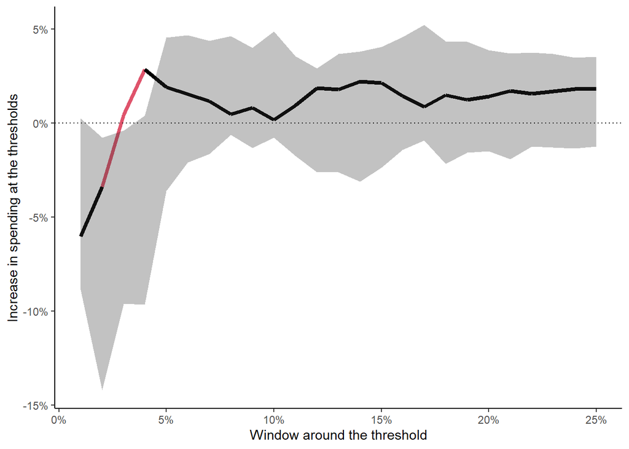

```r
ggplot2::ggplot(data = rdd_vary_window, aes(x = window, y = point_estimate)) +
  geom_line(size = 1.5, color = ifelse(rdd_vary_window$p <= 0.05, 2, 1)) +
  geom_ribbon(aes(ymin = ci_lower, ymax = ci_upper), alpha = 0.3) +
  geom_hline(aes(yintercept = 0), linetype = "dotted") +
  scale_x_continuous(labels = scales::percent) +
  scale_y_continuous(labels = scales::percent) +
  labs(x = "Window around the threshold", y = y_lab_RDD)
```

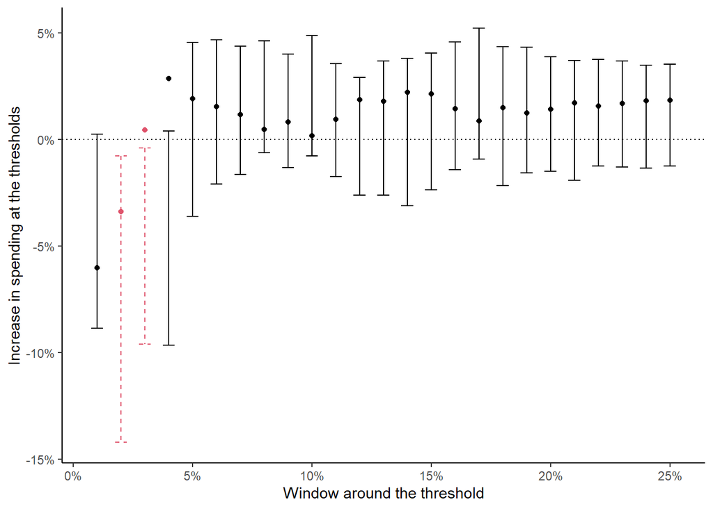

```r
ggplot2::ggplot(data = rdd_vary_window, aes(x = window, y = point_estimate)) +
  geom_point(size = 1.5, color = ifelse(rdd_vary_window$p <= 0.05, 2, 1)) +
  geom_errorbar(aes(ymin = ci_lower, ymax = ci_upper),
                color = ifelse(rdd_vary_window$p <= 0.05, 2, 1),
                linetype = ifelse(rdd_vary_window$p <= 0.05, 2, 1),
                width = 0.005) +
  geom_hline(aes(yintercept = 0), linetype = "dotted") +
  scale_x_continuous(labels = scales::percent) +
  scale_y_continuous(labels = scales::percent) +
  labs(x = "Window around the threshold", y = y_lab_RDD)
```

```r
ggsave(filename = "plots/rdrobust_bw_window.pdf", width = 6, height = 6*9/16)
```

#### `rdbwselect` automatic bandwidth selection procedures

Different `rdbwselect` options: Most bandwidth selection algorithms yield similar results to the default one. One or two, however, gain statistical significance for the regressor of interest by virtue of a larger bandwidth.

```r
rdd_vary_bwselect <-
  tibble(bw_sel_algo = "", point_estimate = "", se = "", se_robust = "",
         ci_lower = "", ci_upper = "", p = "", bw = "", obs_below = "", obs_above = "") %>%
  mutate(across(2:last_col(), as.numeric))
for (vary_bwselect in c("mserd", "msetwo", "msesum", "msecomb1", "msecomb2", "cerrd", "certwo", "cersum", "cercomb1", "cercomb2")) {
  print(paste("Bandwidth selection algorithm:", vary_bwselect))
  rdd <- rdrobust_fe_model(bbwselect = vary_bwselect)
  #summary(rdd)
  rdd_vary_bwselect <- rdd_vary_bwselect %>%
    dplyr::add_row(
      bw_sel_algo = vary_bwselect,
      point_estimate = rdd$coef[1],
      se = rdd$se[1],
      se_robust = rdd$se[3],
      ci_lower = rdd$ci[3,1],
      ci_upper = rdd$ci[3,2],
      p = rdd$pv[3],
      bw = rdd$bws[1,1],
      obs_below = rdd$N_h[1],
      obs_above = rdd$N_h[2]
  )
}
```

```
## [1] "Bandwidth selection algorithm: mserd"
## [1] "Mass points detected in the running variable."
## [1] "Bandwidth selection algorithm: msetwo"
## [1] "Mass points detected in the running variable."
## [1] "Bandwidth selection algorithm: msesum"
## [1] "Mass points detected in the running variable."
## [1] "Bandwidth selection algorithm: msecomb1"
## [1] "Mass points detected in the running variable."
## [1] "Bandwidth selection algorithm: msecomb2"
## [1] "Mass points detected in the running variable."
## [1] "Bandwidth selection algorithm: cerrd"
## [1] "Mass points detected in the running variable."
## [1] "Bandwidth selection algorithm: certwo"
## [1] "Mass points detected in the running variable."
## [1] "Bandwidth selection algorithm: cersum"
## [1] "Mass points detected in the running variable."
## [1] "Bandwidth selection algorithm: cercomb1"
## [1] "Mass points detected in the running variable."
## [1] "Bandwidth selection algorithm: cercomb2"
## [1] "Mass points detected in the running variable."
```

```r
rdd_vary_bwselect <- rdd_vary_bwselect %>% drop_na()
save(rdd_vary_bwselect, file = "tables_robustness_checks/rdd_vary_bwselect")
```

```r
load(file = "tables_robustness_checks/rdd_vary_bwselect")
rdd_vary_bwselect
```

| bw_sel_algo | point_estimate | se | se_robust | ci_lower | ci_upper | p | bw | obs_below | obs_above |
| --- | --- | --- | --- | --- | --- | --- | --- | --- | --- |
| mserd | 0.014186948 | 0.012094393 | 0.012597460 | -0.0092979682 | 0.04008317 | 0.22175255 | 0.04964999 | 7238 | 7893 |
| msetwo | 0.011303660 | 0.005201838 | 0.005498733 | 0.0004645028 | 0.02201914 | 0.04091025 | 0.18175687 | 27523 | 13676 |
| msesum | 0.013692007 | 0.012173933 | 0.012742850 | -0.0102350984 | 0.03971596 | 0.24737012 | 0.04871635 | 7067 | 7749 |
| msecomb1 | 0.013692007 | 0.012173933 | 0.012742850 | -0.0102350984 | 0.03971596 | 0.24737012 | 0.04871635 | 7067 | 7749 |
| msecomb2 | 0.014186948 | 0.012094393 | 0.012597460 | -0.0092979682 | 0.04008317 | 0.22175255 | 0.04964999 | 7238 | 7893 |
| cerrd | 0.009148045 | 0.011915273 | 0.012261757 | -0.0142022258 | 0.03386298 | 0.42272057 | 0.04032832 | 5913 | 6424 |
| certwo | 0.015467473 | 0.006256319 | 0.006429158 | 0.0029760660 | 0.02817790 | 0.01539863 | 0.14763246 | 22236 | 11262 |
| cersum | 0.008577795 | 0.011864035 | 0.012253288 | -0.0148782781 | 0.03315373 | 0.45582657 | 0.03956997 | 5777 | 6285 |
| cercomb1 | 0.008577795 | 0.011864035 | 0.012253288 | -0.0148782781 | 0.03315373 | 0.45582657 | 0.03956997 | 5777 | 6285 |
| cercomb2 | 0.009148045 | 0.011915273 | 0.012261757 | -0.0142022258 | 0.03386298 | 0.42272057 | 0.04032832 | 5913 | 6424 |

Plot bandwidth selection algorithms. Coefficients and CIs need not overlap because standard coefficients are paired with robust-corrected CIs. Note: In general may be a good idea, but hard to explain all bandwidth selectors in the paper just for the purpose of this plot…

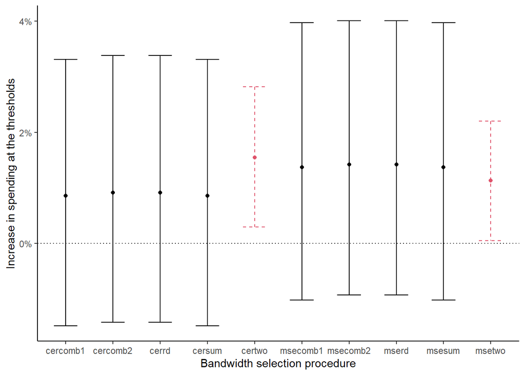

```r
ggplot2::ggplot(data = rdd_vary_bwselect, aes(x = bw_sel_algo, y = point_estimate)) +
  geom_point(size = 1.5, color = ifelse(rdd_vary_bwselect$p <= 0.05, 2, 1)) +
  geom_errorbar(aes(ymin = ci_lower, ymax = ci_upper),
                color = ifelse(rdd_vary_bwselect$p <= 0.05, 2, 1),
                linetype = ifelse(rdd_vary_bwselect$p <= 0.05, 2, 1),
                width = 0.5) +
  geom_hline(aes(yintercept = 0), linetype = "dotted") +
  scale_y_continuous(labels = scales::percent) +
  labs(x = "Bandwidth selection procedure", y = y_lab_RDD)
```

```r
rm(rdd)
```

### Dropping confounded thresholds

Dropping confounded thresholds as determined by my own legal research: The conclusions are quite similar for both “Höhmann’s” and “my” thresholds – the effect of council size is small and positive (in the really small single-digits) but nonsignificant for both counfounded as well as nonconfounded thresholds.

#### “My” research variable `clean_disc_acc_to_my_research`

… is first up.

Subsample method:

```r
data_subset <- data %>% # prepare data set used for analysis
  select(ln_gross_expenditure_pc, inhabs_rel_to_cutoff, total_seats, inhabitants_treshold_factor, state, year, clean_disc_acc_to_my_research) %>%
  drop_na()
all_values <- data_subset %>% distinct(clean_disc_acc_to_my_research) %>% pull() # vector of values
rdd_vary_clean_disc1 <- # prepare data set to store the results
  tibble(value = "", point_estimate = "", se = "", se_robust = "",
         ci_lower = "", ci_upper = "", p = "", bw = "", obs_below = "", obs_above = "") %>%
  mutate(across(everything(), as.numeric))
for (i in all_values) {
  print(paste("clean_disc_acc_to_my_research:", i))
  df <- data_subset %>%
    filter(clean_disc_acc_to_my_research == i)
  rdd <-
    rdrobust_wrapper(
      ccluster = df$inhabitants_treshold_factor,
      ccovs = model.matrix( ~ df$inhabitants_treshold_factor + df$state + df$year) # FE
  )
  #summary(rdd)
  rdd_vary_clean_disc1 <- rdd_vary_clean_disc1 %>%
    dplyr::add_row(
      value = i,
      point_estimate = rdd$coef[1],
      se = rdd$se[1],
      se_robust = rdd$se[3],
      ci_lower = rdd$ci[3,1],
      ci_upper = rdd$ci[3,2],
      p = rdd$pv[3],
      bw = rdd$bws[1,1],
      obs_below = rdd$N_h[1],
      obs_above = rdd$N_h[2]
  )
}
```

```
## [1] "clean_disc_acc_to_my_research: 0"
## [1] "Mass points detected in the running variable."
## [1] "clean_disc_acc_to_my_research: 1"
## [1] "Mass points detected in the running variable."
```

```r
rdd_vary_clean_disc1 <- rdd_vary_clean_disc1 %>% drop_na()
save(rdd_vary_clean_disc1, file = "tables_robustness_checks/rdd_vary_clean_disc1.Rdata")
rm(all_values, data_subset, df, i, rdd)
```

```r
load(file = "tables_robustness_checks/rdd_vary_clean_disc1.Rdata")
rdd_vary_clean_disc1
```

| value | point_estimate | se | se_robust | ci_lower | ci_upper | p | bw | obs_below | obs_above |
| --- | --- | --- | --- | --- | --- | --- | --- | --- | --- |
| 0 | 0.016225360 | 0.013259783 | 0.013823161 | -0.01775705 | 0.05345515 | 0.1966197 | 0.06207200 | 7976 | 8307 |
| 1 | 0.005515288 | 0.009672589 | 0.009954571 | -0.01887363 | 0.03240892 | 0.4965975 | 0.05493327 | 1129 | 1363 |

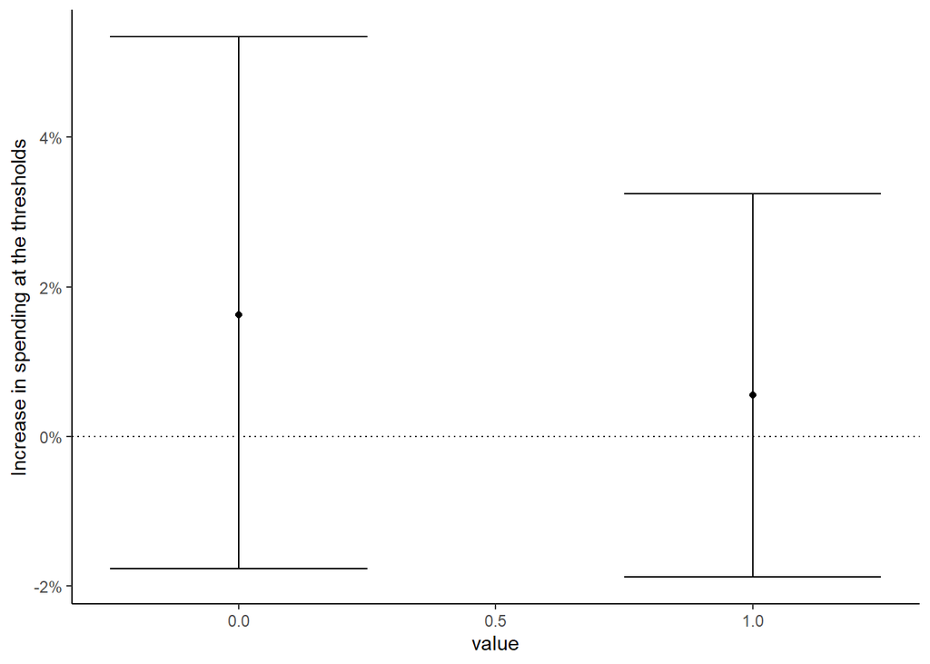

```r
ggplot2::ggplot(data = rdd_vary_clean_disc1, aes(x = value, y = point_estimate)) +
  geom_point(size = 1.5, color = ifelse(rdd_vary_clean_disc1$p <= p_value_cutoff, 2, 1)) +
  geom_errorbar(aes(ymin = ci_lower, ymax = ci_upper),
                color = ifelse(rdd_vary_clean_disc1$p <= p_value_cutoff, 2, 1),
                linetype = ifelse(rdd_vary_clean_disc1$p <= p_value_cutoff, 2, 1),
                width = 0.5) +
  geom_hline(aes(yintercept = 0), linetype = "dotted") +
  scale_y_continuous(labels = scales::percent) +
  labs(y = y_lab_RDD)
```

Looks like there is no difference.

Interaction-term method using an IV approach:

```r
df <- data %>%
  filter(closest <= 0.1)
rdd_conf_1 <- fixest::feols(ln_gross_expenditure_pc ~
                       1  | # controls
                       inhabitants_treshold_factor + state + year | # fixed-effect controls
                       # First stage regression:
                       inhabs_rel_to_cutoff*total_seats*clean_disc_acc_to_my_research ~
                       inhabs_rel_to_cutoff*above_cutoff*clean_disc_acc_to_my_research,
                     vcov = "threeway",
                     data = df)
```

```
## NOTE: 10,673 observations removed because of NA values (LHS: 10,673).
```

```r
# Observations below and above:
rdd_conf_1_obs <- d_rdd_bivariate %>% nrow()
rdd_conf_1_below <- df %>% filter(above_cutoff == 0) %>% nrow()
rdd_conf_1_above <- df %>% filter(above_cutoff == 1) %>% nrow()
summary(rdd_conf_1)
```

```
## TSLS estimation, Dep. Var.: ln_gross_expenditure_pc, Endo.: inhabs_rel_to_cutoff, total_seats, clean_disc_acc_to_my_research, inhabs_rel_to_cutoff:total_seats, inhabs_rel_to_cutoff:clean_disc_acc_to_my_research, total_seats:clean_disc_acc_to_my_research, inhabs_rel_to_cutoff:total_seats:clean_dis…
## Second stage: Dep. Var.: ln_gross_expenditure_pc
## Observations: 12,520
## Fixed-effects: inhabitants_treshold_factor: 30,  state: 10,  year: 13
## Standard-errors: Clustered (inhabitants_treshold_factor & state & year)
##                                                                     Estimate
## fit_inhabs_rel_to_cutoff                                            3.257599
## fit_total_seats                                                     0.019690
## fit_clean_disc_acc_to_my_research                                   0.283800
## fit_inhabs_rel_to_cutoff:total_seats                               -0.236507
## fit_inhabs_rel_to_cutoff:clean_disc_acc_to_my_research             47.028245
## fit_total_seats:clean_disc_acc_to_my_research                      -0.011998
## fit_inhabs_rel_to_cutoff:total_seats:clean_disc_acc_to_my_research -2.760721
##                                                                    Std. Error
## fit_inhabs_rel_to_cutoff                                             3.991072
## fit_total_seats                                                      0.022816
## fit_clean_disc_acc_to_my_research                                    0.737675
## fit_inhabs_rel_to_cutoff:total_seats                                 0.259512
## fit_inhabs_rel_to_cutoff:clean_disc_acc_to_my_research              55.051136
## fit_total_seats:clean_disc_acc_to_my_research                        0.041494
## fit_inhabs_rel_to_cutoff:total_seats:clean_disc_acc_to_my_research   3.396397
##                                                                      t value
## fit_inhabs_rel_to_cutoff                                            0.816222
## fit_total_seats                                                     0.863001
## fit_clean_disc_acc_to_my_research                                   0.384722
## fit_inhabs_rel_to_cutoff:total_seats                               -0.911352
## fit_inhabs_rel_to_cutoff:clean_disc_acc_to_my_research              0.854265
## fit_total_seats:clean_disc_acc_to_my_research                      -0.289147
## fit_inhabs_rel_to_cutoff:total_seats:clean_disc_acc_to_my_research -0.812838
##                                                                    Pr(>|t|)
## fit_inhabs_rel_to_cutoff                                            0.43544
## fit_total_seats                                                     0.41054
## fit_clean_disc_acc_to_my_research                                   0.70938
## fit_inhabs_rel_to_cutoff:total_seats                                0.38587
## fit_inhabs_rel_to_cutoff:clean_disc_acc_to_my_research              0.41512
## fit_total_seats:clean_disc_acc_to_my_research                       0.77902
## fit_inhabs_rel_to_cutoff:total_seats:clean_disc_acc_to_my_research  0.43728
## ---
## Signif. codes:  0 '***' 0.001 '**' 0.01 '*' 0.05 '.' 0.1 ' ' 1
## RMSE: 0.395492     Adj. R2: -0.015673
##                  Within R2: -0.800323
## F-test (1st stage), inhabs_rel_to_cutoff                                          : stat =     3.719e+32, p < 2.2e-16, on 7 and 12,512 DoF.
## F-test (1st stage), total_seats                                                   : stat =   623.2      , p < 2.2e-16, on 7 and 12,512 DoF.
## F-test (1st stage), clean_disc_acc_to_my_research                                 : stat =     3.29e+33 , p < 2.2e-16, on 7 and 12,512 DoF.
## F-test (1st stage), inhabs_rel_to_cutoff:total_seats                              : stat = 7,623.4      , p < 2.2e-16, on 7 and 12,512 DoF.
## F-test (1st stage), inhabs_rel_to_cutoff:clean_disc_acc_to_my_research            : stat =     1.223e+33, p < 2.2e-16, on 7 and 12,512 DoF.
## F-test (1st stage), total_seats:clean_disc_acc_to_my_research                     : stat = 4,675.8      , p < 2.2e-16, on 7 and 12,512 DoF.
## F-test (1st stage), inhabs_rel_to_cutoff:total_seats:clean_disc_acc_to_my_research: stat = 4,745.4      , p < 2.2e-16, on 7 and 12,512 DoF.
##                                                                         Wu-Hausman: stat =    NA        , p = NA     , on 7 and 12,455 DoF.
```

```r
rm(df)
```

#### Höhmann’s (2017) research variable `clean_disc_acc_Höhmann`

Next up are the reevaluation of what Höhmann (2017) determines as confounded thresholds.

Subsample method:

```r
data_subset <- data %>% # prepare data set used for analysis
  select(ln_gross_expenditure_pc, inhabs_rel_to_cutoff, total_seats, inhabitants_treshold_factor, state, year, clean_disc_acc_Höhmann) %>%
  drop_na()
all_values <- data_subset %>% distinct(clean_disc_acc_Höhmann) %>% pull() # vector of values
rdd_vary_clean_disc2 <- # prepare data set to store the results
  tibble(value = "", point_estimate = "", se = "", se_robust = "",
         ci_lower = "", ci_upper = "", p = "", bw = "", obs_below = "", obs_above = "") %>%
  mutate(across(everything(), as.numeric))
for (i in all_values) {
  print(paste("clean_disc_acc_Höhmann:", i))
  df <- data_subset %>%
    filter(clean_disc_acc_Höhmann == i)
  rdd <-
    rdrobust_wrapper(
      ccluster = df$inhabitants_treshold_factor,
      ccovs = model.matrix( ~ df$inhabitants_treshold_factor + df$state + df$year) # FE
  )
  #summary(rdd)
  rdd_vary_clean_disc2 <- rdd_vary_clean_disc2 %>%
    dplyr::add_row(
      value = i,
      point_estimate = rdd$coef[1],
      se = rdd$se[1],
      se_robust = rdd$se[3],
      ci_lower = rdd$ci[3,1],
      ci_upper = rdd$ci[3,2],
      p = rdd$pv[3],
      bw = rdd$bws[1,1],
      obs_below = rdd$N_h[1],
      obs_above = rdd$N_h[2]
  )
}
```

```
## [1] "clean_disc_acc_Höhmann: 1"
## [1] "Mass points detected in the running variable."
## [1] "clean_disc_acc_Höhmann: 0"
## [1] "Mass points detected in the running variable."
```

```r
rdd_vary_clean_disc2 <- rdd_vary_clean_disc2 %>% drop_na()
save(rdd_vary_clean_disc2, file = "tables_robustness_checks/rdd_vary_clean_disc2.Rdata")
rm(all_values, data_subset, df, i, rdd)
```

```r
load(file = "tables_robustness_checks/rdd_vary_clean_disc2.Rdata")
rdd_vary_clean_disc2
```

| value | point_estimate | se | se_robust | ci_lower | ci_upper | p | bw | obs_below | obs_above |
| --- | --- | --- | --- | --- | --- | --- | --- | --- | --- |
| 1 | 0.022316038 | 0.018363856 | 0.018939457 | -0.023200501 | 0.07436912 | 0.1767445 | 0.06036127 | 5302 | 5462 |
| 0 | 0.006475172 | 0.005049555 | 0.005592047 | -0.008706841 | 0.02010148 | 0.3082860 | 0.12659442 | 7782 | 8155 |

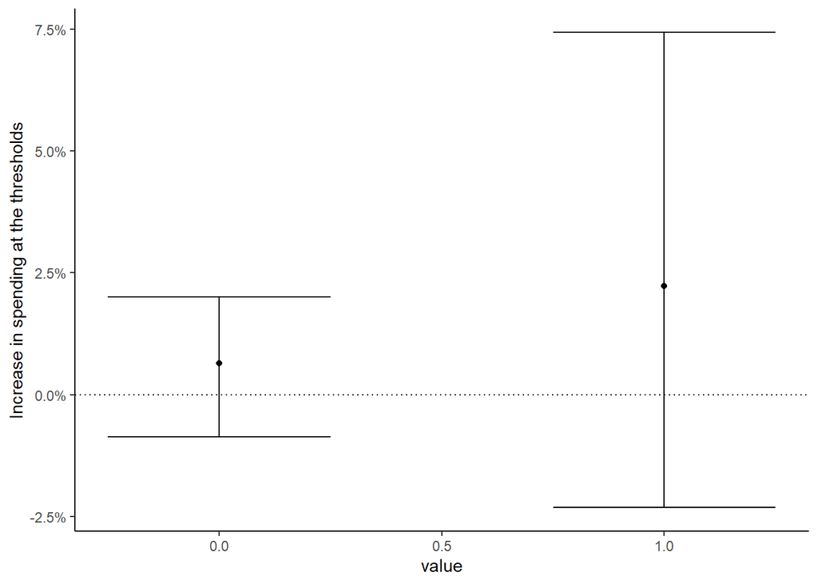

```r
ggplot2::ggplot(data = rdd_vary_clean_disc2, aes(x = value, y = point_estimate)) +
  geom_point(size = 1.5, color = ifelse(rdd_vary_clean_disc2$p <= p_value_cutoff, 2, 1)) +
  geom_errorbar(aes(ymin = ci_lower, ymax = ci_upper),
                color = ifelse(rdd_vary_clean_disc2$p <= p_value_cutoff, 2, 1),
                linetype = ifelse(rdd_vary_clean_disc2$p <= p_value_cutoff, 2, 1),
                width = 0.5) +
  geom_hline(aes(yintercept = 0), linetype = "dotted") +
  scale_y_continuous(labels = scales::percent) +
  labs(y = y_lab_RDD)
```

Looks like there is no difference, again.

Interaction-term method using an IV approach:

```r
df <- data %>%
  filter(closest <= 0.1)
rdd_conf_2 <- fixest::feols(ln_gross_expenditure_pc ~
                       1  | # controls
                       inhabitants_treshold_factor + state + year | # fixed-effect controls
                       # First stage regression:
                       inhabs_rel_to_cutoff*total_seats*clean_disc_acc_Höhmann ~
                       inhabs_rel_to_cutoff*above_cutoff*clean_disc_acc_Höhmann,
                     vcov = "threeway",
                     data = df)
```

```
## NOTE: 10,707 observations removed because of NA values (LHS: 10,673, IV: 1,702/1,702).
```

```
## Variance contained negative values in the diagonal and was 'fixed' (a la Cameron, Gelbach & Miller 2011).
```

```r
# Observations below and above:
rdd_conf_2_obs <- d_rdd_bivariate %>% nrow()
rdd_conf_2_below <- df %>% filter(above_cutoff == 0) %>% nrow()
rdd_conf_2_above <- df %>% filter(above_cutoff == 1) %>% nrow()
summary(rdd_conf_2)
```

```
## TSLS estimation, Dep. Var.: ln_gross_expenditure_pc, Endo.: inhabs_rel_to_cutoff, total_seats, clean_disc_acc_Höhmann, inhabs_rel_to_cutoff:total_seats, inhabs_rel_to_cutoff:clean_disc_acc_Höhmann, total_seats:clean_disc_acc_Höhmann, inhabs_rel_to_cutoff:total_seats:clean_disc_acc_Höhmann, Instr.…
## Second stage: Dep. Var.: ln_gross_expenditure_pc
## Observations: 12,486
## Fixed-effects: inhabitants_treshold_factor: 29,  state: 9,  year: 13
## Standard-errors: Clustered (inhabitants_treshold_factor & state & year)
##                                                              Estimate
## fit_inhabs_rel_to_cutoff                                     3.678930
## fit_total_seats                                             -0.028242
## fit_clean_disc_acc_Höhmann                                  -1.340781
## fit_inhabs_rel_to_cutoff:total_seats                        -0.090358
## fit_inhabs_rel_to_cutoff:clean_disc_acc_Höhmann             -6.734911
## fit_total_seats:clean_disc_acc_Höhmann                       0.070457
## fit_inhabs_rel_to_cutoff:total_seats:clean_disc_acc_Höhmann  0.186589
##                                                             Std. Error
## fit_inhabs_rel_to_cutoff                                      6.865718
## fit_total_seats                                               0.011995
## fit_clean_disc_acc_Höhmann                                    0.653884
## fit_inhabs_rel_to_cutoff:total_seats                          0.304005
## fit_inhabs_rel_to_cutoff:clean_disc_acc_Höhmann               8.894486
## fit_total_seats:clean_disc_acc_Höhmann                        0.031223
## fit_inhabs_rel_to_cutoff:total_seats:clean_disc_acc_Höhmann   0.552408
##                                                               t value Pr(>|t|)
## fit_inhabs_rel_to_cutoff                                     0.535841 0.606641
## fit_total_seats                                             -2.354474 0.046356
## fit_clean_disc_acc_Höhmann                                  -2.050489 0.074452
## fit_inhabs_rel_to_cutoff:total_seats                        -0.297227 0.773865
## fit_inhabs_rel_to_cutoff:clean_disc_acc_Höhmann             -0.757201 0.470641
## fit_total_seats:clean_disc_acc_Höhmann                       2.256603 0.054008
## fit_inhabs_rel_to_cutoff:total_seats:clean_disc_acc_Höhmann  0.337773 0.744227
##
## fit_inhabs_rel_to_cutoff
## fit_total_seats                                             *
## fit_clean_disc_acc_Höhmann                                  .
## fit_inhabs_rel_to_cutoff:total_seats
## fit_inhabs_rel_to_cutoff:clean_disc_acc_Höhmann
## fit_total_seats:clean_disc_acc_Höhmann                      .
## fit_inhabs_rel_to_cutoff:total_seats:clean_disc_acc_Höhmann
## ---
## Signif. codes:  0 '***' 0.001 '**' 0.01 '*' 0.05 '.' 0.1 ' ' 1
## RMSE: 0.329602     Adj. R2:  0.293233
##                  Within R2: -0.249093
## F-test (1st stage), inhabs_rel_to_cutoff                                   : stat =      8.913e+31, p < 2.2e-16, on 7 and 12,478 DoF.
## F-test (1st stage), total_seats                                            : stat =    571.1      , p < 2.2e-16, on 7 and 12,478 DoF.
## F-test (1st stage), clean_disc_acc_Höhmann                                : stat =      4.12e+33 , p < 2.2e-16, on 7 and 12,478 DoF.
## F-test (1st stage), inhabs_rel_to_cutoff:total_seats                       : stat =  9,123.1      , p < 2.2e-16, on 7 and 12,478 DoF.
## F-test (1st stage), inhabs_rel_to_cutoff:clean_disc_acc_Höhmann           : stat =      1.067e+32, p < 2.2e-16, on 7 and 12,478 DoF.
## F-test (1st stage), total_seats:clean_disc_acc_Höhmann                    : stat =  6,662.4      , p < 2.2e-16, on 7 and 12,478 DoF.
## F-test (1st stage), inhabs_rel_to_cutoff:total_seats:clean_disc_acc_Höhmann: stat = 10,576.5      , p < 2.2e-16, on 7 and 12,478 DoF.
##                                                                  Wu-Hausman: stat =     NA        , p = NA     , on 7 and 12,423 DoF.
```

```r
rdd_conf_2$coefficients[2] + rdd_conf_2$coefficients[6]
```

```
## fit_total_seats
##      0.04221477
```

```r
rm(df)
```

Looks like there is a difference after all.

```r
etable(rdd_conf_1, rdd_conf_2,
       file = "tables/rdd_conf_thresholds.tex",
       replace = TRUE,
       # Table settings
       keep = c("Council size baseline for nonconfounded thresholds",
                "Additional TE for confounded thresholds"),
       dict = c(total_seats = "Council size baseline for nonconfounded thresholds",
                `total_seats:clean_disc_acc_to_my_research` = "Additional TE for confounded thresholds",
                `total_seats:clean_disc_acc_Höhmann` = "Additional TE for confounded thresholds",
                ln_gross_expenditure_pc = "Ln of gross expenditure p. c."),
       drop.section = "fixef",
       signif.code = c("***"=0.001, "**"=0.01, "*"=0.05, "'"=0.10),
       headers = c("Confounded thresholds based on my research",
                   "Confounded thresholds based on \\citeauthor{Hohmann.2017}'s \\parencite*{Hohmann.2017} research"),
        extralines = list(
       #   "-^Controls" = c("No", "Yes")#,
       #   #"-_\\acs{SE}" = rep("by threshold, \\acs{yr} & \\acs{mcp}", 2),
       #   #"_^Data sample" = c(rep("All data", 3), "\\acs{BY} only")
          "_^Observations above" = c(rdd_conf_1_above, rdd_conf_2_above),
         "_^Observations below" = c(rdd_conf_1_below, rdd_conf_2_below),
         "_^Observations" = c(rdd_conf_1_obs, rdd_conf_2_obs),
         "_^Window around the threshold" = rep("10%", 2)

          ),
       # LaTeX settings
       title = "Results of the interacted \\acs{IV} \\acs{RDD}s to investigate (non)confounded thresholds",
       label = "tab:rdd_conf_thresholds",
       notes = paste("\\footnotesize{*Notes:* Results of the \\ac{IV} \\ac{RDD}, in a ten-percent window around the cutoffs. No control variables but threshold, state, and year \\ac{FE}. Standard errors clustered at the threshold, year and municipality level in parentheses.",
                     tex_signif_text)#,
       # style.tex = style.tex(
       #   fixef.suffix = " \\ac{FE}"
       # )
       )
```

### Placebo thresholds

#### Overall sample

First attempt

```r
rdd_placebo <-
  tibble(placebo_c = "", point_estimate = "", se = "", se_robust = "",
         ci_lower = "", ci_upper = "", p = "", bw = "", obs_below = "", obs_above = "") %>%
  mutate(across(everything(), as.numeric))
vector <- seq(from = -(2+2/3), to = 2/3, by = 1/6) # Choose vector of arbitrary placebo cutoffs
#vector <- vector[!vector %in% (-2-1/3)]
vector <- vector[-c(3, 21)] # Drop cutoffs that yield errors
for (i in vector) {
  print(paste("Cutoff at:", i))
  rdd <- rdrobust_fe_model(cc = i)
  #summary(rdd)
  rdd_placebo <- rdd_placebo %>%
    dplyr::add_row(
      placebo_c = i,
      point_estimate = rdd$coef[1],
      se = rdd$se[1],
      se_robust = rdd$se[3],
      ci_lower = rdd$ci[3,1],
      ci_upper = rdd$ci[3,2],
      p = rdd$pv[3],
      bw = rdd$bws[1,1],
      obs_below = rdd$N_h[1],
      obs_above = rdd$N_h[2]
  )
}
```

```
## [1] "Cutoff at: -2.66666666666667"
## [1] "Mass points detected in the running variable."
## [1] "Cutoff at: -2.5"
## [1] "Mass points detected in the running variable."
## [1] "Cutoff at: -2.16666666666667"
## [1] "Mass points detected in the running variable."
## [1] "Cutoff at: -2"
## [1] "Mass points detected in the running variable."
## [1] "Cutoff at: -1.83333333333333"
## [1] "Mass points detected in the running variable."
## [1] "Cutoff at: -1.66666666666667"
## [1] "Mass points detected in the running variable."
## [1] "Cutoff at: -1.5"
## [1] "Mass points detected in the running variable."
## [1] "Cutoff at: -1.33333333333333"
```

[output cut: 23 more lines]

```r
rdd_placebo <- rdd_placebo %>% drop_na()
rm(vector)
save(rdd_placebo, file = "tables_robustness_checks/rdd_placebo_1.Rdata")
```

```r
load(file = "tables_robustness_checks/rdd_placebo_1.Rdata")
rdd_placebo
```

| placebo_c | point_estimate | se | se_robust | ci_lower | ci_upper | p | bw | obs_below | obs_above |
| --- | --- | --- | --- | --- | --- | --- | --- | --- | --- |
| -2.6666667 | -12.83766434 | 2.56945829 | 2.704199415 | -27.350795260 | -16.75052834 | 0.0000000000000003514139 | 0.381986680 | 37 | 85 |
| -2.5000000 | -5.33702148 | 6.00570981 | 6.259661193 | -18.128083239 | 6.40933775 | 0.3492460560031930283387 | 0.158446601 | 29 | 26 |
| -2.1666667 | 47.04538307 | 155.66494461 | 160.267626986 | -325.825819473 | 302.41173409 | 0.9417688491411100315531 | 0.048851459 | 15 | 50 |
| -2.0000000 | 835.00778260 | 284924.43310351 | 498360.791208308 | -1004542.677695091 | 948995.72645525 | 0.9555571738774208956357 | 0.047182903 | 41 | 45 |
| -1.8333333 | -326.33739598 | 403.58992563 | 432.279407046 | -2122.792626913 | -428.28848878 | 0.0031702214759080533935 | 0.147023220 | 142 | 249 |
| -1.6666667 | 1.62674390 | 0.25447651 | 0.260543847 | 1.339447756 | 2.36076087 | 0.0000000000012391774530 | 0.023626086 | 50 | 92 |
| -1.5000000 | -1.28906639 | 0.40949791 | 0.447392762 | -2.961167563 | -1.20742016 | 0.0000031812550122383299 | 0.031771674 | 75 | 117 |
| -1.3333333 | 11.40400835 | 3.48805074 | 3.795334037 | 4.563005312 | 19.44044136 | 0.0015656525790461836740 | 0.021019779 | 48 | 30 |
| -1.1666667 | 0.15695437 | 0.02721842 | 0.647343222 | -0.477656862 | 2.05988194 | 0.2216730917325550609398 | 0.026779189 | 116 | 99 |
| -1.0000000 | 44.70700335 | 131.76973805 | 154.721269720 | -280.140559566 | 326.35567302 | 0.8812777943472744901499 | 0.058717738 | 252 | 256 |

[output cut: 9 more lines]

Visualization of placebo cutoffs:

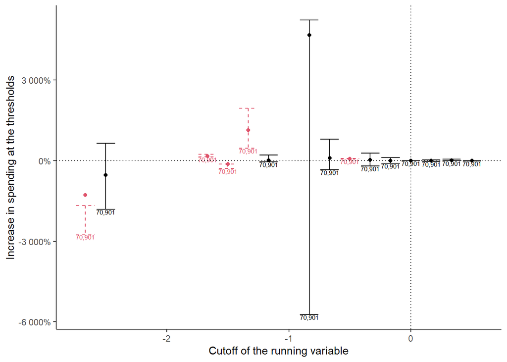

```r
df <- rdd_placebo %>%
  #tidyr::drop_na() %>%
  filter(abs(ci_upper) < 100 | abs(ci_lower) < 100) %>%
  mutate(effective_n = trimws(format(sum(obs_below, obs_above), big.mark = ",") ) ) # add big mark
ggplot2::ggplot(df) +
  geom_point(aes(x = placebo_c, y = point_estimate), size = 1.5, colour = ifelse(df$p <= 0.05, 2, 1)) +
  geom_errorbar(aes(x = placebo_c, ymin = ci_lower, ymax = ci_upper),
                colour = ifelse(df$p <= 0.05, 2, 1),
                linetype = ifelse(df$p <= 0.05, 2, 1)) +
  geom_text(aes(x = placebo_c, y = ci_lower, label = effective_n),
            colour = ifelse(df$p <= 0.05, 2, 1), vjust = 1, size = 2.3, check_overlap = TRUE) +
  geom_hline(aes(yintercept = 0), linetype = "dotted") +
  geom_vline(aes(xintercept = 0), linetype = "dotted") +
  scale_y_continuous(labels = scales::percent) +
  labs(x = "Cutoff of the running variable", y = y_lab_RDD)
```

```r
ggsave(filename = "plots/rdrobust_placebo_wide.pdf", width = 6, height = 6*9/16)
rm(df)
```

Second attempt – main approach: Regular cutoffs within the inter-quartile range.

```r
rdd_placebo <-
  tibble(placebo_c = "", point_estimate = "", se = "", se_robust = "",
         ci_lower = "", ci_upper = "", p = "", bw = "", obs_below = "", obs_above = "") %>%
  mutate(across(everything(), as.numeric))
vector <- seq(from = (-0.15), to = (0.18), by = 0.03) # Choose vector of arbitrary placebo cutoffs
for (i in vector) {
  print(paste("Cutoff at:", i))
  rdd <- rdrobust_fe_model(cc = i)
  #summary(rdd)
  rdd_placebo <- rdd_placebo %>%
    dplyr::add_row(
      placebo_c = i,
      point_estimate = rdd$coef[1],
      se = rdd$se[1],
      se_robust = rdd$se[3],
      ci_lower = rdd$ci[3,1],
      ci_upper = rdd$ci[3,2],
      p = rdd$pv[3],
      bw = rdd$bws[1,1],
      obs_below = rdd$N_h[1],
      obs_above = rdd$N_h[2]
  )
}
```

```
## [1] "Cutoff at: -0.15"
## [1] "Mass points detected in the running variable."
## [1] "Cutoff at: -0.12"
## [1] "Mass points detected in the running variable."
## [1] "Cutoff at: -0.09"
## [1] "Mass points detected in the running variable."
## [1] "Cutoff at: -0.06"
## [1] "Mass points detected in the running variable."
## [1] "Cutoff at: -0.03"
## [1] "Mass points detected in the running variable."
## [1] "Cutoff at: 0"
## [1] "Mass points detected in the running variable."
## [1] "Cutoff at: 0.03"
## [1] "Mass points detected in the running variable."
## [1] "Cutoff at: 0.06"
## [1] "Mass points detected in the running variable."
## [1] "Cutoff at: 0.09"
## [1] "Mass points detected in the running variable."
## [1] "Cutoff at: 0.12"
## [1] "Mass points detected in the running variable."
## [1] "Cutoff at: 0.15"
## [1] "Mass points detected in the running variable."
## [1] "Cutoff at: 0.18"
## [1] "Mass points detected in the running variable."
```

```r
rdd_placebo <- rdd_placebo %>% drop_na()
rm(vector)
save(rdd_placebo, file = "tables_robustness_checks/rdd_placebo_2.Rdata")
```

```r
load(file = "tables_robustness_checks/rdd_placebo_2.Rdata")
rdd_placebo
```

| placebo_c | point_estimate | se | se_robust | ci_lower | ci_upper | p | bw | obs_below | obs_above |
| --- | --- | --- | --- | --- | --- | --- | --- | --- | --- |
| -0.15 | 0.117970205 | 0.08547326 | 0.08595052 | -0.069057863 | 0.26786197 | 0.247475357 | 0.04352892 | 6394 | 6645 |
| -0.12 | -0.101540745 | 0.27414276 | 0.27758682 | -0.571706491 | 0.51641383 | 0.920665663 | 0.04177829 | 6342 | 6408 |
| -0.09 | -0.057038540 | 0.04996444 | 0.05422208 | -0.164715966 | 0.04783067 | 0.281105764 | 0.09142033 | 14010 | 13738 |
| -0.06 | 0.269881922 | 0.25857272 | 0.27200191 | -0.394010414 | 0.67221747 | 0.609066482 | 0.06933317 | 10742 | 10370 |
| -0.03 | 0.014901604 | 0.02306900 | 0.02337335 | -0.034444338 | 0.05717752 | 0.626750564 | 0.07298297 | 11181 | 11134 |
| 0.00 | 0.014186948 | 0.01209439 | 0.01259746 | -0.009297968 | 0.04008317 | 0.221752552 | 0.04964999 | 7238 | 7893 |
| 0.03 | 0.201499675 | 0.20420628 | 0.20911443 | -0.339782504 | 0.47993098 | 0.737549669 | 0.04545188 | 7019 | 7203 |
| 0.06 | -0.006712985 | 0.03641690 | 0.03933352 | -0.080021515 | 0.07416306 | 0.940635245 | 0.07146956 | 11148 | 10892 |
| 0.09 | 0.239836829 | 0.37575753 | 0.39138923 | -0.708596776 | 0.82562082 | 0.881160456 | 0.06067653 | 9403 | 9384 |
| 0.12 | -0.068915445 | 0.12964914 | 0.14030598 | -0.327729324 | 0.22226000 | 0.707024930 | 0.05481075 | 8235 | 8811 |

[output cut: 2 more lines]

Visualization of placebo cutoffs:

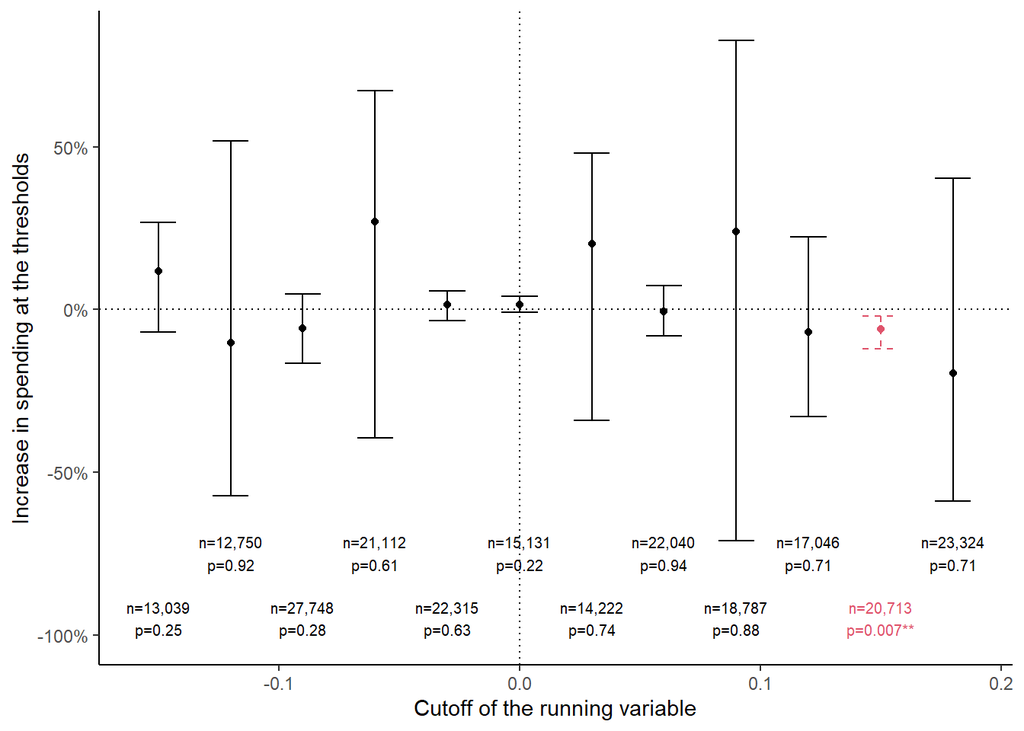

```r
df <- rdd_placebo %>%
  #tidyr::drop_na() %>%
  #filter(abs(ci_upper) < 100 | abs(ci_lower) < 100) %>%
  rowwise() %>%
  mutate(note = paste0("n=",
                       trimws(format(sum(obs_below, obs_above), big.mark = ",") ),
                       "\n",
                       p_value(p),
                       assign_stars(p) ) ) %>% # add big mark
  ungroup()
even_number <- round(abs(df$placebo_c*100) %% 2, 0) %% 2
ggplot2::ggplot(df) +
  geom_point(aes(x = placebo_c, y = point_estimate), size = 1.5, colour = ifelse(df$p <= 0.05, 2, 1)) +
  geom_errorbar(aes(x = placebo_c, ymin = ci_lower, ymax = ci_upper),
                colour = ifelse(df$p <= 0.05, 2, 1),
                linetype = ifelse(df$p <= 0.05, 2, 1),
                width = 0.015) +
  geom_text(aes(x = placebo_c,
                y = ifelse(even_number == 0, -0.8, -1),
                label = note),
            colour = ifelse(df$p <= 0.05, 2, 1),
            size = 2.7,
            vjust = 0) +
  geom_hline(aes(yintercept = 0), linetype = "dotted") +
  geom_vline(aes(xintercept = 0), linetype = "dotted") +
  scale_y_continuous(labels = scales::percent) +
  labs(x = "Cutoff of the running variable", y = y_lab_RDD)
```

```r
ggsave(filename = "plots/rdrobust_placebo.pdf", width = 6, height = 6*9/16)
rm(df, even_number)
```

Third attempt: Random cutoffs within the inter-quartile range.

```r
rdd_placebo <-
  tibble(placebo_c = "", point_estimate = "", se = "", se_robust = "",
         ci_lower = "", ci_upper = "", p = "", bw = "", obs_below = "", obs_above = "") %>%
  mutate(across(everything(), as.numeric))
set.seed(1234)
vector <- runif(n = 10, min = -0.15, max = 0.18) # Choose vector of random placebo cutoffs
for (i in vector) {
  print(paste("Cutoff at:", i))
  rdd <- rdrobust_fe_model(cc = i)
  #summary(rdd)
  rdd_placebo <- rdd_placebo %>%
    dplyr::add_row(
      placebo_c = i,
      point_estimate = rdd$coef[1],
      se = rdd$se[1],
      se_robust = rdd$se[3],
      ci_lower = rdd$ci[3,1],
      ci_upper = rdd$ci[3,2],
      p = rdd$pv[3],
      bw = rdd$bws[1,1],
      obs_below = rdd$N_h[1],
      obs_above = rdd$N_h[2]
  )
}
```

```
## [1] "Cutoff at: -0.112477874269243"
## [1] "Mass points detected in the running variable."
## [1] "Cutoff at: 0.055358803588897"
## [1] "Mass points detected in the running variable."
## [1] "Cutoff at: 0.0510606618504971"
## [1] "Mass points detected in the running variable."
## [1] "Cutoff at: 0.0557152157532982"
## [1] "Mass points detected in the running variable."
## [1] "Cutoff at: 0.134102076573763"
## [1] "Mass points detected in the running variable."
## [1] "Cutoff at: 0.0613024997455068"
## [1] "Mass points detected in the running variable."
## [1] "Cutoff at: -0.146866400402505"
## [1] "Mass points detected in the running variable."
## [1] "Cutoff at: -0.0732583330152556"
## [1] "Mass points detected in the running variable."
## [1] "Cutoff at: 0.0698076402163133"
## [1] "Mass points detected in the running variable."
## [1] "Cutoff at: 0.0197028766432777"
## [1] "Mass points detected in the running variable."
```

```r
rdd_placebo <- rdd_placebo %>% drop_na() %>% arrange(placebo_c)
rm(vector)
save(rdd_placebo, file = "tables_robustness_checks/rdd_placebo_3.Rdata")
```

```r
load(file = "tables_robustness_checks/rdd_placebo_3.Rdata")
rdd_placebo
```

| placebo_c | point_estimate | se | se_robust | ci_lower | ci_upper | p | bw | obs_below | obs_above |
| --- | --- | --- | --- | --- | --- | --- | --- | --- | --- |
| -0.14686640 | -0.070014426 | 0.21156184 | 0.21304549 | -0.53099363 | 0.30412936 | 0.5944272 | 0.05298178 | 7745 | 8062 |
| -0.11247787 | -0.042866570 | 0.36741735 | 0.37682855 | -0.77615692 | 0.70098386 | 0.9205473 | 0.03414813 | 5150 | 5219 |
| -0.07325833 | -0.046545493 | 0.32281300 | 0.33381708 | -0.59771409 | 0.71082483 | 0.8654661 | 0.04395339 | 6776 | 6823 |
| 0.01970288 | 0.047586874 | 0.07277429 | 0.07609471 | -0.11988666 | 0.17839911 | 0.7006292 | 0.05329093 | 8081 | 8393 |
| 0.05106066 | -0.083513050 | 0.07125737 | 0.07360098 | -0.19928387 | 0.08922666 | 0.4546645 | 0.06253612 | 9728 | 9494 |
| 0.05535880 | -0.139272920 | 0.20590042 | 0.21231021 | -0.45399514 | 0.37824558 | 0.8584139 | 0.06742096 | 10406 | 10243 |
| 0.05571522 | -0.173946448 | 1.15354448 | 1.19194265 | -1.89323597 | 2.77909337 | 0.7101889 | 0.06730965 | 10453 | 10210 |
| 0.06130250 | -0.012903811 | 0.04702637 | 0.04848756 | -0.10411949 | 0.08594824 | 0.8513623 | 0.06670999 | 10402 | 10112 |
| 0.06980764 | 0.003103435 | 0.01294501 | 0.01487931 | -0.02566162 | 0.03266419 | 0.8139663 | 0.11649067 | 17923 | 18120 |
| 0.13410208 | 2.186557625 | 32.73706173 | 33.78204849 | -77.33150948 | 55.09168726 | 0.7420300 | 0.07679872 | 11721 | 12288 |

Visualization of placebo cutoffs:

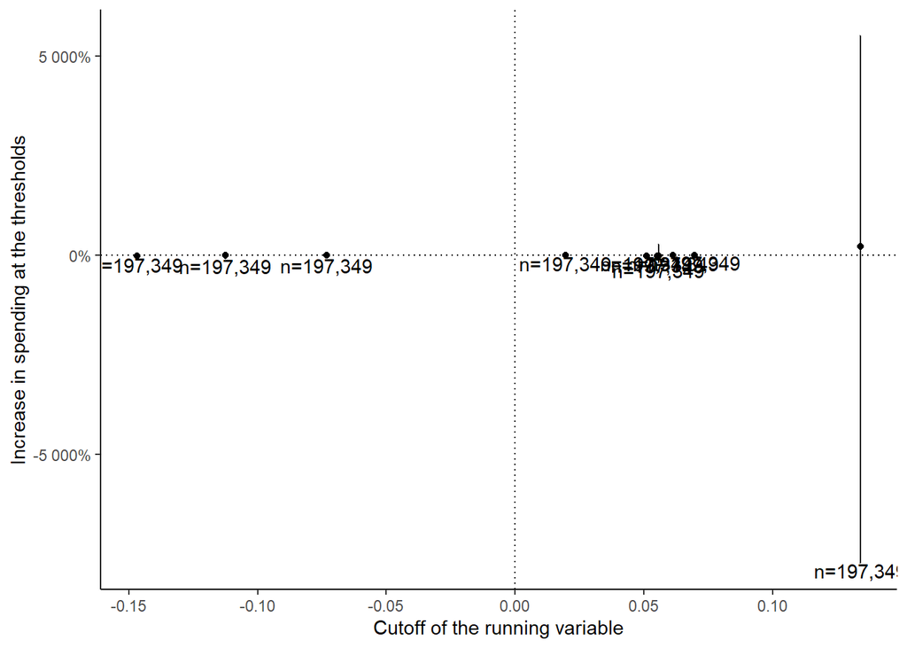

```r
df <- rdd_placebo %>%
  #tidyr::drop_na() %>%
  #filter(abs(ci_upper) < 100 | abs(ci_lower) < 100) %>%
  mutate(effective_n = paste0("n=", trimws(format(sum(obs_below, obs_above), big.mark = ",") ) ) ) # add big mark
ggplot2::ggplot(df) +
  geom_point(aes(x = placebo_c, y = point_estimate), size = 1.5, colour = ifelse(df$p <= 0.05, 2, 1)) +
  geom_errorbar(aes(x = placebo_c, ymin = ci_lower, ymax = ci_upper),
                colour = ifelse(df$p <= 0.05, 2, 1),
                linetype = ifelse(df$p <= 0.05, 2, 1)) +
  geom_text(aes(x = placebo_c, y = ci_lower, label = effective_n),
            colour = ifelse(df$p <= 0.05, 2, 1), vjust = 1) +
  geom_hline(aes(yintercept = 0), linetype = "dotted") +
  geom_vline(aes(xintercept = 0), linetype = "dotted") +
  scale_y_continuous(labels = scales::percent) +
  labs(x = "Cutoff of the running variable", y = y_lab_RDD)
```

```r
rm(df)
```

#### Sample split by `above_cutoff`

Based on main placebo “specification” (“second attempt”, regular distances within inter-quartile range), I split the sample into two by values of the “instrument” `above_cutoff`:

```r
# Above
df <- d_rdd_bivariate %>% filter(above_cutoff == 1)
rdd_placebo_split <-
  tibble(sample = "", placebo_c = "", point_estimate = "", se = "", se_robust = "",
         ci_lower = "", ci_upper = "", p = "", bw = "", obs_below = "", obs_above = "") %>%
  mutate(across(2:last_col(), as.numeric))
vector <- seq(from = 0.015, to = (0.18), by = 0.015) # Choose vector of arbitrary placebo cutoffs
rdd_placebo_above <- rdd_placebo_split
for (i in vector) {
  print(paste("Cutoff at:", i))
  rdd <- rdrobust::rdrobust(
    y = df$ln_gross_expenditure_pc,
    x = df$inhabs_rel_to_cutoff,
    c = i,
    fuzzy = df$total_seats,
    cluster = df$inhabitants_treshold_factor,
    covs = model.matrix( ~ df$inhabitants_treshold_factor + df$year + df$state)
  )
  #summary(rdd)
  rdd_placebo_above <- rdd_placebo_above %>%
    dplyr::add_row(
      sample = "above",
      placebo_c = i,
      point_estimate = rdd$coef[1],
      se = rdd$se[1],
      se_robust = rdd$se[3],
      ci_lower = rdd$ci[3,1],
      ci_upper = rdd$ci[3,2],
      p = rdd$pv[3],
      bw = rdd$bws[1,1],
      obs_below = rdd$N_h[1],
      obs_above = rdd$N_h[2]
  )
}
```

```
## [1] "Cutoff at: 0.015"
## [1] "Mass points detected in the running variable."
## [1] "Cutoff at: 0.03"
## [1] "Mass points detected in the running variable."
## [1] "Cutoff at: 0.045"
## [1] "Mass points detected in the running variable."
## [1] "Cutoff at: 0.06"
## [1] "Mass points detected in the running variable."
## [1] "Cutoff at: 0.075"
## [1] "Mass points detected in the running variable."
## [1] "Cutoff at: 0.09"
## [1] "Mass points detected in the running variable."
## [1] "Cutoff at: 0.105"
## [1] "Mass points detected in the running variable."
## [1] "Cutoff at: 0.12"
## [1] "Mass points detected in the running variable."
## [1] "Cutoff at: 0.135"
## [1] "Mass points detected in the running variable."
## [1] "Cutoff at: 0.15"
## [1] "Mass points detected in the running variable."
## [1] "Cutoff at: 0.165"
## [1] "Mass points detected in the running variable."
## [1] "Cutoff at: 0.18"
## [1] "Mass points detected in the running variable."
```

```r
# Below
df <- d_rdd_bivariate %>% filter(above_cutoff == 0)
vector <- seq(from = -0.18, to = -0.015, by = 0.015) # Choose vector of arbitrary placebo cutoffs
rdd_placebo_below <- rdd_placebo_split
for (i in vector) {
  print(paste("Cutoff at:", i))
  rdd <- rdrobust::rdrobust(
    y = df$ln_gross_expenditure_pc,
    x = df$inhabs_rel_to_cutoff,
    c = i,
    fuzzy = df$total_seats,
    cluster = df$inhabitants_treshold_factor,
    covs = model.matrix( ~ df$inhabitants_treshold_factor + df$year + df$state)
  )
  #summary(rdd)
  rdd_placebo_below <- rdd_placebo_below %>%
    dplyr::add_row(
      sample = "below",
      placebo_c = i,
      point_estimate = rdd$coef[1],
      se = rdd$se[1],
      se_robust = rdd$se[3],
      ci_lower = rdd$ci[3,1],
      ci_upper = rdd$ci[3,2],
      p = rdd$pv[3],
      bw = rdd$bws[1,1],
      obs_below = rdd$N_h[1],
      obs_above = rdd$N_h[2]
  )
}
```

```
## [1] "Cutoff at: -0.18"
## [1] "Mass points detected in the running variable."
## [1] "Cutoff at: -0.165"
## [1] "Mass points detected in the running variable."
## [1] "Cutoff at: -0.15"
## [1] "Mass points detected in the running variable."
## [1] "Cutoff at: -0.135"
## [1] "Mass points detected in the running variable."
## [1] "Cutoff at: -0.12"
## [1] "Mass points detected in the running variable."
## [1] "Cutoff at: -0.105"
## [1] "Mass points detected in the running variable."
## [1] "Cutoff at: -0.09"
## [1] "Mass points detected in the running variable."
## [1] "Cutoff at: -0.075"
## [1] "Mass points detected in the running variable."
## [1] "Cutoff at: -0.06"
## [1] "Mass points detected in the running variable."
## [1] "Cutoff at: -0.045"
## [1] "Mass points detected in the running variable."
## [1] "Cutoff at: -0.03"
## [1] "Mass points detected in the running variable."
## [1] "Cutoff at: -0.015"
## [1] "Mass points detected in the running variable."
```

```r
# Bind
rdd_placebo_split <-
  rbind(rdd_placebo_above, rdd_placebo_below) %>%
  drop_na() %>%
  arrange(placebo_c)

# Save & clean up
rm(df, rdd_placebo_above, rdd_placebo_below, vector)
save(rdd_placebo_split, file = "tables_robustness_checks/rdd_placebo_split.Rdata")
```

```r
load(file = "tables_robustness_checks/rdd_placebo_split.Rdata")
rdd_placebo_split
```

| sample | placebo_c | point_estimate | se | se_robust | ci_lower | ci_upper | p | bw | obs_below | obs_above |
| --- | --- | --- | --- | --- | --- | --- | --- | --- | --- | --- |
| below | -0.180 | 0.086570470 | 0.09867405 | 0.11085803 | -0.14965362 | 0.28490188 | 0.541857431 | 0.05081007 | 6242 | 7666 |
| below | -0.165 | -0.001086808 | 0.08755769 | 0.09712944 | -0.20774896 | 0.17299144 | 0.857997596 | 0.05700192 | 7739 | 8784 |
| below | -0.150 | 0.103558995 | 0.07556483 | 0.08602083 | -0.07811113 | 0.25908432 | 0.292838557 | 0.03191545 | 4912 | 4806 |
| below | -0.135 | 1.601996517 | 9.12647234 | 10.40563437 | -18.08492362 | 22.70441357 | 0.824336765 | 0.03380261 | 5086 | 5261 |
| below | -0.120 | -0.038006753 | 0.11512403 | 0.13053250 | -0.37739021 | 0.13428777 | 0.351752659 | 0.05854539 | 8951 | 9066 |
| below | -0.105 | -0.179821410 | 0.09556272 | 0.10835359 | -0.38680946 | 0.03792879 | 0.107415869 | 0.04137935 | 6301 | 6288 |
| below | -0.090 | 1.017791740 | 13.46866047 | 15.11772952 | -31.83741162 | 27.42299914 | 0.883920463 | 0.02639097 | 4110 | 3977 |
| below | -0.075 | -0.175085291 | 0.17504517 | 0.20113139 | -0.59860522 | 0.18981534 | 0.309521794 | 0.01989918 | 3007 | 3089 |
| below | -0.060 | -0.023913181 | 0.05929278 | 0.06525774 | -0.17898307 | 0.07682259 | 0.433776249 | 0.01479286 | 2386 | 2289 |
| below | -0.045 | 0.105930385 | 0.07258366 | 0.11393950 | 0.08154102 | 0.52817566 | 0.007459209 | 0.01625637 | 2485 | 2469 |

[output cut: 14 more lines]

Visualization of placebo cutoffs:

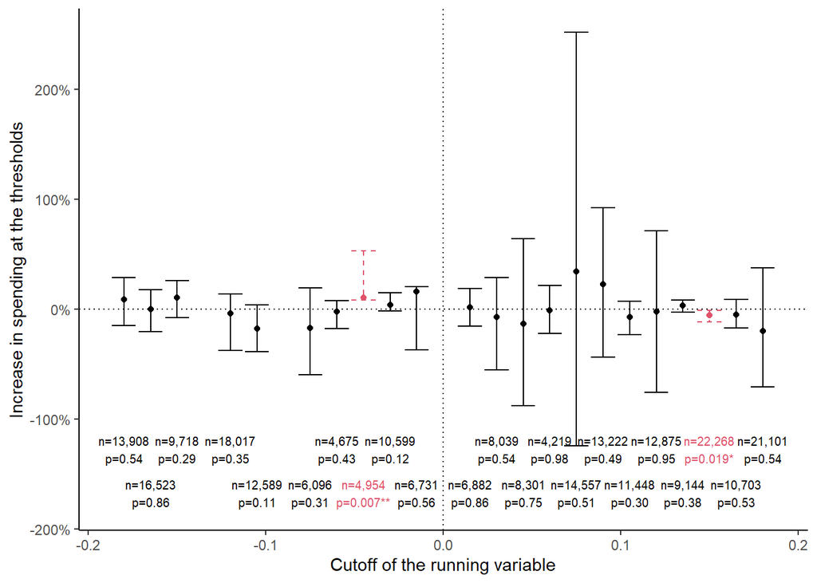

```r
df <- rdd_placebo_split %>%
  filter(abs(ci_upper) < 15 | abs(ci_lower) < 15) %>%
  rowwise() %>%
  mutate(note = paste0("n=",
                       trimws(format(sum(obs_below, obs_above), big.mark = ",") ), # add big mark
                       "\n",
                       p_value(p),
                       assign_stars(p) ) ) %>%
  ungroup()
even_number <- round((df$placebo_c*1000), 0) %% 2
ggplot2::ggplot(df) +
  geom_point(aes(x = placebo_c, y = point_estimate), size = 1.5, colour = ifelse(df$p <= 0.05, 2, 1)) +
  geom_errorbar(aes(x = placebo_c, ymin = ci_lower, ymax = ci_upper),
                colour = ifelse(df$p <= 0.05, 2, 1),
                linetype = ifelse(df$p <= 0.05, 2, 1)) +
  geom_text(aes(x = placebo_c,
                y = ifelse(even_number == 0, -1.4, -1.8),
                label = note),
            colour = ifelse(df$p <= 0.05, 2, 1),
            size = 2.7,
            vjust = 0) +
  geom_hline(aes(yintercept = 0), linetype = "dotted") +
  geom_vline(aes(xintercept = 0), linetype = "dotted") +
  scale_y_continuous(labels = scales::percent) +
  labs(x = "Cutoff of the running variable", y = y_lab_RDD)
```

```r
rm(df, even_number)
```

### Donut-hole RDD

#### Values of the running variable

```r
summary(d_rdd_bivariate$inhabs_rel_to_cutoff)
```

```
##     Min.  1st Qu.   Median     Mean  3rd Qu.     Max.
## -3.75787 -0.15036  0.01980 -0.02488  0.18565  0.86500
```

```r
quantile(d_rdd_bivariate$inhabs_rel_to_cutoff, c(0.45, 0.55))
```

```
##         45%         55%
## -0.01376092  0.05259245
```

```r
#donut <- seq(0.005, 0.03, 0.005)
#donut <- seq(0.0025, 0.02, 0.0025)
donut <- seq(0.0025, 0.0325, 0.0025)
```

```r
rdd_donut <-
  tibble(donut_radius = "", dropped_obs = "", point_estimate = "", se = "", se_robust = "",
         ci_lower = "", ci_upper = "", p = "",
         point_estimate_first_stage = "", ci_lower_first_stage = "", ci_upper_first_stage = "",
         bw = "", obs_below = "", obs_above = "") %>%
  mutate(across(everything(), as.numeric))
for (i in 1:length(donut)) {
  print(donut[i])
  print(paste("Number of dropped observations at the center:",
              d_rdd_bivariate %>% filter(abs(inhabs_rel_to_cutoff) <= donut[i]) %>% nrow(.)))
  df <- d_rdd_bivariate %>% filter(abs(inhabs_rel_to_cutoff) > donut[i])
  rdd <-
    rdrobust::rdrobust(
      y = df$ln_gross_expenditure_pc,
      x = df$inhabs_rel_to_cutoff,
      fuzzy = df$total_seats,
      cluster = df$inhabitants_treshold_factor,
      covs = model.matrix( ~ df$inhabitants_treshold_factor + df$year + df$state)
      )
  summary(rdd)
  rdd_donut <- rdd_donut %>%
    dplyr::add_row(
      donut_radius = donut[i],
      dropped_obs = d_rdd_bivariate %>% filter(abs(inhabs_rel_to_cutoff) <= donut[i]) %>% nrow(.),
      point_estimate = rdd$coef[1],
      se = rdd$se[1],
      se_robust = rdd$se[3],
      ci_lower = rdd$ci[3,1],
      ci_upper = rdd$ci[3,2],
      p = rdd$pv[3],
      point_estimate_first_stage = rdd$tau_T[1],
      ci_lower_first_stage = rdd$ci_T[3,1],
      ci_upper_first_stage = rdd$ci_T[3,2],
      bw = rdd$bws[1,1],
      obs_below = rdd$N_h[1],
      obs_above = rdd$N_h[2]
  )
  save(rdd, file = paste0("tables_robustness_checks/rdd_donut_rdrobust", i, ".RData"))
  df <- df %>% filter(closest <= 0.1)
  rdd <- fixest::feols(ln_gross_expenditure_pc ~
                         1  | # controls
                         inhabitants_treshold_factor + year + ags | # fixed-effect controls
                         # First stage regression:
                         inhabs_rel_to_cutoff*total_seats ~ # Instrument our standard RDD...
                         inhabs_rel_to_cutoff*above_cutoff, # ... with being above the cutoff
                       vcov = "threeway",
                       data = df)
  summary(rdd)
  save(rdd, file = paste0("tables_robustness_checks/rdd_donut_iv", i, ".RData"))
}
```

```
## [1] 0.0025
## [1] "Number of dropped observations at the center: 857"
## [1] "Mass points detected in the running variable."
## Covariate-adjusted Fuzzy RD estimates using local polynomial regression.
##
## Number of Obs.               102761
## BW type                       mserd
## Kernel                   Triangular
## VCE method                       NN
##
## Number of Obs.                48215        54546
## Eff. Number of Obs.           16967        17159
## Order est. (p)                    1            1
## Order bias  (q)                   2            2
## BW est. (h)                   0.114        0.114
## BW bias (b)                   0.404        0.404
## rho (h/b)                     0.283        0.283
## Unique Obs.                    3685         4551
##
## First-stage estimates.
##
## =============================================================================
##         Method     Coef. Std. Err.         z     P>|z|      [ 95% C.I. ]
## =============================================================================
##   Conventional     1.769     0.091    19.336     0.000     [1.590 , 1.948]
##         Robust         -         -    18.572     0.000     [1.560 , 1.928]
## =============================================================================
##
## Treatment effect estimates.
##
## =============================================================================
##         Method     Coef. Std. Err.         z     P>|z|      [ 95% C.I. ]
## =============================================================================
##   Conventional     0.016     0.006     2.691     0.007     [0.004 , 0.027]
##         Robust         -         -     2.606     0.009     [0.004 , 0.028]
## =============================================================================
## [1] 0.005
## [1] "Number of dropped observations at the center: 1560"
## [1] "Mass points detected in the running variable."
## Covariate-adjusted Fuzzy RD estimates using local polynomial regression.
```

[output cut: 413 more lines]

```
## =============================================================================
##         Method     Coef. Std. Err.         z     P>|z|      [ 95% C.I. ]
## =============================================================================
##   Conventional     2.196     0.180    12.227     0.000     [1.844 , 2.548]
##         Robust         -         -    11.266     0.000     [1.781 , 2.532]
## =============================================================================
##
## Treatment effect estimates.
##
## =============================================================================
##         Method     Coef. Std. Err.         z     P>|z|      [ 95% C.I. ]
## =============================================================================
##   Conventional     0.009     0.007     1.159     0.247    [-0.006 , 0.023]
##         Robust         -         -     1.152     0.249    [-0.006 , 0.025]
## =============================================================================
```

```r
rdd_donut <- rdd_donut %>%
  drop_na() %>%
  mutate(share_dropped = dropped_obs / nrow(d_rdd_bivariate), .after = dropped_obs)
save(rdd_donut, file = "tables_robustness_checks/rdd_donut.Rdata")
rm(df)
```

```r
for (i in 1:length(donut)) {
  print(donut[i])
  print(paste("Number of dropped observations at the center:",
              d_rdd_bivariate %>% filter(abs(inhabs_rel_to_cutoff) <= donut[i]) %>% nrow(.)))
  df <- d_rdd_bivariate %>% filter(abs(inhabs_rel_to_cutoff) > donut[i])
  load(file = paste0("tables_robustness_checks/rdd_donut_rdrobust", i, ".RData"))
  #summary(rdd)
  load(file = paste0("tables_robustness_checks/rdd_donut_iv", i, ".RData"))
  #summary(rdd)
}
```

```
## [1] 0.0025
## [1] "Number of dropped observations at the center: 857"
## [1] 0.005
## [1] "Number of dropped observations at the center: 1560"
## [1] 0.0075
## [1] "Number of dropped observations at the center: 2316"
## [1] 0.01
## [1] "Number of dropped observations at the center: 3017"
## [1] 0.0125
## [1] "Number of dropped observations at the center: 3894"
## [1] 0.015
## [1] "Number of dropped observations at the center: 4675"
## [1] 0.0175
## [1] "Number of dropped observations at the center: 5460"
## [1] 0.02
## [1] "Number of dropped observations at the center: 6214"
## [1] 0.0225
## [1] "Number of dropped observations at the center: 6874"
## [1] 0.025
## [1] "Number of dropped observations at the center: 7562"
## [1] 0.0275
## [1] "Number of dropped observations at the center: 8271"
## [1] 0.03
## [1] "Number of dropped observations at the center: 9028"
## [1] 0.0325
## [1] "Number of dropped observations at the center: 9870"
```

```r
load(file = "tables_robustness_checks/rdd_donut.Rdata")
rdd_donut
```

| donut_radius | dropped_obs | share_dropped | point_estimate | se | se_robust | ci_lower | ci_upper | p | point_estimate_first_stage | ci_lower_first_stage | ci_upper_first_stage | bw | obs_below | obs_above |
| --- | --- | --- | --- | --- | --- | --- | --- | --- | --- | --- | --- | --- | --- | --- |
| 0.0025 | 857 | 0.008270764 | 0.015725816 | 0.005844189 | 0.006101639 | 0.0039422719 | 0.02786026 | 0.009158921 | 1.768803 | 1.5599737 | 1.928080 | 0.11429830 | 16967 | 17159 |
| 0.0050 | 1560 | 0.015055299 | 0.011397649 | 0.005054297 | 0.005336912 | 0.0007938229 | 0.02171413 | 0.034969969 | 1.833200 | 1.6178431 | 2.003980 | 0.11535611 | 16777 | 16854 |
| 0.0075 | 2316 | 0.022351329 | 0.006240364 | 0.013027944 | 0.013758252 | -0.0196423955 | 0.03428896 | 0.594530032 | 1.632357 | 1.2427553 | 1.865792 | 0.05145073 | 6613 | 6834 |
| 0.0100 | 3017 | 0.029116563 | 0.013574953 | 0.017007338 | 0.017636146 | -0.0185613450 | 0.05057108 | 0.364140550 | 1.539558 | 1.1179838 | 1.800483 | 0.04873218 | 5760 | 6039 |
| 0.0125 | 3894 | 0.037580343 | 0.017160322 | 0.019803699 | 0.020659842 | -0.0195290802 | 0.06145601 | 0.310250610 | 1.507390 | 0.9559419 | 1.873040 | 0.04991880 | 5515 | 5799 |
| 0.0150 | 4675 | 0.045117644 | 0.027367617 | 0.014038362 | 0.015152003 | 0.0034207099 | 0.06281547 | 0.028835836 | 1.630027 | 1.2805542 | 1.769545 | 0.05453428 | 5900 | 6174 |
| 0.0175 | 5460 | 0.052693547 | 0.027100788 | 0.014607522 | 0.015513135 | 0.0043633311 | 0.06517370 | 0.025011124 | 1.382916 | 0.9691873 | 1.554980 | 0.06003595 | 6291 | 6623 |
| 0.0200 | 6214 | 0.059970275 | 0.033243976 | 0.011917811 | 0.012548014 | 0.0156221124 | 0.06480942 | 0.001350855 | 1.712751 | 1.0993348 | 2.086207 | 0.06761592 | 7193 | 7369 |
| 0.0225 | 6874 | 0.066339825 | 0.026638072 | 0.010747783 | 0.011403427 | 0.0094267152 | 0.05412733 | 0.005326084 | 1.883728 | 1.2298160 | 2.324216 | 0.07050699 | 7350 | 7628 |
| 0.0250 | 7562 | 0.072979598 | 0.031207218 | 0.010039684 | 0.010657915 | 0.0132676091 | 0.05504587 | 0.001351452 | 1.989962 | 1.5630147 | 2.290967 | 0.07879441 | 8225 | 8361 |

[output cut: 3 more lines]

```r
rm(donut)
```

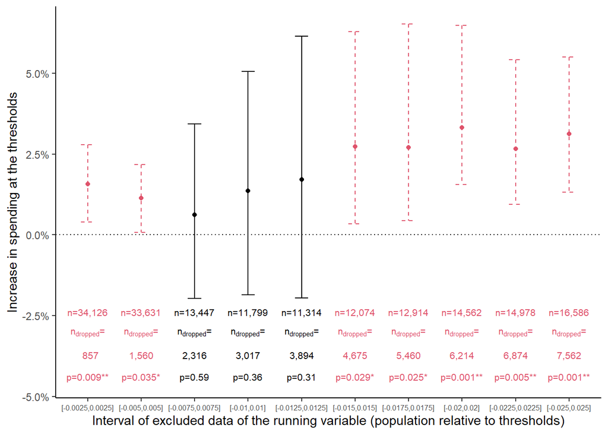

```r
text_size <- 2.75
df <- rdd_donut %>%
  filter(donut_radius <= 0.025) %>%
  mutate(donut_radius = paste0("[-", donut_radius, ",", donut_radius, "]")) %>%
  rowwise() %>%
  mutate(note = paste0("n=",
                       trimws(format(sum(obs_below, obs_above), big.mark = ",") ) # add big mark
                       ),
         note2 = paste0(p_value(p), assign_stars(p))) %>%
  ungroup()
ggplot2::ggplot(data = df, aes(x = donut_radius, y = point_estimate)) +
  geom_point(size = 1.5, color = ifelse(df$p <= 0.05, 2, 1)) +
  geom_errorbar(aes(ymin = ci_lower, ymax = ci_upper),
                color = ifelse(df$p <= 0.05, 2, 1),
                linetype = ifelse(df$p <= 0.05, 2, 1),
                width = 0.25) +
  geom_text(aes(x = donut_radius, y = -0.025, label = note),
            colour = ifelse(df$p <= 0.05, 2, 1), size = text_size,
            vjust = 0) +
  annotate(geom = "text", x = df$donut_radius, y = -0.03166667,
           label = latex2exp::TeX("$n_{dropped}$="),
            colour = ifelse(df$p <= 0.05, 2, 1), size = text_size,
           vjust = 0) +# Doesn't work with geom_text, apparently
  geom_text(aes(x = donut_radius, y = -0.03833333,
                label = format(dropped_obs, big.mark = ",")),
            colour = ifelse(df$p <= 0.05, 2, 1), size = text_size,
            vjust = 0) +
  geom_text(aes(x = donut_radius, y = -0.045, label = note2),
            colour = ifelse(df$p <= 0.05, 2, 1), size = text_size,
            vjust = 0) +
  geom_hline(aes(yintercept = 0), linetype = "dotted") +
  scale_y_continuous(labels = scales::percent) +
  labs(x = "Interval of excluded data of the running variable (population relative to thresholds)",
       y = y_lab_RDD) +
  theme(axis.text.x = element_text(size = 6))
```

```r
ggsave(filename = "plots/rdd_donut.pdf", width = 7, height = 7*9/16)
rm(df, text_size)
```

Plotting only “donuts” close to the threshold (i. e. running variable $|X| \leq 0.025$) as this would be where sorting would most likely occur.

Seven out of ten regressions are positively significant…

#### (Percentage) windows of the running variable

```r
donut_window <- seq(0.01, 0.09, 0.01)
```

```r
rdd_donut_window <-
  tibble(donut_window = "", dropped_obs = "", point_estimate = "", se = "", se_robust = "",
         ci_lower = "", ci_upper = "", p = "",
         point_estimate_first_stage = "", ci_lower_first_stage = "", ci_upper_first_stage = "",
         bw = "", obs_below = "", obs_above = "") %>%
  mutate(across(everything(), as.numeric))
for (i in 1:length(donut_window)) {
  print(donut_window[i])
  print(paste("Number of dropped observations at the center:",
              d_rdd_bivariate %>% filter(closest <= donut_window[i]) %>% nrow(.)))
  df <- d_rdd_bivariate %>% filter(closest > donut_window[i])
  rdd <-
    rdrobust::rdrobust(
      y = df$ln_gross_expenditure_pc,
      x = df$inhabs_rel_to_cutoff,
      fuzzy = df$total_seats,
      cluster = df$inhabitants_treshold_factor,
      covs = model.matrix( ~ df$inhabitants_treshold_factor + df$year + df$state)
      )
  summary(rdd)
  do <- d_rdd_bivariate %>% filter(closest <= donut_window[i]) %>% nrow(.)
  rdd_donut_window <- rdd_donut_window %>%
    dplyr::add_row(
      donut_window = donut_window[i],
      dropped_obs = do,
      point_estimate = rdd$coef[1],
      se = rdd$se[1],
      se_robust = rdd$se[3],
      ci_lower = rdd$ci[3,1],
      ci_upper = rdd$ci[3,2],
      p = rdd$pv[3],
      point_estimate_first_stage = rdd$tau_T[1],
      ci_lower_first_stage = rdd$ci_T[3,1],
      ci_upper_first_stage = rdd$ci_T[3,2],
      bw = rdd$bws[1,1],
      obs_below = rdd$N_h[1],
      obs_above = rdd$N_h[2]
  )
  save(rdd, file = paste0("tables_robustness_checks/rdd_donut_window_rdrobust", i, ".RData"))
  df <- df %>% filter(closest <= 0.1)
  rdd <- fixest::feols(ln_gross_expenditure_pc ~
                         1  | # controls
                         inhabitants_treshold_factor + year + ags | # fixed-effect controls
                         # First stage regression:
                         inhabs_rel_to_cutoff*total_seats ~ # Instrument our standard RDD...
                         inhabs_rel_to_cutoff*above_cutoff, # ... with being above the cutoff
                       vcov = "threeway",
                       data = df)
  summary(rdd)
  save(rdd, file = paste0("tables_robustness_checks/rdd_donut_window_iv", i, ".RData"))
}
```

```
## [1] 0.01
## [1] "Number of dropped observations at the center: 1036"
## [1] "Mass points detected in the running variable."
## Covariate-adjusted Fuzzy RD estimates using local polynomial regression.
##
## Number of Obs.               102582
## BW type                       mserd
## Kernel                   Triangular
## VCE method                       NN
##
## Number of Obs.                48138        54444
## Eff. Number of Obs.           20309        20583
## Order est. (p)                    1            1
## Order bias  (q)                   2            2
## BW est. (h)                   0.137        0.137
## BW bias (b)                   0.485        0.485
## rho (h/b)                     0.283        0.283
## Unique Obs.                    3678         4544
##
## First-stage estimates.
##
## =============================================================================
##         Method     Coef. Std. Err.         z     P>|z|      [ 95% C.I. ]
## =============================================================================
##   Conventional     1.921     0.090    21.287     0.000     [1.744 , 2.098]
##         Robust         -         -    20.534     0.000     [1.718 , 2.081]
## =============================================================================
##
## Treatment effect estimates.
##
## =============================================================================
##         Method     Coef. Std. Err.         z     P>|z|      [ 95% C.I. ]
## =============================================================================
##   Conventional     0.011     0.004     2.565     0.010     [0.003 , 0.020]
##         Robust         -         -     2.245     0.025     [0.001 , 0.019]
## =============================================================================
## [1] 0.02
## [1] "Number of dropped observations at the center: 2072"
## [1] "Mass points detected in the running variable."
## Covariate-adjusted Fuzzy RD estimates using local polynomial regression.
```

[output cut: 269 more lines]

```
## =============================================================================
##         Method     Coef. Std. Err.         z     P>|z|      [ 95% C.I. ]
## =============================================================================
##   Conventional     1.817     0.199     9.136     0.000     [1.427 , 2.207]
##         Robust         -         -     8.200     0.000     [1.311 , 2.135]
## =============================================================================
##
## Treatment effect estimates.
##
## =============================================================================
##         Method     Coef. Std. Err.         z     P>|z|      [ 95% C.I. ]
## =============================================================================
##   Conventional     0.020     0.015     1.263     0.207    [-0.011 , 0.050]
##         Robust         -         -     1.399     0.162    [-0.009 , 0.057]
## =============================================================================
```

```r
rdd_donut_window <- rdd_donut_window %>%
  drop_na() %>%
  mutate(share_dropped = dropped_obs / nrow(d_rdd_bivariate), .after = dropped_obs)
save(rdd_donut_window, file = "tables_robustness_checks/rdd_donut_window.Rdata")
rm(df, do)
```

```r
for (i in 1:length(donut_window)) {
  print(donut_window[i])
  print(paste("Number of dropped observations at the center:",
              d_rdd_bivariate %>% filter(closest <= donut_window[i]) %>% nrow(.)))
  df <- d_rdd_bivariate %>% filter(closest > donut_window[i])
  load(file = paste0("tables_robustness_checks/rdd_donut_window_rdrobust", i, ".RData"))
  #summary(rdd)
  load(file = paste0("tables_robustness_checks/rdd_donut_window_iv", i, ".RData"))
  #summary(rdd)
}
```

```
## [1] 0.01
## [1] "Number of dropped observations at the center: 1036"
## [1] 0.02
## [1] "Number of dropped observations at the center: 2072"
## [1] 0.03
## [1] "Number of dropped observations at the center: 3108"
## [1] 0.04
## [1] "Number of dropped observations at the center: 4144"
## [1] 0.05
## [1] "Number of dropped observations at the center: 5180"
## [1] 0.06
## [1] "Number of dropped observations at the center: 6217"
## [1] 0.07
## [1] "Number of dropped observations at the center: 7253"
## [1] 0.08
## [1] "Number of dropped observations at the center: 8289"
## [1] 0.09
## [1] "Number of dropped observations at the center: 9325"
```

```r
load(file = "tables_robustness_checks/rdd_donut_window.Rdata")
rdd_donut_window
```

| donut_window | dropped_obs | share_dropped | point_estimate | se | se_robust | ci_lower | ci_upper | p | point_estimate_first_stage | ci_lower_first_stage | ci_upper_first_stage | bw | obs_below | obs_above |
| --- | --- | --- | --- | --- | --- | --- | --- | --- | --- | --- | --- | --- | --- | --- |
| 0.01 | 1036 | 0.009998263 | 0.011321831 | 0.004414648 | 0.004620024 | 0.001316499 | 0.01942666 | 0.024773335 | 1.921020 | 1.7183238 | 2.080973 | 0.13702020 | 20309 | 20583 |
| 0.02 | 2072 | 0.019996526 | 0.002903219 | 0.012787336 | 0.013454333 | -0.022776844 | 0.02996317 | 0.789420079 | 1.576379 | 1.1668733 | 1.828791 | 0.04889300 | 6167 | 6673 |
| 0.03 | 3108 | 0.029994789 | 0.009467181 | 0.016789979 | 0.017428515 | -0.022724251 | 0.04559427 | 0.511753797 | 1.614789 | 1.1859695 | 1.885979 | 0.04774477 | 5544 | 5898 |
| 0.04 | 4144 | 0.039993051 | 0.032596176 | 0.022597290 | 0.023476648 | -0.006850538 | 0.08517623 | 0.095283619 | 1.396099 | 0.9515561 | 1.632497 | 0.05270968 | 5928 | 6169 |
| 0.05 | 5180 | 0.049991314 | 0.034823997 | 0.014073368 | 0.015178002 | 0.012778174 | 0.07227485 | 0.005081022 | 1.578375 | 1.1511909 | 1.776465 | 0.05526707 | 5716 | 6023 |
| 0.06 | 6217 | 0.059999228 | 0.033182178 | 0.011910341 | 0.012540065 | 0.015542598 | 0.06469875 | 0.001377144 | 1.715956 | 1.1026297 | 2.089752 | 0.06767560 | 7198 | 7478 |
| 0.07 | 7253 | 0.069997491 | 0.034108124 | 0.011366934 | 0.012006667 | 0.014359464 | 0.06142473 | 0.001599919 | 1.884747 | 1.3715788 | 2.243370 | 0.07595296 | 7976 | 8146 |
| 0.08 | 8289 | 0.079995754 | 0.018995754 | 0.007632723 | 0.008129094 | 0.003970159 | 0.03583562 | 0.014351101 | 2.276296 | 2.0044618 | 2.522647 | 0.10051546 | 11217 | 11257 |
| 0.09 | 9325 | 0.089994016 | 0.019569241 | 0.015492617 | 0.016827302 | -0.009441164 | 0.05652065 | 0.161842453 | 1.816868 | 1.3110176 | 2.134565 | 0.08045696 | 7576 | 7793 |

```r
rm(donut_window)
```

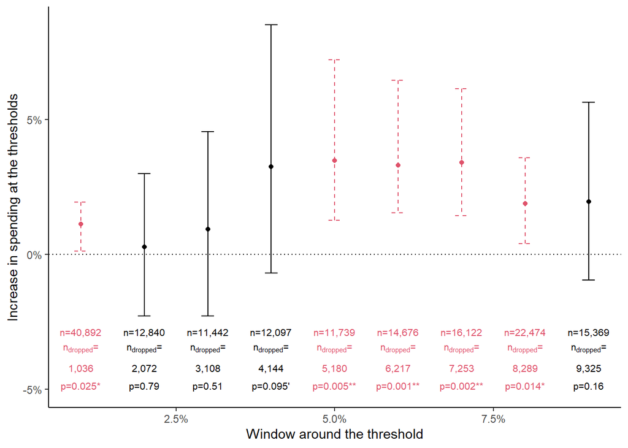

```r
text_size <- 2.75
df <- rdd_donut_window %>%
  #filter(donut_window <= 0.025) %>%
  #mutate(donut_radius = paste0("[-", donut_radius, ",", donut_radius, "]")) %>%
  rowwise() %>%
  mutate(note = paste0("n=",
                       trimws(format(sum(obs_below, obs_above), big.mark = ",") ) # add big mark
                       ),
         note2 = paste0(p_value(p), assign_stars(p))) %>%
  ungroup()
ggplot2::ggplot(data = df, aes(x = donut_window, y = point_estimate)) +
  geom_point(size = 1.5, color = ifelse(df$p <= 0.05, 2, 1)) +
  geom_errorbar(aes(ymin = ci_lower, ymax = ci_upper),
                color = ifelse(df$p <= 0.05, 2, 1),
                linetype = ifelse(df$p <= 0.05, 2, 1),
                width = 0.002) +
  geom_text(aes(x = donut_window, y = -0.03, label = note),
            colour = ifelse(df$p <= 0.05, 2, 1), size = text_size,
            vjust = 0) +
  annotate(geom = "text", x = df$donut_window, y = -0.03666667,
           label = latex2exp::TeX("$n_{dropped}$="),
            colour = ifelse(df$p <= 0.05, 2, 1), size = text_size,
           vjust = 0) +# Doesn't work with geom_text, apparently
  geom_text(aes(x = donut_window, y = -0.04333333,
                label = format(dropped_obs, big.mark = ",")),
            colour = ifelse(df$p <= 0.05, 2, 1), size = text_size,
            vjust = 0) +
  geom_text(aes(x = donut_window, y = -0.05, label = note2),
            colour = ifelse(df$p <= 0.05, 2, 1), size = text_size,
            vjust = 0) +
  geom_hline(aes(yintercept = 0), linetype = "dotted") +
  scale_x_continuous(labels = scales::percent) +
  scale_y_continuous(labels = scales::percent) +
  labs(x = "Window around the threshold",
       y = y_lab_RDD)
```

```r
ggsave(filename = "plots/rdd_donut_window.pdf", width = 7, height = 7*9/16)
rm(df, text_size)
```

### Mass points

Investigating and counting mass points:

```r
sum(!is.na(data$inhabs_rel_to_cutoff)) # Number of valid observations of running variable
```

```
## [1] 191249
```

```r
length(unique(data$inhabs_rel_to_cutoff)) # Number of unique values of running variable
```

```
## [1] 10887
```

```r
sum(!is.na(data$inhabs_rel_to_cutoff)) / length(unique(data$inhabs_rel_to_cutoff)) # 18 observations per value
```

```
## [1] 17.56673
```

#### Clustering at discrete values

```r
rdd <-
  rdrobust::rdrobust(
    y = d_rdd_bivariate$ln_gross_expenditure_pc,
    x = d_rdd_bivariate$inhabs_rel_to_cutoff,
    fuzzy = d_rdd_bivariate$total_seats,
    cluster = d_rdd_bivariate$inhabs_rel_to_cutoff,
    covs = model.matrix( ~ d_rdd_bivariate$inhabitants_treshold_factor + d_rdd_bivariate$year + d_rdd_bivariate$state)
  )
```

```
## [1] "Mass points detected in the running variable."
```

```r
summary(rdd)
```

```
## Covariate-adjusted Fuzzy RD estimates using local polynomial regression.
##
## Number of Obs.               103618
## BW type                       mserd
## Kernel                   Triangular
## VCE method                       NN
##
## Number of Obs.                48578        55040
## Eff. Number of Obs.            3340         3783
## Order est. (p)                    1            1
## Order bias  (q)                   2            2
## BW est. (h)                   0.024        0.024
## BW bias (b)                   0.079        0.079
## rho (h/b)                     0.300        0.300
## Unique Obs.                    3715         4582
##
## First-stage estimates.
##
## =============================================================================
##         Method     Coef. Std. Err.         z     P>|z|      [ 95% C.I. ]
## =============================================================================
##   Conventional     1.084     0.035    31.154     0.000     [1.016 , 1.152]
##         Robust         -         -    29.651     0.000     [0.993 , 1.133]
## =============================================================================
##
## Treatment effect estimates.
##
## =============================================================================
##         Method     Coef. Std. Err.         z     P>|z|      [ 95% C.I. ]
## =============================================================================
##   Conventional     0.009     0.002     4.396     0.000     [0.005 , 0.013]
##         Robust         -         -     3.945     0.000     [0.004 , 0.013]
## =============================================================================
```

```r
df <- d_rdd_bivariate %>%
  filter(closest <= 0.1) # Choose bandwidth window -- similar to Höhmann (2017)
# only one FE
rdd <- fixest::feols(
  ln_gross_expenditure_pc ~
    1  | # controls
    inhabitants_treshold_factor | # fixed-effect controls
    # First stage regression:
    inhabs_rel_to_cutoff * total_seats ~ # Instrument our standard RDD...
    inhabs_rel_to_cutoff * above_cutoff, # ... with being above the cutoff
  cluster = c("inhabitants_treshold_factor", "inhabs_rel_to_cutoff"),
  data = df
)
summary(rdd)
```

```
## TSLS estimation, Dep. Var.: ln_gross_expenditure_pc, Endo.: inhabs_rel_to_cutoff, total_seats, inhabs_rel_to_cutoff:total_seats, Instr.: inhabs_rel_to_cutoff, above_cutoff, inhabs_rel_to_cutoff:above_cutoff
## Second stage: Dep. Var.: ln_gross_expenditure_pc
## Observations: 10,361
## Fixed-effects: inhabitants_treshold_factor: 29
## Standard-errors: Clustered (inhabitants_treshold_factor & inhabs_rel_to_cutoff)
##                                       Estimate Std. Error   t value Pr(>|t|)
## fit_inhabs_rel_to_cutoff              7.768776  12.961137  0.599390  0.55373
## fit_total_seats                       0.012480   0.027148  0.459702  0.64928
## fit_inhabs_rel_to_cutoff:total_seats -0.464858   0.779612 -0.596269  0.55579
## ---
## Signif. codes:  0 '***' 0.001 '**' 0.01 '*' 0.05 '.' 0.1 ' ' 1
## RMSE: 0.340424     Adj. R2:  0.231281
##                  Within R2: -0.053288
## F-test (1st stage), inhabs_rel_to_cutoff            : stat =      1.112e+33, p < 2.2e-16, on 3 and 10,357 DoF.
## F-test (1st stage), total_seats                     : stat =    435.9      , p < 2.2e-16, on 3 and 10,357 DoF.
## F-test (1st stage), inhabs_rel_to_cutoff:total_seats: stat = 14,512.1      , p < 2.2e-16, on 3 and 10,357 DoF.
##                                           Wu-Hausman: stat =     NA        , p = NA     , on 3 and 10,326 DoF.
```

```r
# three FE
rdd <- fixest::feols(
  ln_gross_expenditure_pc ~
    1  | # controls
    inhabitants_treshold_factor + year + ags | # fixed-effect controls
    # First stage regression:
    inhabs_rel_to_cutoff * total_seats ~ # Instrument our standard RDD...
    inhabs_rel_to_cutoff * above_cutoff, # ... with being above the cutoff
  cluster = c("inhabitants_treshold_factor", "year", "ags", "inhabs_rel_to_cutoff"),
  data = df
)
summary(rdd)
```

```
## TSLS estimation, Dep. Var.: ln_gross_expenditure_pc, Endo.: inhabs_rel_to_cutoff, total_seats, inhabs_rel_to_cutoff:total_seats, Instr.: inhabs_rel_to_cutoff, above_cutoff, inhabs_rel_to_cutoff:above_cutoff
## Second stage: Dep. Var.: ln_gross_expenditure_pc
## Observations: 10,361
## Fixed-effects: inhabitants_treshold_factor: 29,  year: 13,  ags: 1,816
## Standard-errors: Clustered (inhabitants_treshold_factor & year & ags & inhabs_rel_to_cutoff)
##                                       Estimate Std. Error   t value Pr(>|t|)
## fit_inhabs_rel_to_cutoff              4.844674   7.346193  0.659481  0.52204
## fit_total_seats                      -0.017580   0.014858 -1.183196  0.25964
## fit_inhabs_rel_to_cutoff:total_seats -0.207506   0.451358 -0.459736  0.65392
## ---
## Signif. codes:  0 '***' 0.001 '**' 0.01 '*' 0.05 '.' 0.1 ' ' 1
## RMSE: 0.17718     Adj. R2:  0.747016
##                 Within R2: -0.01326
## F-test (1st stage), inhabs_rel_to_cutoff            : stat =      3.153e+33, p < 2.2e-16, on 3 and 10,357 DoF.
## F-test (1st stage), total_seats                     : stat =  1,083.1      , p < 2.2e-16, on 3 and 10,357 DoF.
## F-test (1st stage), inhabs_rel_to_cutoff:total_seats: stat = 15,522.1      , p < 2.2e-16, on 3 and 10,357 DoF.
##                                           Wu-Hausman: stat =     NA        , p = NA     , on 3 and 8,499 DoF.
```

```r
rm(df, rdd)
```

IV approach does not alter the conclusions significantly but the `rdrobust` one does… Note that this approach is not statistically sound (see next subsection and its paper).

#### `RDHonest` package

Based on Kolesár & Rothe (2018):

```r
# Sharp (intention to treat)
RDHonest::RDHonest(
  formula = ln_gross_expenditure_pc ~ inhabs_rel_to_cutoff,
  data = d_rdd_bivariate#,
  #clusterid = model.matrix( ~  inhabitants_treshold_factor) # No idea how to correctly specify the clusterid variable
)
```

```
## Using Armstong & Kolesar (2020) ROT for smoothness constant M
```

```
## Call:
##
## RDHonest::RDHonest(formula = ln_gross_expenditure_pc ~ inhabs_rel_to_cutoff,
##     data = d_rdd_bivariate)
##
##
## Estimates (using Holder class):
##           Parameter    Estimate Std. Error Maximum Bias
##  Sharp RD Parameter -0.03129253 0.01073617  0.006486665
##          Confidence Interval
##  (-0.05565359, -0.006931465)
##
## Onesided CIs:  (-Inf, -0.007146438), (-0.05543862, Inf)
## Bandwidth: 0.05928715, Kernel: triangular
## Number of effective observations: 15124.38
## Maximal leverage for sharp RD Parameter: 0.0004790161
## Smoothness constant M: 18.67969
```

```r
# Fuzzy
# RDHonest::RDHonest(
#   formula = ln_gross_expenditure_pc ~ inhabs_rel_to_cutoff + total_seats,
#   data = d_rdd_bivariate
# )
```

The results from the sharp `RDHonest` are interesting in that the parameter is significant. However, the estimation is not clustered at the respective thresholds, presumable invalidating the result.

For the fuzzy case, I do not know how to run it. According to the [`RDhonest` vignette](https://github.com/kolesarm/RDHonest/blob/master/vignettes/RDHonest.Rmd), one needs a function called `FRDData`, which is, however, apparently not part of the package.

# Concluding Remarks

For references, see the paper.

```r
Sys.time() - time
```

```
## Time difference of 1.141457 hours
```